# wrangle_act

## Gather the data

```python
import pandas as pd
import numpy as np
import json
```

```python
# Read the csv file
df_twitter = pd.read_csv('twitter-archive-enhanced.csv')
df_twitter.head()
```

|  | tweet_id | in_reply_to_status_id | in_reply_to_user_id | timestamp | source | text | retweeted_status_id | retweeted_status_user_id | retweeted_status_timestamp | expanded_urls | rating_numerator | rating_denominator | name | doggo | floofer | pupper | puppo |
| --- | --- | --- | --- | --- | --- | --- | --- | --- | --- | --- | --- | --- | --- | --- | --- | --- | --- |
| 0 | 892420643555336193 | NaN | NaN | 2017-08-01 16:23:56 +0000 | <a href="http://twitter.com/download/iphone" r... | This is Phineas. He's a mystical boy. Only eve... | NaN | NaN | NaN | https://twitter.com/dog_rates/status/892420643... | 13 | 10 | Phineas | None | None | None | None |
| 1 | 892177421306343426 | NaN | NaN | 2017-08-01 00:17:27 +0000 | <a href="http://twitter.com/download/iphone" r... | This is Tilly. She's just checking pup on you.... | NaN | NaN | NaN | https://twitter.com/dog_rates/status/892177421... | 13 | 10 | Tilly | None | None | None | None |
| 2 | 891815181378084864 | NaN | NaN | 2017-07-31 00:18:03 +0000 | <a href="http://twitter.com/download/iphone" r... | This is Archie. He is a rare Norwegian Pouncin... | NaN | NaN | NaN | https://twitter.com/dog_rates/status/891815181... | 12 | 10 | Archie | None | None | None | None |
| 3 | 891689557279858688 | NaN | NaN | 2017-07-30 15:58:51 +0000 | <a href="http://twitter.com/download/iphone" r... | This is Darla. She commenced a snooze mid meal... | NaN | NaN | NaN | https://twitter.com/dog_rates/status/891689557... | 13 | 10 | Darla | None | None | None | None |
| 4 | 891327558926688256 | NaN | NaN | 2017-07-29 16:00:24 +0000 | <a href="http://twitter.com/download/iphone" r... | This is Franklin. He would like you to stop ca... | NaN | NaN | NaN | https://twitter.com/dog_rates/status/891327558... | 12 | 10 | Franklin | None | None | None | None |

```python
#Upload image prediction file from Requests library and from
#URL: https://d17h27t6h515a5.cloudfront.net/topher/2017/August/599fd2ad_image-predictions/image-predictions.tsv
df_image_predict = pd.read_csv('image-predictions.tsv', sep = '\t')
df_image_predict.head()
```

|  | tweet_id | jpg_url | img_num | p1 | p1_conf | p1_dog | p2 | p2_conf | p2_dog | p3 | p3_conf | p3_dog |
| --- | --- | --- | --- | --- | --- | --- | --- | --- | --- | --- | --- | --- |
| 0 | 666020888022790149 | https://pbs.twimg.com/media/CT4udn0WwAA0aMy.jpg | 1 | Welsh_springer_spaniel | 0.465074 | True | collie | 0.156665 | True | Shetland_sheepdog | 0.061428 | True |
| 1 | 666029285002620928 | https://pbs.twimg.com/media/CT42GRgUYAA5iDo.jpg | 1 | redbone | 0.506826 | True | miniature_pinscher | 0.074192 | True | Rhodesian_ridgeback | 0.072010 | True |
| 2 | 666033412701032449 | https://pbs.twimg.com/media/CT4521TWwAEvMyu.jpg | 1 | German_shepherd | 0.596461 | True | malinois | 0.138584 | True | bloodhound | 0.116197 | True |
| 3 | 666044226329800704 | https://pbs.twimg.com/media/CT5Dr8HUEAA-lEu.jpg | 1 | Rhodesian_ridgeback | 0.408143 | True | redbone | 0.360687 | True | miniature_pinscher | 0.222752 | True |
| 4 | 666049248165822465 | https://pbs.twimg.com/media/CT5IQmsXIAAKY4A.jpg | 1 | miniature_pinscher | 0.560311 | True | Rottweiler | 0.243682 | True | Doberman | 0.154629 | True |

```python
#Create an API object to gather Twitter data
import tweepy

consumer_key = 'Hidden'
consumer_secret = 'Hidden'
access_token = 'Hidden'
access_secret = 'Hidden'

auth = tweepy.OAuthHandler(consumer_key, consumer_secret)
auth.set_access_token(access_token, access_secret)

api = tweepy.API(auth, wait_on_rate_limit=True, wait_on_rate_limit_notify=True, parser=tweepy.parsers.JSONParser())
```

```python
import time
#Use a try-except block to filter deleted IDs.

# Start the timer
start = time.time()

tweet_ids = list(df_twitter['tweet_id'])

tweet_data = []
tweet_id_success = []
tweet_id_deleted = []
for tweet_id in tweet_ids:
    try:
        data = api.get_status(tweet_id, tweet_mode = 'extended',
                              wait_on_rate_limit = True,
                              wait_on_rate_limit_notify = True)
        tweet_data.append(data)
        tweet_id_success.append(tweet_id)
    except:
        tweet_id_deleted.append(tweet_id)
        print(tweet_id)

# Stop the timer
end = time.time()

print(end - start)
```

```
888202515573088257
873697596434513921
872668790621863937
872261713294495745
869988702071779329
866816280283807744
861769973181624320
856602993587888130
851953902622658560
845459076796616705
844704788403113984
842892208864923648
837366284874571778
837012587749474308
829374341691346946
827228250799742977
812747805718642688
802247111496568832
779123168116150273
775096608509886464
771004394259247104
770743923962707968
759566828574212096
Rate limit reached. Sleeping for: 736
754011816964026368
680055455951884288
Rate limit reached. Sleeping for: 736
1911.8975529670715
```

```python
# Store tweet data to tweet_json file
with open('tweet_json.txt', mode = 'w') as file:
    json.dump(tweet_data, file)
```

```python
# Load the Twitter API data
twitter_data = pd.read_json('tweet_json.txt')
twitter_data['tweet_id'] = tweet_id_success
twitter_data = twitter_data[['tweet_id', 'favorite_count', 'retweet_count']]
```

```python
#test above code
twitter_data.head(3)
```

|  | tweet_id | favorite_count | retweet_count |
| --- | --- | --- | --- |
| 0 | 892420643555336193 | 35899 | 7612 |
| 1 | 892177421306343426 | 30968 | 5638 |
| 2 | 891815181378084864 | 23306 | 3730 |

## Assess the data

```python
# Visually assess the csv file using Microsoft excel
df_twitter
```

|  | tweet_id | in_reply_to_status_id | in_reply_to_user_id | timestamp | source | text | retweeted_status_id | retweeted_status_user_id | retweeted_status_timestamp | expanded_urls | rating_numerator | rating_denominator | name | doggo | floofer | pupper | puppo |
| --- | --- | --- | --- | --- | --- | --- | --- | --- | --- | --- | --- | --- | --- | --- | --- | --- | --- |
| 0 | 892420643555336193 | NaN | NaN | 2017-08-01 16:23:56 +0000 | <a href="http://twitter.com/download/iphone" r... | This is Phineas. He's a mystical boy. Only eve... | NaN | NaN | NaN | https://twitter.com/dog_rates/status/892420643... | 13 | 10 | Phineas | None | None | None | None |
| 1 | 892177421306343426 | NaN | NaN | 2017-08-01 00:17:27 +0000 | <a href="http://twitter.com/download/iphone" r... | This is Tilly. She's just checking pup on you.... | NaN | NaN | NaN | https://twitter.com/dog_rates/status/892177421... | 13 | 10 | Tilly | None | None | None | None |
| 2 | 891815181378084864 | NaN | NaN | 2017-07-31 00:18:03 +0000 | <a href="http://twitter.com/download/iphone" r... | This is Archie. He is a rare Norwegian Pouncin... | NaN | NaN | NaN | https://twitter.com/dog_rates/status/891815181... | 12 | 10 | Archie | None | None | None | None |
| 3 | 891689557279858688 | NaN | NaN | 2017-07-30 15:58:51 +0000 | <a href="http://twitter.com/download/iphone" r... | This is Darla. She commenced a snooze mid meal... | NaN | NaN | NaN | https://twitter.com/dog_rates/status/891689557... | 13 | 10 | Darla | None | None | None | None |
| 4 | 891327558926688256 | NaN | NaN | 2017-07-29 16:00:24 +0000 | <a href="http://twitter.com/download/iphone" r... | This is Franklin. He would like you to stop ca... | NaN | NaN | NaN | https://twitter.com/dog_rates/status/891327558... | 12 | 10 | Franklin | None | None | None | None |
| 5 | 891087950875897856 | NaN | NaN | 2017-07-29 00:08:17 +0000 | <a href="http://twitter.com/download/iphone" r... | Here we have a majestic great white breaching ... | NaN | NaN | NaN | https://twitter.com/dog_rates/status/891087950... | 13 | 10 | None | None | None | None | None |
| 6 | 890971913173991426 | NaN | NaN | 2017-07-28 16:27:12 +0000 | <a href="http://twitter.com/download/iphone" r... | Meet Jax. He enjoys ice cream so much he gets ... | NaN | NaN | NaN | https://gofundme.com/ydvmve-surgery-for-jax,ht... | 13 | 10 | Jax | None | None | None | None |
| 7 | 890729181411237888 | NaN | NaN | 2017-07-28 00:22:40 +0000 | <a href="http://twitter.com/download/iphone" r... | When you watch your owner call another dog a g... | NaN | NaN | NaN | https://twitter.com/dog_rates/status/890729181... | 13 | 10 | None | None | None | None | None |
| 8 | 890609185150312448 | NaN | NaN | 2017-07-27 16:25:51 +0000 | <a href="http://twitter.com/download/iphone" r... | This is Zoey. She doesn't want to be one of th... | NaN | NaN | NaN | https://twitter.com/dog_rates/status/890609185... | 13 | 10 | Zoey | None | None | None | None |
| 9 | 890240255349198849 | NaN | NaN | 2017-07-26 15:59:51 +0000 | <a href="http://twitter.com/download/iphone" r... | This is Cassie. She is a college pup. Studying... | NaN | NaN | NaN | https://twitter.com/dog_rates/status/890240255... | 14 | 10 | Cassie | doggo | None | None | None |
| 10 | 890006608113172480 | NaN | NaN | 2017-07-26 00:31:25 +0000 | <a href="http://twitter.com/download/iphone" r... | This is Koda. He is a South Australian decksha... | NaN | NaN | NaN | https://twitter.com/dog_rates/status/890006608... | 13 | 10 | Koda | None | None | None | None |
| 11 | 889880896479866881 | NaN | NaN | 2017-07-25 16:11:53 +0000 | <a href="http://twitter.com/download/iphone" r... | This is Bruno. He is a service shark. Only get... | NaN | NaN | NaN | https://twitter.com/dog_rates/status/889880896... | 13 | 10 | Bruno | None | None | None | None |
| 12 | 889665388333682689 | NaN | NaN | 2017-07-25 01:55:32 +0000 | <a href="http://twitter.com/download/iphone" r... | Here's a puppo that seems to be on the fence a... | NaN | NaN | NaN | https://twitter.com/dog_rates/status/889665388... | 13 | 10 | None | None | None | None | puppo |
| 13 | 889638837579907072 | NaN | NaN | 2017-07-25 00:10:02 +0000 | <a href="http://twitter.com/download/iphone" r... | This is Ted. He does his best. Sometimes that'... | NaN | NaN | NaN | https://twitter.com/dog_rates/status/889638837... | 12 | 10 | Ted | None | None | None | None |
| 14 | 889531135344209921 | NaN | NaN | 2017-07-24 17:02:04 +0000 | <a href="http://twitter.com/download/iphone" r... | This is Stuart. He's sporting his favorite fan... | NaN | NaN | NaN | https://twitter.com/dog_rates/status/889531135... | 13 | 10 | Stuart | None | None | None | puppo |
| 15 | 889278841981685760 | NaN | NaN | 2017-07-24 00:19:32 +0000 | <a href="http://twitter.com/download/iphone" r... | This is Oliver. You're witnessing one of his m... | NaN | NaN | NaN | https://twitter.com/dog_rates/status/889278841... | 13 | 10 | Oliver | None | None | None | None |
| 16 | 888917238123831296 | NaN | NaN | 2017-07-23 00:22:39 +0000 | <a href="http://twitter.com/download/iphone" r... | This is Jim. He found a fren. Taught him how t... | NaN | NaN | NaN | https://twitter.com/dog_rates/status/888917238... | 12 | 10 | Jim | None | None | None | None |
| 17 | 888804989199671297 | NaN | NaN | 2017-07-22 16:56:37 +0000 | <a href="http://twitter.com/download/iphone" r... | This is Zeke. He has a new stick. Very proud o... | NaN | NaN | NaN | https://twitter.com/dog_rates/status/888804989... | 13 | 10 | Zeke | None | None | None | None |
| 18 | 888554962724278272 | NaN | NaN | 2017-07-22 00:23:06 +0000 | <a href="http://twitter.com/download/iphone" r... | This is Ralphus. He's powering up. Attempting ... | NaN | NaN | NaN | https://twitter.com/dog_rates/status/888554962... | 13 | 10 | Ralphus | None | None | None | None |
| 19 | 888202515573088257 | NaN | NaN | 2017-07-21 01:02:36 +0000 | <a href="http://twitter.com/download/iphone" r... | RT @dog_rates: This is Canela. She attempted s... | 8.874740e+17 | 4.196984e+09 | 2017-07-19 00:47:34 +0000 | https://twitter.com/dog_rates/status/887473957... | 13 | 10 | Canela | None | None | None | None |
| 20 | 888078434458587136 | NaN | NaN | 2017-07-20 16:49:33 +0000 | <a href="http://twitter.com/download/iphone" r... | This is Gerald. He was just told he didn't get... | NaN | NaN | NaN | https://twitter.com/dog_rates/status/888078434... | 12 | 10 | Gerald | None | None | None | None |
| 21 | 887705289381826560 | NaN | NaN | 2017-07-19 16:06:48 +0000 | <a href="http://twitter.com/download/iphone" r... | This is Jeffrey. He has a monopoly on the pool... | NaN | NaN | NaN | https://twitter.com/dog_rates/status/887705289... | 13 | 10 | Jeffrey | None | None | None | None |
| 22 | 887517139158093824 | NaN | NaN | 2017-07-19 03:39:09 +0000 | <a href="http://twitter.com/download/iphone" r... | I've yet to rate a Venezuelan Hover Wiener. Th... | NaN | NaN | NaN | https://twitter.com/dog_rates/status/887517139... | 14 | 10 | such | None | None | None | None |
| 23 | 887473957103951883 | NaN | NaN | 2017-07-19 00:47:34 +0000 | <a href="http://twitter.com/download/iphone" r... | This is Canela. She attempted some fancy porch... | NaN | NaN | NaN | https://twitter.com/dog_rates/status/887473957... | 13 | 10 | Canela | None | None | None | None |
| 24 | 887343217045368832 | NaN | NaN | 2017-07-18 16:08:03 +0000 | <a href="http://twitter.com/download/iphone" r... | You may not have known you needed to see this ... | NaN | NaN | NaN | https://twitter.com/dog_rates/status/887343217... | 13 | 10 | None | None | None | None | None |
| 25 | 887101392804085760 | NaN | NaN | 2017-07-18 00:07:08 +0000 | <a href="http://twitter.com/download/iphone" r... | This... is a Jubilant Antarctic House Bear. We... | NaN | NaN | NaN | https://twitter.com/dog_rates/status/887101392... | 12 | 10 | None | None | None | None | None |
| 26 | 886983233522544640 | NaN | NaN | 2017-07-17 16:17:36 +0000 | <a href="http://twitter.com/download/iphone" r... | This is Maya. She's very shy. Rarely leaves he... | NaN | NaN | NaN | https://twitter.com/dog_rates/status/886983233... | 13 | 10 | Maya | None | None | None | None |
| 27 | 886736880519319552 | NaN | NaN | 2017-07-16 23:58:41 +0000 | <a href="http://twitter.com/download/iphone" r... | This is Mingus. He's a wonderful father to his... | NaN | NaN | NaN | https://www.gofundme.com/mingusneedsus,https:/... | 13 | 10 | Mingus | None | None | None | None |
| 28 | 886680336477933568 | NaN | NaN | 2017-07-16 20:14:00 +0000 | <a href="http://twitter.com/download/iphone" r... | This is Derek. He's late for a dog meeting. 13... | NaN | NaN | NaN | https://twitter.com/dog_rates/status/886680336... | 13 | 10 | Derek | None | None | None | None |
| 29 | 886366144734445568 | NaN | NaN | 2017-07-15 23:25:31 +0000 | <a href="http://twitter.com/download/iphone" r... | This is Roscoe. Another pupper fallen victim t... | NaN | NaN | NaN | https://twitter.com/dog_rates/status/886366144... | 12 | 10 | Roscoe | None | None | pupper | None |
| ... | ... | ... | ... | ... | ... | ... | ... | ... | ... | ... | ... | ... | ... | ... | ... | ... | ... |
| 2326 | 666411507551481857 | NaN | NaN | 2015-11-17 00:24:19 +0000 | <a href="http://twitter.com/download/iphone" r... | This is quite the dog. Gets really excited whe... | NaN | NaN | NaN | https://twitter.com/dog_rates/status/666411507... | 2 | 10 | quite | None | None | None | None |
| 2327 | 666407126856765440 | NaN | NaN | 2015-11-17 00:06:54 +0000 | <a href="http://twitter.com/download/iphone" r... | This is a southern Vesuvius bumblegruff. Can d... | NaN | NaN | NaN | https://twitter.com/dog_rates/status/666407126... | 7 | 10 | a | None | None | None | None |
| 2328 | 666396247373291520 | NaN | NaN | 2015-11-16 23:23:41 +0000 | <a href="http://twitter.com/download/iphone" r... | Oh goodness. A super rare northeast Qdoba kang... | NaN | NaN | NaN | https://twitter.com/dog_rates/status/666396247... | 9 | 10 | None | None | None | None | None |
| 2329 | 666373753744588802 | NaN | NaN | 2015-11-16 21:54:18 +0000 | <a href="http://twitter.com/download/iphone" r... | Those are sunglasses and a jean jacket. 11/10 ... | NaN | NaN | NaN | https://twitter.com/dog_rates/status/666373753... | 11 | 10 | None | None | None | None | None |
| 2330 | 666362758909284353 | NaN | NaN | 2015-11-16 21:10:36 +0000 | <a href="http://twitter.com/download/iphone" r... | Unique dog here. Very small. Lives in containe... | NaN | NaN | NaN | https://twitter.com/dog_rates/status/666362758... | 6 | 10 | None | None | None | None | None |
| 2331 | 666353288456101888 | NaN | NaN | 2015-11-16 20:32:58 +0000 | <a href="http://twitter.com/download/iphone" r... | Here we have a mixed Asiago from the Galápagos... | NaN | NaN | NaN | https://twitter.com/dog_rates/status/666353288... | 8 | 10 | None | None | None | None | None |
| 2332 | 666345417576210432 | NaN | NaN | 2015-11-16 20:01:42 +0000 | <a href="http://twitter.com/download/iphone" r... | Look at this jokester thinking seat belt laws ... | NaN | NaN | NaN | https://twitter.com/dog_rates/status/666345417... | 10 | 10 | None | None | None | None | None |
| 2333 | 666337882303524864 | NaN | NaN | 2015-11-16 19:31:45 +0000 | <a href="http://twitter.com/download/iphone" r... | This is an extremely rare horned Parthenon. No... | NaN | NaN | NaN | https://twitter.com/dog_rates/status/666337882... | 9 | 10 | an | None | None | None | None |
| 2334 | 666293911632134144 | NaN | NaN | 2015-11-16 16:37:02 +0000 | <a href="http://twitter.com/download/iphone" r... | This is a funny dog. Weird toes. Won't come do... | NaN | NaN | NaN | https://twitter.com/dog_rates/status/666293911... | 3 | 10 | a | None | None | None | None |
| 2335 | 666287406224695296 | NaN | NaN | 2015-11-16 16:11:11 +0000 | <a href="http://twitter.com/download/iphone" r... | This is an Albanian 3 1/2 legged Episcopalian... | NaN | NaN | NaN | https://twitter.com/dog_rates/status/666287406... | 1 | 2 | an | None | None | None | None |
| 2336 | 666273097616637952 | NaN | NaN | 2015-11-16 15:14:19 +0000 | <a href="http://twitter.com/download/iphone" r... | Can take selfies 11/10 https://t.co/ws2AMaNwPW | NaN | NaN | NaN | https://twitter.com/dog_rates/status/666273097... | 11 | 10 | None | None | None | None | None |
| 2337 | 666268910803644416 | NaN | NaN | 2015-11-16 14:57:41 +0000 | <a href="http://twitter.com/download/iphone" r... | Very concerned about fellow dog trapped in com... | NaN | NaN | NaN | https://twitter.com/dog_rates/status/666268910... | 10 | 10 | None | None | None | None | None |
| 2338 | 666104133288665088 | NaN | NaN | 2015-11-16 04:02:55 +0000 | <a href="http://twitter.com/download/iphone" r... | Not familiar with this breed. No tail (weird).... | NaN | NaN | NaN | https://twitter.com/dog_rates/status/666104133... | 1 | 10 | None | None | None | None | None |
| 2339 | 666102155909144576 | NaN | NaN | 2015-11-16 03:55:04 +0000 | <a href="http://twitter.com/download/iphone" r... | Oh my. Here you are seeing an Adobe Setter giv... | NaN | NaN | NaN | https://twitter.com/dog_rates/status/666102155... | 11 | 10 | None | None | None | None | None |
| 2340 | 666099513787052032 | NaN | NaN | 2015-11-16 03:44:34 +0000 | <a href="http://twitter.com/download/iphone" r... | Can stand on stump for what seems like a while... | NaN | NaN | NaN | https://twitter.com/dog_rates/status/666099513... | 8 | 10 | None | None | None | None | None |
| 2341 | 666094000022159362 | NaN | NaN | 2015-11-16 03:22:39 +0000 | <a href="http://twitter.com/download/iphone" r... | This appears to be a Mongolian Presbyterian mi... | NaN | NaN | NaN | https://twitter.com/dog_rates/status/666094000... | 9 | 10 | None | None | None | None | None |
| 2342 | 666082916733198337 | NaN | NaN | 2015-11-16 02:38:37 +0000 | <a href="http://twitter.com/download/iphone" r... | Here we have a well-established sunblockerspan... | NaN | NaN | NaN | https://twitter.com/dog_rates/status/666082916... | 6 | 10 | None | None | None | None | None |
| 2343 | 666073100786774016 | NaN | NaN | 2015-11-16 01:59:36 +0000 | <a href="http://twitter.com/download/iphone" r... | Let's hope this flight isn't Malaysian (lol). ... | NaN | NaN | NaN | https://twitter.com/dog_rates/status/666073100... | 10 | 10 | None | None | None | None | None |
| 2344 | 666071193221509120 | NaN | NaN | 2015-11-16 01:52:02 +0000 | <a href="http://twitter.com/download/iphone" r... | Here we have a northern speckled Rhododendron.... | NaN | NaN | NaN | https://twitter.com/dog_rates/status/666071193... | 9 | 10 | None | None | None | None | None |
| 2345 | 666063827256086533 | NaN | NaN | 2015-11-16 01:22:45 +0000 | <a href="http://twitter.com/download/iphone" r... | This is the happiest dog you will ever see. Ve... | NaN | NaN | NaN | https://twitter.com/dog_rates/status/666063827... | 10 | 10 | the | None | None | None | None |
| 2346 | 666058600524156928 | NaN | NaN | 2015-11-16 01:01:59 +0000 | <a href="http://twitter.com/download/iphone" r... | Here is the Rand Paul of retrievers folks! He'... | NaN | NaN | NaN | https://twitter.com/dog_rates/status/666058600... | 8 | 10 | the | None | None | None | None |
| 2347 | 666057090499244032 | NaN | NaN | 2015-11-16 00:55:59 +0000 | <a href="http://twitter.com/download/iphone" r... | My oh my. This is a rare blond Canadian terrie... | NaN | NaN | NaN | https://twitter.com/dog_rates/status/666057090... | 9 | 10 | a | None | None | None | None |
| 2348 | 666055525042405380 | NaN | NaN | 2015-11-16 00:49:46 +0000 | <a href="http://twitter.com/download/iphone" r... | Here is a Siberian heavily armored polar bear ... | NaN | NaN | NaN | https://twitter.com/dog_rates/status/666055525... | 10 | 10 | a | None | None | None | None |
| 2349 | 666051853826850816 | NaN | NaN | 2015-11-16 00:35:11 +0000 | <a href="http://twitter.com/download/iphone" r... | This is an odd dog. Hard on the outside but lo... | NaN | NaN | NaN | https://twitter.com/dog_rates/status/666051853... | 2 | 10 | an | None | None | None | None |
| 2350 | 666050758794694657 | NaN | NaN | 2015-11-16 00:30:50 +0000 | <a href="http://twitter.com/download/iphone" r... | This is a truly beautiful English Wilson Staff... | NaN | NaN | NaN | https://twitter.com/dog_rates/status/666050758... | 10 | 10 | a | None | None | None | None |
| 2351 | 666049248165822465 | NaN | NaN | 2015-11-16 00:24:50 +0000 | <a href="http://twitter.com/download/iphone" r... | Here we have a 1949 1st generation vulpix. Enj... | NaN | NaN | NaN | https://twitter.com/dog_rates/status/666049248... | 5 | 10 | None | None | None | None | None |
| 2352 | 666044226329800704 | NaN | NaN | 2015-11-16 00:04:52 +0000 | <a href="http://twitter.com/download/iphone" r... | This is a purebred Piers Morgan. Loves to Netf... | NaN | NaN | NaN | https://twitter.com/dog_rates/status/666044226... | 6 | 10 | a | None | None | None | None |
| 2353 | 666033412701032449 | NaN | NaN | 2015-11-15 23:21:54 +0000 | <a href="http://twitter.com/download/iphone" r... | Here is a very happy pup. Big fan of well-main... | NaN | NaN | NaN | https://twitter.com/dog_rates/status/666033412... | 9 | 10 | a | None | None | None | None |
| 2354 | 666029285002620928 | NaN | NaN | 2015-11-15 23:05:30 +0000 | <a href="http://twitter.com/download/iphone" r... | This is a western brown Mitsubishi terrier. Up... | NaN | NaN | NaN | https://twitter.com/dog_rates/status/666029285... | 7 | 10 | a | None | None | None | None |
| 2355 | 666020888022790149 | NaN | NaN | 2015-11-15 22:32:08 +0000 | <a href="http://twitter.com/download/iphone" r... | Here we have a Japanese Irish Setter. Lost eye... | NaN | NaN | NaN | https://twitter.com/dog_rates/status/666020888... | 8 | 10 | None | None | None | None | None |

2356 rows × 17 columns

```python
# Checking twitter archive for missing values
df_twitter.info()
```

```
<class 'pandas.core.frame.DataFrame'>
RangeIndex: 2356 entries, 0 to 2355
Data columns (total 17 columns):
tweet_id                      2356 non-null int64
in_reply_to_status_id         78 non-null float64
in_reply_to_user_id           78 non-null float64
timestamp                     2356 non-null object
source                        2356 non-null object
text                          2356 non-null object
retweeted_status_id           181 non-null float64
retweeted_status_user_id      181 non-null float64
retweeted_status_timestamp    181 non-null object
expanded_urls                 2297 non-null object
rating_numerator              2356 non-null int64
rating_denominator            2356 non-null int64
name                          2356 non-null object
doggo                         2356 non-null object
floofer                       2356 non-null object
pupper                        2356 non-null object
puppo                         2356 non-null object
dtypes: float64(4), int64(3), object(10)
memory usage: 313.0+ KB
```

```python
# Checking datatypes for twitter archive file
df_twitter.dtypes
```

```
tweet_id                        int64
in_reply_to_status_id         float64
in_reply_to_user_id           float64
timestamp                      object
source                         object
text                           object
retweeted_status_id           float64
retweeted_status_user_id      float64
retweeted_status_timestamp     object
expanded_urls                  object
rating_numerator                int64
rating_denominator              int64
name                           object
doggo                          object
floofer                        object
pupper                         object
puppo                          object
dtype: object
```

```python
df_twitter.describe()
```

|  | tweet_id | in_reply_to_status_id | in_reply_to_user_id | retweeted_status_id | retweeted_status_user_id | rating_numerator | rating_denominator |
| --- | --- | --- | --- | --- | --- | --- | --- |
| count | 2.356000e+03 | 7.800000e+01 | 7.800000e+01 | 1.810000e+02 | 1.810000e+02 | 2356.000000 | 2356.000000 |
| mean | 7.427716e+17 | 7.455079e+17 | 2.014171e+16 | 7.720400e+17 | 1.241698e+16 | 13.126486 | 10.455433 |
| std | 6.856705e+16 | 7.582492e+16 | 1.252797e+17 | 6.236928e+16 | 9.599254e+16 | 45.876648 | 6.745237 |
| min | 6.660209e+17 | 6.658147e+17 | 1.185634e+07 | 6.661041e+17 | 7.832140e+05 | 0.000000 | 0.000000 |
| 25% | 6.783989e+17 | 6.757419e+17 | 3.086374e+08 | 7.186315e+17 | 4.196984e+09 | 10.000000 | 10.000000 |
| 50% | 7.196279e+17 | 7.038708e+17 | 4.196984e+09 | 7.804657e+17 | 4.196984e+09 | 11.000000 | 10.000000 |
| 75% | 7.993373e+17 | 8.257804e+17 | 4.196984e+09 | 8.203146e+17 | 4.196984e+09 | 12.000000 | 10.000000 |
| max | 8.924206e+17 | 8.862664e+17 | 8.405479e+17 | 8.874740e+17 | 7.874618e+17 | 1776.000000 | 170.000000 |

```python
# Searching for denominators other than 10
df_twitter.rating_denominator.value_counts()
```

```
10     2333
11        3
50        3
80        2
20        2
2         1
16        1
40        1
70        1
15        1
90        1
110       1
120       1
130       1
150       1
170       1
7         1
0         1
Name: rating_denominator, dtype: int64
```

```python
# Searching for duplicate data
df_twitter.nunique()
```

```
tweet_id                      2356
in_reply_to_status_id           77
in_reply_to_user_id             31
timestamp                     2356
source                           4
text                          2356
retweeted_status_id            181
retweeted_status_user_id        25
retweeted_status_timestamp     181
expanded_urls                 2218
rating_numerator                40
rating_denominator              18
name                           957
doggo                            2
floofer                          2
pupper                           2
puppo                            2
dtype: int64
```

```python
df_twitter.name.value_counts()
```

```
None          745
a              55
Charlie        12
Lucy           11
Cooper         11
Oliver         11
Tucker         10
Lola           10
Penny          10
Winston         9
Bo              9
the             8
Sadie           8
Bailey          7
Daisy           7
Toby            7
an              7
Buddy           7
Bella           6
Jax             6
Jack            6
Scout           6
Stanley         6
Leo             6
Oscar           6
Milo            6
Rusty           6
Koda            6
Dave            6
Louis           5
             ...
Timofy          1
Dug             1
Pinot           1
Monkey          1
Bauer           1
Longfellow      1
Kara            1
Ito             1
Reptar          1
Duchess         1
Sweet           1
Aqua            1
Chuck           1
Duddles         1
Grizz           1
Teddy           1
Travis          1
Bradley         1
Jordy           1
Harry           1
Torque          1
Skye            1
Tito            1
Edmund          1
Kaiya           1
Berb            1
Bertson         1
Nigel           1
Rose            1
Taco            1
Name: name, Length: 957, dtype: int64
```

Visual Assessment findings for the twitter_archive csv file:

- Missing values for columns: in_reply_to_status_id,in_reply_to_user_id, retweeted_status_id, retweeted_status_user_id, retweeted_status_timestamp
- Name column has non ascii characters
- Expanded_URL column has duplicate URL's
- File contains retweets
- The last four columns all relate to the same variable (doggo, floofer, pupper, puppo)

Programmatical Assessment findings for csv file:

- Missing values for expanded URL
- Tweet_id is an int instead of object
- Timestamp is an object
- Rating numerator goes up to 1776
- Rating denominator goes up to 170
- Name column has missing and inaccurate names (a, an, the, etc.)

```python
#Assess image prediction file
df_image_predict
```

|  | tweet_id | jpg_url | img_num | p1 | p1_conf | p1_dog | p2 | p2_conf | p2_dog | p3 | p3_conf | p3_dog |
| --- | --- | --- | --- | --- | --- | --- | --- | --- | --- | --- | --- | --- |
| 0 | 666020888022790149 | https://pbs.twimg.com/media/CT4udn0WwAA0aMy.jpg | 1 | Welsh_springer_spaniel | 0.465074 | True | collie | 0.156665 | True | Shetland_sheepdog | 0.061428 | True |
| 1 | 666029285002620928 | https://pbs.twimg.com/media/CT42GRgUYAA5iDo.jpg | 1 | redbone | 0.506826 | True | miniature_pinscher | 0.074192 | True | Rhodesian_ridgeback | 0.072010 | True |
| 2 | 666033412701032449 | https://pbs.twimg.com/media/CT4521TWwAEvMyu.jpg | 1 | German_shepherd | 0.596461 | True | malinois | 0.138584 | True | bloodhound | 0.116197 | True |
| 3 | 666044226329800704 | https://pbs.twimg.com/media/CT5Dr8HUEAA-lEu.jpg | 1 | Rhodesian_ridgeback | 0.408143 | True | redbone | 0.360687 | True | miniature_pinscher | 0.222752 | True |
| 4 | 666049248165822465 | https://pbs.twimg.com/media/CT5IQmsXIAAKY4A.jpg | 1 | miniature_pinscher | 0.560311 | True | Rottweiler | 0.243682 | True | Doberman | 0.154629 | True |
| 5 | 666050758794694657 | https://pbs.twimg.com/media/CT5Jof1WUAEuVxN.jpg | 1 | Bernese_mountain_dog | 0.651137 | True | English_springer | 0.263788 | True | Greater_Swiss_Mountain_dog | 0.016199 | True |
| 6 | 666051853826850816 | https://pbs.twimg.com/media/CT5KoJ1WoAAJash.jpg | 1 | box_turtle | 0.933012 | False | mud_turtle | 0.045885 | False | terrapin | 0.017885 | False |
| 7 | 666055525042405380 | https://pbs.twimg.com/media/CT5N9tpXIAAifs1.jpg | 1 | chow | 0.692517 | True | Tibetan_mastiff | 0.058279 | True | fur_coat | 0.054449 | False |
| 8 | 666057090499244032 | https://pbs.twimg.com/media/CT5PY90WoAAQGLo.jpg | 1 | shopping_cart | 0.962465 | False | shopping_basket | 0.014594 | False | golden_retriever | 0.007959 | True |
| 9 | 666058600524156928 | https://pbs.twimg.com/media/CT5Qw94XAAA_2dP.jpg | 1 | miniature_poodle | 0.201493 | True | komondor | 0.192305 | True | soft-coated_wheaten_terrier | 0.082086 | True |
| 10 | 666063827256086533 | https://pbs.twimg.com/media/CT5Vg_wXIAAXfnj.jpg | 1 | golden_retriever | 0.775930 | True | Tibetan_mastiff | 0.093718 | True | Labrador_retriever | 0.072427 | True |
| 11 | 666071193221509120 | https://pbs.twimg.com/media/CT5cN_3WEAAlOoZ.jpg | 1 | Gordon_setter | 0.503672 | True | Yorkshire_terrier | 0.174201 | True | Pekinese | 0.109454 | True |
| 12 | 666073100786774016 | https://pbs.twimg.com/media/CT5d9DZXAAALcwe.jpg | 1 | Walker_hound | 0.260857 | True | English_foxhound | 0.175382 | True | Ibizan_hound | 0.097471 | True |
| 13 | 666082916733198337 | https://pbs.twimg.com/media/CT5m4VGWEAAtKc8.jpg | 1 | pug | 0.489814 | True | bull_mastiff | 0.404722 | True | French_bulldog | 0.048960 | True |
| 14 | 666094000022159362 | https://pbs.twimg.com/media/CT5w9gUW4AAsBNN.jpg | 1 | bloodhound | 0.195217 | True | German_shepherd | 0.078260 | True | malinois | 0.075628 | True |
| 15 | 666099513787052032 | https://pbs.twimg.com/media/CT51-JJUEAA6hV8.jpg | 1 | Lhasa | 0.582330 | True | Shih-Tzu | 0.166192 | True | Dandie_Dinmont | 0.089688 | True |
| 16 | 666102155909144576 | https://pbs.twimg.com/media/CT54YGiWUAEZnoK.jpg | 1 | English_setter | 0.298617 | True | Newfoundland | 0.149842 | True | borzoi | 0.133649 | True |
| 17 | 666104133288665088 | https://pbs.twimg.com/media/CT56LSZWoAAlJj2.jpg | 1 | hen | 0.965932 | False | cock | 0.033919 | False | partridge | 0.000052 | False |
| 18 | 666268910803644416 | https://pbs.twimg.com/media/CT8QCd1WEAADXws.jpg | 1 | desktop_computer | 0.086502 | False | desk | 0.085547 | False | bookcase | 0.079480 | False |
| 19 | 666273097616637952 | https://pbs.twimg.com/media/CT8T1mtUwAA3aqm.jpg | 1 | Italian_greyhound | 0.176053 | True | toy_terrier | 0.111884 | True | basenji | 0.111152 | True |
| 20 | 666287406224695296 | https://pbs.twimg.com/media/CT8g3BpUEAAuFjg.jpg | 1 | Maltese_dog | 0.857531 | True | toy_poodle | 0.063064 | True | miniature_poodle | 0.025581 | True |
| 21 | 666293911632134144 | https://pbs.twimg.com/media/CT8mx7KW4AEQu8N.jpg | 1 | three-toed_sloth | 0.914671 | False | otter | 0.015250 | False | great_grey_owl | 0.013207 | False |
| 22 | 666337882303524864 | https://pbs.twimg.com/media/CT9OwFIWEAMuRje.jpg | 1 | ox | 0.416669 | False | Newfoundland | 0.278407 | True | groenendael | 0.102643 | True |
| 23 | 666345417576210432 | https://pbs.twimg.com/media/CT9Vn7PWoAA_ZCM.jpg | 1 | golden_retriever | 0.858744 | True | Chesapeake_Bay_retriever | 0.054787 | True | Labrador_retriever | 0.014241 | True |
| 24 | 666353288456101888 | https://pbs.twimg.com/media/CT9cx0tUEAAhNN_.jpg | 1 | malamute | 0.336874 | True | Siberian_husky | 0.147655 | True | Eskimo_dog | 0.093412 | True |
| 25 | 666362758909284353 | https://pbs.twimg.com/media/CT9lXGsUcAAyUFt.jpg | 1 | guinea_pig | 0.996496 | False | skunk | 0.002402 | False | hamster | 0.000461 | False |
| 26 | 666373753744588802 | https://pbs.twimg.com/media/CT9vZEYWUAAlZ05.jpg | 1 | soft-coated_wheaten_terrier | 0.326467 | True | Afghan_hound | 0.259551 | True | briard | 0.206803 | True |
| 27 | 666396247373291520 | https://pbs.twimg.com/media/CT-D2ZHWIAA3gK1.jpg | 1 | Chihuahua | 0.978108 | True | toy_terrier | 0.009397 | True | papillon | 0.004577 | True |
| 28 | 666407126856765440 | https://pbs.twimg.com/media/CT-NvwmW4AAugGZ.jpg | 1 | black-and-tan_coonhound | 0.529139 | True | bloodhound | 0.244220 | True | flat-coated_retriever | 0.173810 | True |
| 29 | 666411507551481857 | https://pbs.twimg.com/media/CT-RugiWIAELEaq.jpg | 1 | coho | 0.404640 | False | barracouta | 0.271485 | False | gar | 0.189945 | False |
| ... | ... | ... | ... | ... | ... | ... | ... | ... | ... | ... | ... | ... |
| 2045 | 886366144734445568 | https://pbs.twimg.com/media/DE0BTnQUwAApKEH.jpg | 1 | French_bulldog | 0.999201 | True | Chihuahua | 0.000361 | True | Boston_bull | 0.000076 | True |
| 2046 | 886680336477933568 | https://pbs.twimg.com/media/DE4fEDzWAAAyHMM.jpg | 1 | convertible | 0.738995 | False | sports_car | 0.139952 | False | car_wheel | 0.044173 | False |
| 2047 | 886736880519319552 | https://pbs.twimg.com/media/DE5Se8FXcAAJFx4.jpg | 1 | kuvasz | 0.309706 | True | Great_Pyrenees | 0.186136 | True | Dandie_Dinmont | 0.086346 | True |
| 2048 | 886983233522544640 | https://pbs.twimg.com/media/DE8yicJW0AAAvBJ.jpg | 2 | Chihuahua | 0.793469 | True | toy_terrier | 0.143528 | True | can_opener | 0.032253 | False |
| 2049 | 887101392804085760 | https://pbs.twimg.com/media/DE-eAq6UwAA-jaE.jpg | 1 | Samoyed | 0.733942 | True | Eskimo_dog | 0.035029 | True | Staffordshire_bullterrier | 0.029705 | True |
| 2050 | 887343217045368832 | https://pbs.twimg.com/ext_tw_video_thumb/88734... | 1 | Mexican_hairless | 0.330741 | True | sea_lion | 0.275645 | False | Weimaraner | 0.134203 | True |
| 2051 | 887473957103951883 | https://pbs.twimg.com/media/DFDw2tyUQAAAFke.jpg | 2 | Pembroke | 0.809197 | True | Rhodesian_ridgeback | 0.054950 | True | beagle | 0.038915 | True |
| 2052 | 887517139158093824 | https://pbs.twimg.com/ext_tw_video_thumb/88751... | 1 | limousine | 0.130432 | False | tow_truck | 0.029175 | False | shopping_cart | 0.026321 | False |
| 2053 | 887705289381826560 | https://pbs.twimg.com/media/DFHDQBbXgAEqY7t.jpg | 1 | basset | 0.821664 | True | redbone | 0.087582 | True | Weimaraner | 0.026236 | True |
| 2054 | 888078434458587136 | https://pbs.twimg.com/media/DFMWn56WsAAkA7B.jpg | 1 | French_bulldog | 0.995026 | True | pug | 0.000932 | True | bull_mastiff | 0.000903 | True |
| 2055 | 888202515573088257 | https://pbs.twimg.com/media/DFDw2tyUQAAAFke.jpg | 2 | Pembroke | 0.809197 | True | Rhodesian_ridgeback | 0.054950 | True | beagle | 0.038915 | True |
| 2056 | 888554962724278272 | https://pbs.twimg.com/media/DFTH_O-UQAACu20.jpg | 3 | Siberian_husky | 0.700377 | True | Eskimo_dog | 0.166511 | True | malamute | 0.111411 | True |
| 2057 | 888804989199671297 | https://pbs.twimg.com/media/DFWra-3VYAA2piG.jpg | 1 | golden_retriever | 0.469760 | True | Labrador_retriever | 0.184172 | True | English_setter | 0.073482 | True |
| 2058 | 888917238123831296 | https://pbs.twimg.com/media/DFYRgsOUQAARGhO.jpg | 1 | golden_retriever | 0.714719 | True | Tibetan_mastiff | 0.120184 | True | Labrador_retriever | 0.105506 | True |
| 2059 | 889278841981685760 | https://pbs.twimg.com/ext_tw_video_thumb/88927... | 1 | whippet | 0.626152 | True | borzoi | 0.194742 | True | Saluki | 0.027351 | True |
| 2060 | 889531135344209921 | https://pbs.twimg.com/media/DFg_2PVW0AEHN3p.jpg | 1 | golden_retriever | 0.953442 | True | Labrador_retriever | 0.013834 | True | redbone | 0.007958 | True |
| 2061 | 889638837579907072 | https://pbs.twimg.com/media/DFihzFfXsAYGDPR.jpg | 1 | French_bulldog | 0.991650 | True | boxer | 0.002129 | True | Staffordshire_bullterrier | 0.001498 | True |
| 2062 | 889665388333682689 | https://pbs.twimg.com/media/DFi579UWsAAatzw.jpg | 1 | Pembroke | 0.966327 | True | Cardigan | 0.027356 | True | basenji | 0.004633 | True |
| 2063 | 889880896479866881 | https://pbs.twimg.com/media/DFl99B1WsAITKsg.jpg | 1 | French_bulldog | 0.377417 | True | Labrador_retriever | 0.151317 | True | muzzle | 0.082981 | False |
| 2064 | 890006608113172480 | https://pbs.twimg.com/media/DFnwSY4WAAAMliS.jpg | 1 | Samoyed | 0.957979 | True | Pomeranian | 0.013884 | True | chow | 0.008167 | True |
| 2065 | 890240255349198849 | https://pbs.twimg.com/media/DFrEyVuW0AAO3t9.jpg | 1 | Pembroke | 0.511319 | True | Cardigan | 0.451038 | True | Chihuahua | 0.029248 | True |
| 2066 | 890609185150312448 | https://pbs.twimg.com/media/DFwUU__XcAEpyXI.jpg | 1 | Irish_terrier | 0.487574 | True | Irish_setter | 0.193054 | True | Chesapeake_Bay_retriever | 0.118184 | True |
| 2067 | 890729181411237888 | https://pbs.twimg.com/media/DFyBahAVwAAhUTd.jpg | 2 | Pomeranian | 0.566142 | True | Eskimo_dog | 0.178406 | True | Pembroke | 0.076507 | True |
| 2068 | 890971913173991426 | https://pbs.twimg.com/media/DF1eOmZXUAALUcq.jpg | 1 | Appenzeller | 0.341703 | True | Border_collie | 0.199287 | True | ice_lolly | 0.193548 | False |
| 2069 | 891087950875897856 | https://pbs.twimg.com/media/DF3HwyEWsAABqE6.jpg | 1 | Chesapeake_Bay_retriever | 0.425595 | True | Irish_terrier | 0.116317 | True | Indian_elephant | 0.076902 | False |
| 2070 | 891327558926688256 | https://pbs.twimg.com/media/DF6hr6BUMAAzZgT.jpg | 2 | basset | 0.555712 | True | English_springer | 0.225770 | True | German_short-haired_pointer | 0.175219 | True |
| 2071 | 891689557279858688 | https://pbs.twimg.com/media/DF_q7IAWsAEuuN8.jpg | 1 | paper_towel | 0.170278 | False | Labrador_retriever | 0.168086 | True | spatula | 0.040836 | False |
| 2072 | 891815181378084864 | https://pbs.twimg.com/media/DGBdLU1WsAANxJ9.jpg | 1 | Chihuahua | 0.716012 | True | malamute | 0.078253 | True | kelpie | 0.031379 | True |
| 2073 | 892177421306343426 | https://pbs.twimg.com/media/DGGmoV4XsAAUL6n.jpg | 1 | Chihuahua | 0.323581 | True | Pekinese | 0.090647 | True | papillon | 0.068957 | True |
| 2074 | 892420643555336193 | https://pbs.twimg.com/media/DGKD1-bXoAAIAUK.jpg | 1 | orange | 0.097049 | False | bagel | 0.085851 | False | banana | 0.076110 | False |

2075 rows × 12 columns

```python
# Searching for missing values in the image prediction file
df_image_predict.info()
```

```
<class 'pandas.core.frame.DataFrame'>
RangeIndex: 2075 entries, 0 to 2074
Data columns (total 12 columns):
tweet_id    2075 non-null int64
jpg_url     2075 non-null object
img_num     2075 non-null int64
p1          2075 non-null object
p1_conf     2075 non-null float64
p1_dog      2075 non-null bool
p2          2075 non-null object
p2_conf     2075 non-null float64
p2_dog      2075 non-null bool
p3          2075 non-null object
p3_conf     2075 non-null float64
p3_dog      2075 non-null bool
dtypes: bool(3), float64(3), int64(2), object(4)
memory usage: 152.1+ KB
```

```python
# Checking datatypes in the image prediction file
df_image_predict.dtypes
```

```
tweet_id      int64
jpg_url      object
img_num       int64
p1           object
p1_conf     float64
p1_dog         bool
p2           object
p2_conf     float64
p2_dog         bool
p3           object
p3_conf     float64
p3_dog         bool
dtype: object
```

```python
#Searching for inaccurate information
df_image_predict.describe()
```

|  | tweet_id | img_num | p1_conf | p2_conf | p3_conf |
| --- | --- | --- | --- | --- | --- |
| count | 2.075000e+03 | 2075.000000 | 2075.000000 | 2.075000e+03 | 2.075000e+03 |
| mean | 7.384514e+17 | 1.203855 | 0.594548 | 1.345886e-01 | 6.032417e-02 |
| std | 6.785203e+16 | 0.561875 | 0.271174 | 1.006657e-01 | 5.090593e-02 |
| min | 6.660209e+17 | 1.000000 | 0.044333 | 1.011300e-08 | 1.740170e-10 |
| 25% | 6.764835e+17 | 1.000000 | 0.364412 | 5.388625e-02 | 1.622240e-02 |
| 50% | 7.119988e+17 | 1.000000 | 0.588230 | 1.181810e-01 | 4.944380e-02 |
| 75% | 7.932034e+17 | 1.000000 | 0.843855 | 1.955655e-01 | 9.180755e-02 |
| max | 8.924206e+17 | 4.000000 | 1.000000 | 4.880140e-01 | 2.734190e-01 |

```python
#Searching for missing data
df_image_predict.nunique()
```

```
tweet_id    2075
jpg_url     2009
img_num        4
p1           378
p1_conf     2006
p1_dog         2
p2           405
p2_conf     2004
p2_dog         2
p3           408
p3_conf     2006
p3_dog         2
dtype: int64
```

```python
duplicates = df_image_predict[df_image_predict.duplicated('jpg_url')]
duplicates
```

|  | tweet_id | jpg_url | img_num | p1 | p1_conf | p1_dog | p2 | p2_conf | p2_dog | p3 | p3_conf | p3_dog |
| --- | --- | --- | --- | --- | --- | --- | --- | --- | --- | --- | --- | --- |
| 1297 | 752309394570878976 | https://pbs.twimg.com/ext_tw_video_thumb/67535... | 1 | upright | 0.303415 | False | golden_retriever | 0.181351 | True | Brittany_spaniel | 0.162084 | True |
| 1315 | 754874841593970688 | https://pbs.twimg.com/media/CWza7kpWcAAdYLc.jpg | 1 | pug | 0.272205 | True | bull_mastiff | 0.251530 | True | bath_towel | 0.116806 | False |
| 1333 | 757729163776290825 | https://pbs.twimg.com/media/CWyD2HGUYAQ1Xa7.jpg | 2 | cash_machine | 0.802333 | False | schipperke | 0.045519 | True | German_shepherd | 0.023353 | True |
| 1345 | 759159934323924993 | https://pbs.twimg.com/media/CU1zsMSUAAAS0qW.jpg | 1 | Irish_terrier | 0.254856 | True | briard | 0.227716 | True | soft-coated_wheaten_terrier | 0.223263 | True |
| 1349 | 759566828574212096 | https://pbs.twimg.com/media/CkNjahBXAAQ2kWo.jpg | 1 | Labrador_retriever | 0.967397 | True | golden_retriever | 0.016641 | True | ice_bear | 0.014858 | False |
| 1364 | 761371037149827077 | https://pbs.twimg.com/tweet_video_thumb/CeBym7... | 1 | brown_bear | 0.713293 | False | Indian_elephant | 0.172844 | False | water_buffalo | 0.038902 | False |
| 1368 | 761750502866649088 | https://pbs.twimg.com/media/CYLDikFWEAAIy1y.jpg | 1 | golden_retriever | 0.586937 | True | Labrador_retriever | 0.398260 | True | kuvasz | 0.005410 | True |
| 1387 | 766078092750233600 | https://pbs.twimg.com/media/ChK1tdBWwAQ1flD.jpg | 1 | toy_poodle | 0.420463 | True | miniature_poodle | 0.132640 | True | Chesapeake_Bay_retriever | 0.121523 | True |
| 1407 | 770093767776997377 | https://pbs.twimg.com/media/CkjMx99UoAM2B1a.jpg | 1 | golden_retriever | 0.843799 | True | Labrador_retriever | 0.052956 | True | kelpie | 0.035711 | True |
| 1417 | 771171053431250945 | https://pbs.twimg.com/media/CVgdFjNWEAAxmbq.jpg | 3 | Samoyed | 0.978833 | True | Pomeranian | 0.012763 | True | Eskimo_dog | 0.001853 | True |
| 1427 | 772615324260794368 | https://pbs.twimg.com/media/Cp6db4-XYAAMmqL.jpg | 1 | dalmatian | 0.556595 | True | whippet | 0.151047 | True | American_Staffordshire_terrier | 0.096435 | True |
| 1446 | 775898661951791106 | https://pbs.twimg.com/media/CiyHLocU4AI2pJu.jpg | 1 | golden_retriever | 0.945523 | True | Labrador_retriever | 0.042319 | True | doormat | 0.003956 | False |
| 1453 | 776819012571455488 | https://pbs.twimg.com/media/CW88XN4WsAAlo8r.jpg | 3 | Chihuahua | 0.346545 | True | dalmatian | 0.166246 | True | toy_terrier | 0.117502 | True |
| 1456 | 777641927919427584 | https://pbs.twimg.com/media/CmoPdmHW8AAi8BI.jpg | 1 | golden_retriever | 0.964929 | True | Labrador_retriever | 0.011584 | True | refrigerator | 0.007499 | False |
| 1463 | 778396591732486144 | https://pbs.twimg.com/media/CcG07BYW0AErrC9.jpg | 1 | hippopotamus | 0.581403 | False | doormat | 0.152445 | False | sea_lion | 0.026364 | False |
| 1476 | 780496263422808064 | https://pbs.twimg.com/media/Ck2d7tJWUAEPTL3.jpg | 1 | pug | 0.997310 | True | Brabancon_griffon | 0.001186 | True | French_bulldog | 0.000428 | True |
| 1487 | 782021823840026624 | https://pbs.twimg.com/media/CdHwZd0VIAA4792.jpg | 1 | golden_retriever | 0.383223 | True | cocker_spaniel | 0.165930 | True | Chesapeake_Bay_retriever | 0.118199 | True |
| 1495 | 783347506784731136 | https://pbs.twimg.com/media/CVuQ2LeUsAAIe3s.jpg | 1 | Cardigan | 0.611525 | True | Pembroke | 0.368566 | True | Chihuahua | 0.003330 | True |
| 1510 | 786036967502913536 | https://pbs.twimg.com/media/CtKHLuCWYAA2TTs.jpg | 1 | golden_retriever | 0.993830 | True | cocker_spaniel | 0.003143 | True | Great_Pyrenees | 0.000917 | True |
| 1522 | 788070120937619456 | https://pbs.twimg.com/media/Co-hmcYXYAASkiG.jpg | 1 | golden_retriever | 0.735163 | True | Sussex_spaniel | 0.064897 | True | Labrador_retriever | 0.047704 | True |
| 1538 | 790723298204217344 | https://pbs.twimg.com/media/CvaYgDOWgAEfjls.jpg | 1 | tub | 0.479477 | False | bathtub | 0.325106 | False | golden_retriever | 0.078530 | True |
| 1541 | 791026214425268224 | https://pbs.twimg.com/media/CpmyNumW8AAAJGj.jpg | 1 | malamute | 0.375098 | True | jean | 0.069362 | False | keeshond | 0.050528 | True |
| 1564 | 793614319594401792 | https://pbs.twimg.com/media/CvyVxQRWEAAdSZS.jpg | 1 | golden_retriever | 0.705092 | True | Labrador_retriever | 0.219721 | True | kuvasz | 0.015965 | True |
| 1569 | 794355576146903043 | https://pbs.twimg.com/media/CvJCabcWgAIoUxW.jpg | 1 | cocker_spaniel | 0.500509 | True | golden_retriever | 0.272734 | True | jigsaw_puzzle | 0.041476 | False |
| 1571 | 794983741416415232 | https://pbs.twimg.com/media/CvT6IV6WEAQhhV5.jpg | 3 | schipperke | 0.363272 | True | kelpie | 0.197021 | True | Norwegian_elkhound | 0.151024 | True |
| 1579 | 796177847564038144 | https://pbs.twimg.com/media/Cwx99rpW8AMk_Ie.jpg | 1 | golden_retriever | 0.600276 | True | Labrador_retriever | 0.140798 | True | seat_belt | 0.087355 | False |
| 1588 | 798340744599797760 | https://pbs.twimg.com/media/CrXhIqBW8AA6Bse.jpg | 1 | papillon | 0.533180 | True | collie | 0.192031 | True | Border_collie | 0.121626 | True |
| 1589 | 798628517273620480 | https://pbs.twimg.com/media/CUN4Or5UAAAa5K4.jpg | 1 | beagle | 0.636169 | True | Labrador_retriever | 0.119256 | True | golden_retriever | 0.082549 | True |
| 1590 | 798644042770751489 | https://pbs.twimg.com/media/CU3mITUWIAAfyQS.jpg | 1 | English_springer | 0.403698 | True | Brittany_spaniel | 0.347609 | True | Welsh_springer_spaniel | 0.137186 | True |
| 1591 | 798665375516884993 | https://pbs.twimg.com/media/CVMOlMiWwAA4Yxl.jpg | 1 | chow | 0.243529 | True | hamster | 0.227150 | False | Pomeranian | 0.056057 | True |
| ... | ... | ... | ... | ... | ... | ... | ... | ... | ... | ... | ... | ... |
| 1619 | 802624713319034886 | https://pbs.twimg.com/media/CsrjryzWgAAZY00.jpg | 1 | cocker_spaniel | 0.253442 | True | golden_retriever | 0.162850 | True | otterhound | 0.110921 | True |
| 1624 | 803692223237865472 | https://pbs.twimg.com/media/CZhn-QAWwAASQan.jpg | 1 | Lakeland_terrier | 0.530104 | True | Irish_terrier | 0.197314 | True | Airedale | 0.082515 | True |
| 1627 | 804413760345620481 | https://pbs.twimg.com/media/CuRDF-XWcAIZSer.jpg | 1 | chow | 0.090341 | True | binoculars | 0.083499 | False | Irish_setter | 0.077456 | True |
| 1634 | 805958939288408065 | https://pbs.twimg.com/media/CtzKC7zXEAALfSo.jpg | 1 | Irish_setter | 0.574557 | True | golden_retriever | 0.339251 | True | seat_belt | 0.046108 | False |
| 1636 | 806242860592926720 | https://pbs.twimg.com/media/Ct72q9jWcAAhlnw.jpg | 2 | Cardigan | 0.593858 | True | Shetland_sheepdog | 0.130611 | True | Pembroke | 0.100842 | True |
| 1640 | 807059379405148160 | https://pbs.twimg.com/media/Ct2qO5PXEAE6eB0.jpg | 1 | seat_belt | 0.474292 | False | golden_retriever | 0.171393 | True | Labrador_retriever | 0.110592 | True |
| 1645 | 808134635716833280 | https://pbs.twimg.com/media/Cx5R8wPVEAALa9r.jpg | 1 | cocker_spaniel | 0.740220 | True | Dandie_Dinmont | 0.061604 | True | English_setter | 0.041331 | True |
| 1652 | 809808892968534016 | https://pbs.twimg.com/media/CwS4aqZXUAAe3IO.jpg | 1 | Labrador_retriever | 0.861651 | True | golden_retriever | 0.044462 | True | Staffordshire_bullterrier | 0.016497 | True |
| 1683 | 813944609378369540 | https://pbs.twimg.com/media/Cveg1-NXgAASaaT.jpg | 1 | Labrador_retriever | 0.427742 | True | Great_Dane | 0.190503 | True | curly-coated_retriever | 0.146427 | True |
| 1693 | 816014286006976512 | https://pbs.twimg.com/media/CiibOMzUYAA9Mxz.jpg | 1 | English_setter | 0.677408 | True | Border_collie | 0.052724 | True | cocker_spaniel | 0.048572 | True |
| 1699 | 816829038950027264 | https://pbs.twimg.com/media/CvoBPWRWgAA4het.jpg | 1 | dishwasher | 0.700466 | False | golden_retriever | 0.245773 | True | chow | 0.039012 | True |
| 1703 | 817181837579653120 | https://pbs.twimg.com/ext_tw_video_thumb/81596... | 1 | Tibetan_mastiff | 0.506312 | True | Tibetan_terrier | 0.295690 | True | otterhound | 0.036251 | True |
| 1712 | 818588835076603904 | https://pbs.twimg.com/media/Crwxb5yWgAAX5P_.jpg | 1 | Norwegian_elkhound | 0.372202 | True | Chesapeake_Bay_retriever | 0.137187 | True | malamute | 0.071436 | True |
| 1717 | 819015331746349057 | https://pbs.twimg.com/media/C12x-JTVIAAzdfl.jpg | 4 | prison | 0.907083 | False | palace | 0.020089 | False | umbrella | 0.007850 | False |
| 1718 | 819015337530290176 | https://pbs.twimg.com/media/C12whDoVEAALRxa.jpg | 1 | standard_poodle | 0.351308 | True | toy_poodle | 0.271929 | True | Tibetan_terrier | 0.094759 | True |
| 1727 | 820446719150292993 | https://pbs.twimg.com/media/CxqsX-8XUAAEvjD.jpg | 3 | golden_retriever | 0.938048 | True | kuvasz | 0.025119 | True | Labrador_retriever | 0.022977 | True |
| 1736 | 821813639212650496 | https://pbs.twimg.com/media/CtVAvX-WIAAcGTf.jpg | 1 | Saint_Bernard | 0.995143 | True | Cardigan | 0.003044 | True | English_springer | 0.001050 | True |
| 1742 | 822647212903690241 | https://pbs.twimg.com/media/C2oRbOuWEAAbVSl.jpg | 1 | Samoyed | 0.416769 | True | malamute | 0.252706 | True | kuvasz | 0.157028 | True |
| 1746 | 823269594223824897 | https://pbs.twimg.com/media/C2kzTGxWEAEOpPL.jpg | 1 | Samoyed | 0.585441 | True | Pomeranian | 0.193654 | True | Arctic_fox | 0.071648 | False |
| 1755 | 824796380199809024 | https://pbs.twimg.com/media/CwiuEJmW8AAZnit.jpg | 2 | gas_pump | 0.676439 | False | harvester | 0.049995 | False | swing | 0.044660 | False |
| 1789 | 829878982036299777 | https://pbs.twimg.com/media/C3nygbBWQAAjwcW.jpg | 1 | golden_retriever | 0.617389 | True | Labrador_retriever | 0.337053 | True | tennis_ball | 0.008554 | False |
| 1803 | 832040443403784192 | https://pbs.twimg.com/media/Cq9guJ5WgAADfpF.jpg | 1 | miniature_pinscher | 0.796313 | True | Chihuahua | 0.155413 | True | Staffordshire_bullterrier | 0.030943 | True |
| 1804 | 832215726631055365 | https://pbs.twimg.com/media/CwJR1okWIAA6XMp.jpg | 1 | Afghan_hound | 0.274637 | True | borzoi | 0.142204 | True | doormat | 0.109677 | False |
| 1858 | 841833993020538882 | https://pbs.twimg.com/ext_tw_video_thumb/81742... | 1 | ice_bear | 0.336200 | False | Samoyed | 0.201358 | True | Eskimo_dog | 0.186789 | True |
| 1864 | 842892208864923648 | https://pbs.twimg.com/ext_tw_video_thumb/80710... | 1 | Chihuahua | 0.505370 | True | Pomeranian | 0.120358 | True | toy_terrier | 0.077008 | True |
| 1903 | 851953902622658560 | https://pbs.twimg.com/media/C4KHj-nWQAA3poV.jpg | 1 | Staffordshire_bullterrier | 0.757547 | True | American_Staffordshire_terrier | 0.149950 | True | Chesapeake_Bay_retriever | 0.047523 | True |
| 1944 | 861769973181624320 | https://pbs.twimg.com/media/CzG425nWgAAnP7P.jpg | 2 | Arabian_camel | 0.366248 | False | house_finch | 0.209852 | False | cocker_spaniel | 0.046403 | True |
| 1992 | 873697596434513921 | https://pbs.twimg.com/media/DA7iHL5U0AA1OQo.jpg | 1 | laptop | 0.153718 | False | French_bulldog | 0.099984 | True | printer | 0.077130 | False |
| 2041 | 885311592912609280 | https://pbs.twimg.com/media/C4bTH6nWMAAX_bJ.jpg | 1 | Labrador_retriever | 0.908703 | True | seat_belt | 0.057091 | False | pug | 0.011933 | True |
| 2055 | 888202515573088257 | https://pbs.twimg.com/media/DFDw2tyUQAAAFke.jpg | 2 | Pembroke | 0.809197 | True | Rhodesian_ridgeback | 0.054950 | True | beagle | 0.038915 | True |

66 rows × 12 columns

Visual assessment of image prediction file

- All three prediction columns have inaccurate data (ie, toaster, vacuum, and toilet tissue)
- All three prediction columns have different formatting
- All three prediction columns have underscores instead of spaces

Prorammatic assessment of image prediction file

- Tweet_id is an integer instead of object
- There are duplicate jpg_url images, possibly retweets

```python
twitter_data
```

|  | tweet_id | favorite_count | retweet_count |
| --- | --- | --- | --- |
| 0 | 892420643555336193 | 35899 | 7612 |
| 1 | 892177421306343426 | 30968 | 5638 |
| 2 | 891815181378084864 | 23306 | 3730 |
| 3 | 891689557279858688 | 39183 | 7785 |
| 4 | 891327558926688256 | 37439 | 8385 |
| 5 | 891087950875897856 | 18860 | 2810 |
| 6 | 890971913173991426 | 10954 | 1829 |
| 7 | 890729181411237888 | 60454 | 17005 |
| 8 | 890609185150312448 | 25952 | 3872 |
| 9 | 890240255349198849 | 29641 | 6619 |
| 10 | 890006608113172480 | 28540 | 6603 |
| 11 | 889880896479866881 | 25957 | 4492 |
| 12 | 889665388333682689 | 44695 | 9013 |
| 13 | 889638837579907072 | 25146 | 4042 |
| 14 | 889531135344209921 | 14092 | 2035 |
| 15 | 889278841981685760 | 23430 | 4812 |
| 16 | 888917238123831296 | 27076 | 4049 |
| 17 | 888804989199671297 | 23779 | 3818 |
| 18 | 888554962724278272 | 18360 | 3130 |
| 19 | 888078434458587136 | 20267 | 3131 |
| 20 | 887705289381826560 | 28146 | 4871 |
| 21 | 887517139158093824 | 43153 | 10623 |
| 22 | 887473957103951883 | 63936 | 16237 |
| 23 | 887343217045368832 | 31317 | 9455 |
| 24 | 887101392804085760 | 28497 | 5382 |
| 25 | 886983233522544640 | 32460 | 6915 |
| 26 | 886736880519319552 | 11139 | 2893 |
| 27 | 886680336477933568 | 20917 | 4039 |
| 28 | 886366144734445568 | 19662 | 2857 |
| 29 | 886267009285017600 | 111 | 4 |
| ... | ... | ... | ... |
| 2301 | 666411507551481857 | 408 | 293 |
| 2302 | 666407126856765440 | 99 | 32 |
| 2303 | 666396247373291520 | 156 | 75 |
| 2304 | 666373753744588802 | 172 | 81 |
| 2305 | 666362758909284353 | 719 | 515 |
| 2306 | 666353288456101888 | 196 | 64 |
| 2307 | 666345417576210432 | 273 | 128 |
| 2308 | 666337882303524864 | 180 | 83 |
| 2309 | 666293911632134144 | 462 | 317 |
| 2310 | 666287406224695296 | 135 | 60 |
| 2311 | 666273097616637952 | 160 | 70 |
| 2312 | 666268910803644416 | 96 | 32 |
| 2313 | 666104133288665088 | 13522 | 5925 |
| 2314 | 666102155909144576 | 70 | 11 |
| 2315 | 666099513787052032 | 142 | 58 |
| 2316 | 666094000022159362 | 153 | 66 |
| 2317 | 666082916733198337 | 102 | 41 |
| 2318 | 666073100786774016 | 294 | 145 |
| 2319 | 666071193221509120 | 135 | 52 |
| 2320 | 666063827256086533 | 447 | 195 |
| 2321 | 666058600524156928 | 105 | 53 |
| 2322 | 666057090499244032 | 267 | 124 |
| 2323 | 666055525042405380 | 406 | 218 |
| 2324 | 666051853826850816 | 1117 | 767 |
| 2325 | 666050758794694657 | 124 | 51 |
| 2326 | 666049248165822465 | 96 | 40 |
| 2327 | 666044226329800704 | 269 | 130 |
| 2328 | 666033412701032449 | 111 | 41 |
| 2329 | 666029285002620928 | 120 | 42 |
| 2330 | 666020888022790149 | 2391 | 459 |

2331 rows × 3 columns

```python
# Checking for missing data in Twitter API data
twitter_data.info()
```

```
<class 'pandas.core.frame.DataFrame'>
RangeIndex: 2331 entries, 0 to 2330
Data columns (total 3 columns):
tweet_id          2331 non-null int64
favorite_count    2331 non-null int64
retweet_count     2331 non-null int64
dtypes: int64(3)
memory usage: 54.7 KB
```

```python
# Checking datatypes in Twitter API data
twitter_data.dtypes
```

```
tweet_id          int64
favorite_count    int64
retweet_count     int64
dtype: object
```

```python
twitter_data.nunique()
```

```
tweet_id          2331
favorite_count    1998
retweet_count     1693
dtype: int64
```

Visual assessment of twitter API data

- None

Programatical assessment of twitter API data

- tweet_id is an integer instead of an object

## Cleaning the data

```python
#Make copies of dataframes to clean
clean_archive = df_twitter.copy()
clean_images = df_image_predict.copy()
clean_counts = twitter_data.copy()
```

```python
# Filter out retweets
clean_archive = df_twitter[np.isnan(df_twitter.retweeted_status_id)]
clean_archive.info()
```

```
<class 'pandas.core.frame.DataFrame'>
Int64Index: 2175 entries, 0 to 2355
Data columns (total 17 columns):
tweet_id                      2175 non-null int64
in_reply_to_status_id         78 non-null float64
in_reply_to_user_id           78 non-null float64
timestamp                     2175 non-null object
source                        2175 non-null object
text                          2175 non-null object
retweeted_status_id           0 non-null float64
retweeted_status_user_id      0 non-null float64
retweeted_status_timestamp    0 non-null object
expanded_urls                 2117 non-null object
rating_numerator              2175 non-null int64
rating_denominator            2175 non-null int64
name                          2175 non-null object
doggo                         2175 non-null object
floofer                       2175 non-null object
pupper                        2175 non-null object
puppo                         2175 non-null object
dtypes: float64(4), int64(3), object(10)
memory usage: 305.9+ KB
```

```python
#Dropping columns that are unnecessary and have missing data.
clean_archive.drop(clean_archive.columns[[1,2,4,6,7,8,9]], axis=1, inplace=True)
clean_archive
```

|  | tweet_id | timestamp | text | rating_numerator | rating_denominator | name | doggo | floofer | pupper | puppo |
| --- | --- | --- | --- | --- | --- | --- | --- | --- | --- | --- |
| 0 | 892420643555336193 | 2017-08-01 16:23:56 +0000 | This is Phineas. He's a mystical boy. Only eve... | 13 | 10 | Phineas | None | None | None | None |
| 1 | 892177421306343426 | 2017-08-01 00:17:27 +0000 | This is Tilly. She's just checking pup on you.... | 13 | 10 | Tilly | None | None | None | None |
| 2 | 891815181378084864 | 2017-07-31 00:18:03 +0000 | This is Archie. He is a rare Norwegian Pouncin... | 12 | 10 | Archie | None | None | None | None |
| 3 | 891689557279858688 | 2017-07-30 15:58:51 +0000 | This is Darla. She commenced a snooze mid meal... | 13 | 10 | Darla | None | None | None | None |
| 4 | 891327558926688256 | 2017-07-29 16:00:24 +0000 | This is Franklin. He would like you to stop ca... | 12 | 10 | Franklin | None | None | None | None |
| 5 | 891087950875897856 | 2017-07-29 00:08:17 +0000 | Here we have a majestic great white breaching ... | 13 | 10 | None | None | None | None | None |
| 6 | 890971913173991426 | 2017-07-28 16:27:12 +0000 | Meet Jax. He enjoys ice cream so much he gets ... | 13 | 10 | Jax | None | None | None | None |
| 7 | 890729181411237888 | 2017-07-28 00:22:40 +0000 | When you watch your owner call another dog a g... | 13 | 10 | None | None | None | None | None |
| 8 | 890609185150312448 | 2017-07-27 16:25:51 +0000 | This is Zoey. She doesn't want to be one of th... | 13 | 10 | Zoey | None | None | None | None |
| 9 | 890240255349198849 | 2017-07-26 15:59:51 +0000 | This is Cassie. She is a college pup. Studying... | 14 | 10 | Cassie | doggo | None | None | None |
| 10 | 890006608113172480 | 2017-07-26 00:31:25 +0000 | This is Koda. He is a South Australian decksha... | 13 | 10 | Koda | None | None | None | None |
| 11 | 889880896479866881 | 2017-07-25 16:11:53 +0000 | This is Bruno. He is a service shark. Only get... | 13 | 10 | Bruno | None | None | None | None |
| 12 | 889665388333682689 | 2017-07-25 01:55:32 +0000 | Here's a puppo that seems to be on the fence a... | 13 | 10 | None | None | None | None | puppo |
| 13 | 889638837579907072 | 2017-07-25 00:10:02 +0000 | This is Ted. He does his best. Sometimes that'... | 12 | 10 | Ted | None | None | None | None |
| 14 | 889531135344209921 | 2017-07-24 17:02:04 +0000 | This is Stuart. He's sporting his favorite fan... | 13 | 10 | Stuart | None | None | None | puppo |
| 15 | 889278841981685760 | 2017-07-24 00:19:32 +0000 | This is Oliver. You're witnessing one of his m... | 13 | 10 | Oliver | None | None | None | None |
| 16 | 888917238123831296 | 2017-07-23 00:22:39 +0000 | This is Jim. He found a fren. Taught him how t... | 12 | 10 | Jim | None | None | None | None |
| 17 | 888804989199671297 | 2017-07-22 16:56:37 +0000 | This is Zeke. He has a new stick. Very proud o... | 13 | 10 | Zeke | None | None | None | None |
| 18 | 888554962724278272 | 2017-07-22 00:23:06 +0000 | This is Ralphus. He's powering up. Attempting ... | 13 | 10 | Ralphus | None | None | None | None |
| 20 | 888078434458587136 | 2017-07-20 16:49:33 +0000 | This is Gerald. He was just told he didn't get... | 12 | 10 | Gerald | None | None | None | None |
| 21 | 887705289381826560 | 2017-07-19 16:06:48 +0000 | This is Jeffrey. He has a monopoly on the pool... | 13 | 10 | Jeffrey | None | None | None | None |
| 22 | 887517139158093824 | 2017-07-19 03:39:09 +0000 | I've yet to rate a Venezuelan Hover Wiener. Th... | 14 | 10 | such | None | None | None | None |
| 23 | 887473957103951883 | 2017-07-19 00:47:34 +0000 | This is Canela. She attempted some fancy porch... | 13 | 10 | Canela | None | None | None | None |
| 24 | 887343217045368832 | 2017-07-18 16:08:03 +0000 | You may not have known you needed to see this ... | 13 | 10 | None | None | None | None | None |
| 25 | 887101392804085760 | 2017-07-18 00:07:08 +0000 | This... is a Jubilant Antarctic House Bear. We... | 12 | 10 | None | None | None | None | None |
| 26 | 886983233522544640 | 2017-07-17 16:17:36 +0000 | This is Maya. She's very shy. Rarely leaves he... | 13 | 10 | Maya | None | None | None | None |
| 27 | 886736880519319552 | 2017-07-16 23:58:41 +0000 | This is Mingus. He's a wonderful father to his... | 13 | 10 | Mingus | None | None | None | None |
| 28 | 886680336477933568 | 2017-07-16 20:14:00 +0000 | This is Derek. He's late for a dog meeting. 13... | 13 | 10 | Derek | None | None | None | None |
| 29 | 886366144734445568 | 2017-07-15 23:25:31 +0000 | This is Roscoe. Another pupper fallen victim t... | 12 | 10 | Roscoe | None | None | pupper | None |
| 30 | 886267009285017600 | 2017-07-15 16:51:35 +0000 | @NonWhiteHat @MayhewMayhem omg hello tanner yo... | 12 | 10 | None | None | None | None | None |
| ... | ... | ... | ... | ... | ... | ... | ... | ... | ... | ... |
| 2326 | 666411507551481857 | 2015-11-17 00:24:19 +0000 | This is quite the dog. Gets really excited whe... | 2 | 10 | quite | None | None | None | None |
| 2327 | 666407126856765440 | 2015-11-17 00:06:54 +0000 | This is a southern Vesuvius bumblegruff. Can d... | 7 | 10 | a | None | None | None | None |
| 2328 | 666396247373291520 | 2015-11-16 23:23:41 +0000 | Oh goodness. A super rare northeast Qdoba kang... | 9 | 10 | None | None | None | None | None |
| 2329 | 666373753744588802 | 2015-11-16 21:54:18 +0000 | Those are sunglasses and a jean jacket. 11/10 ... | 11 | 10 | None | None | None | None | None |
| 2330 | 666362758909284353 | 2015-11-16 21:10:36 +0000 | Unique dog here. Very small. Lives in containe... | 6 | 10 | None | None | None | None | None |
| 2331 | 666353288456101888 | 2015-11-16 20:32:58 +0000 | Here we have a mixed Asiago from the Galápagos... | 8 | 10 | None | None | None | None | None |
| 2332 | 666345417576210432 | 2015-11-16 20:01:42 +0000 | Look at this jokester thinking seat belt laws ... | 10 | 10 | None | None | None | None | None |
| 2333 | 666337882303524864 | 2015-11-16 19:31:45 +0000 | This is an extremely rare horned Parthenon. No... | 9 | 10 | an | None | None | None | None |
| 2334 | 666293911632134144 | 2015-11-16 16:37:02 +0000 | This is a funny dog. Weird toes. Won't come do... | 3 | 10 | a | None | None | None | None |
| 2335 | 666287406224695296 | 2015-11-16 16:11:11 +0000 | This is an Albanian 3 1/2 legged Episcopalian... | 1 | 2 | an | None | None | None | None |
| 2336 | 666273097616637952 | 2015-11-16 15:14:19 +0000 | Can take selfies 11/10 https://t.co/ws2AMaNwPW | 11 | 10 | None | None | None | None | None |
| 2337 | 666268910803644416 | 2015-11-16 14:57:41 +0000 | Very concerned about fellow dog trapped in com... | 10 | 10 | None | None | None | None | None |
| 2338 | 666104133288665088 | 2015-11-16 04:02:55 +0000 | Not familiar with this breed. No tail (weird).... | 1 | 10 | None | None | None | None | None |
| 2339 | 666102155909144576 | 2015-11-16 03:55:04 +0000 | Oh my. Here you are seeing an Adobe Setter giv... | 11 | 10 | None | None | None | None | None |
| 2340 | 666099513787052032 | 2015-11-16 03:44:34 +0000 | Can stand on stump for what seems like a while... | 8 | 10 | None | None | None | None | None |
| 2341 | 666094000022159362 | 2015-11-16 03:22:39 +0000 | This appears to be a Mongolian Presbyterian mi... | 9 | 10 | None | None | None | None | None |
| 2342 | 666082916733198337 | 2015-11-16 02:38:37 +0000 | Here we have a well-established sunblockerspan... | 6 | 10 | None | None | None | None | None |
| 2343 | 666073100786774016 | 2015-11-16 01:59:36 +0000 | Let's hope this flight isn't Malaysian (lol). ... | 10 | 10 | None | None | None | None | None |
| 2344 | 666071193221509120 | 2015-11-16 01:52:02 +0000 | Here we have a northern speckled Rhododendron.... | 9 | 10 | None | None | None | None | None |
| 2345 | 666063827256086533 | 2015-11-16 01:22:45 +0000 | This is the happiest dog you will ever see. Ve... | 10 | 10 | the | None | None | None | None |
| 2346 | 666058600524156928 | 2015-11-16 01:01:59 +0000 | Here is the Rand Paul of retrievers folks! He'... | 8 | 10 | the | None | None | None | None |
| 2347 | 666057090499244032 | 2015-11-16 00:55:59 +0000 | My oh my. This is a rare blond Canadian terrie... | 9 | 10 | a | None | None | None | None |
| 2348 | 666055525042405380 | 2015-11-16 00:49:46 +0000 | Here is a Siberian heavily armored polar bear ... | 10 | 10 | a | None | None | None | None |
| 2349 | 666051853826850816 | 2015-11-16 00:35:11 +0000 | This is an odd dog. Hard on the outside but lo... | 2 | 10 | an | None | None | None | None |
| 2350 | 666050758794694657 | 2015-11-16 00:30:50 +0000 | This is a truly beautiful English Wilson Staff... | 10 | 10 | a | None | None | None | None |
| 2351 | 666049248165822465 | 2015-11-16 00:24:50 +0000 | Here we have a 1949 1st generation vulpix. Enj... | 5 | 10 | None | None | None | None | None |
| 2352 | 666044226329800704 | 2015-11-16 00:04:52 +0000 | This is a purebred Piers Morgan. Loves to Netf... | 6 | 10 | a | None | None | None | None |
| 2353 | 666033412701032449 | 2015-11-15 23:21:54 +0000 | Here is a very happy pup. Big fan of well-main... | 9 | 10 | a | None | None | None | None |
| 2354 | 666029285002620928 | 2015-11-15 23:05:30 +0000 | This is a western brown Mitsubishi terrier. Up... | 7 | 10 | a | None | None | None | None |
| 2355 | 666020888022790149 | 2015-11-15 22:32:08 +0000 | Here we have a Japanese Irish Setter. Lost eye... | 8 | 10 | None | None | None | None | None |

2175 rows × 10 columns

```python
#Combine last 4 columns under dog_type column
clean_archive['dog_type'] = clean_archive['text'].str.extract('(doggo|floofer|pupper|puppo)')
```

```python
#Delete unnecessary dog type columns
clean_archive.drop(clean_archive.iloc[:, 6:10], inplace=True, axis=1)
clean_archive
```

|  | tweet_id | timestamp | text | rating_numerator | rating_denominator | name | dog_type |
| --- | --- | --- | --- | --- | --- | --- | --- |
| 0 | 892420643555336193 | 2017-08-01 16:23:56 +0000 | This is Phineas. He's a mystical boy. Only eve... | 13 | 10 | Phineas | NaN |
| 1 | 892177421306343426 | 2017-08-01 00:17:27 +0000 | This is Tilly. She's just checking pup on you.... | 13 | 10 | Tilly | NaN |
| 2 | 891815181378084864 | 2017-07-31 00:18:03 +0000 | This is Archie. He is a rare Norwegian Pouncin... | 12 | 10 | Archie | NaN |
| 3 | 891689557279858688 | 2017-07-30 15:58:51 +0000 | This is Darla. She commenced a snooze mid meal... | 13 | 10 | Darla | NaN |
| 4 | 891327558926688256 | 2017-07-29 16:00:24 +0000 | This is Franklin. He would like you to stop ca... | 12 | 10 | Franklin | NaN |
| 5 | 891087950875897856 | 2017-07-29 00:08:17 +0000 | Here we have a majestic great white breaching ... | 13 | 10 | None | NaN |
| 6 | 890971913173991426 | 2017-07-28 16:27:12 +0000 | Meet Jax. He enjoys ice cream so much he gets ... | 13 | 10 | Jax | NaN |
| 7 | 890729181411237888 | 2017-07-28 00:22:40 +0000 | When you watch your owner call another dog a g... | 13 | 10 | None | NaN |
| 8 | 890609185150312448 | 2017-07-27 16:25:51 +0000 | This is Zoey. She doesn't want to be one of th... | 13 | 10 | Zoey | NaN |
| 9 | 890240255349198849 | 2017-07-26 15:59:51 +0000 | This is Cassie. She is a college pup. Studying... | 14 | 10 | Cassie | doggo |
| 10 | 890006608113172480 | 2017-07-26 00:31:25 +0000 | This is Koda. He is a South Australian decksha... | 13 | 10 | Koda | NaN |
| 11 | 889880896479866881 | 2017-07-25 16:11:53 +0000 | This is Bruno. He is a service shark. Only get... | 13 | 10 | Bruno | NaN |
| 12 | 889665388333682689 | 2017-07-25 01:55:32 +0000 | Here's a puppo that seems to be on the fence a... | 13 | 10 | None | puppo |
| 13 | 889638837579907072 | 2017-07-25 00:10:02 +0000 | This is Ted. He does his best. Sometimes that'... | 12 | 10 | Ted | NaN |
| 14 | 889531135344209921 | 2017-07-24 17:02:04 +0000 | This is Stuart. He's sporting his favorite fan... | 13 | 10 | Stuart | puppo |
| 15 | 889278841981685760 | 2017-07-24 00:19:32 +0000 | This is Oliver. You're witnessing one of his m... | 13 | 10 | Oliver | NaN |
| 16 | 888917238123831296 | 2017-07-23 00:22:39 +0000 | This is Jim. He found a fren. Taught him how t... | 12 | 10 | Jim | NaN |
| 17 | 888804989199671297 | 2017-07-22 16:56:37 +0000 | This is Zeke. He has a new stick. Very proud o... | 13 | 10 | Zeke | NaN |
| 18 | 888554962724278272 | 2017-07-22 00:23:06 +0000 | This is Ralphus. He's powering up. Attempting ... | 13 | 10 | Ralphus | NaN |
| 20 | 888078434458587136 | 2017-07-20 16:49:33 +0000 | This is Gerald. He was just told he didn't get... | 12 | 10 | Gerald | NaN |
| 21 | 887705289381826560 | 2017-07-19 16:06:48 +0000 | This is Jeffrey. He has a monopoly on the pool... | 13 | 10 | Jeffrey | NaN |
| 22 | 887517139158093824 | 2017-07-19 03:39:09 +0000 | I've yet to rate a Venezuelan Hover Wiener. Th... | 14 | 10 | such | NaN |
| 23 | 887473957103951883 | 2017-07-19 00:47:34 +0000 | This is Canela. She attempted some fancy porch... | 13 | 10 | Canela | NaN |
| 24 | 887343217045368832 | 2017-07-18 16:08:03 +0000 | You may not have known you needed to see this ... | 13 | 10 | None | NaN |
| 25 | 887101392804085760 | 2017-07-18 00:07:08 +0000 | This... is a Jubilant Antarctic House Bear. We... | 12 | 10 | None | NaN |
| 26 | 886983233522544640 | 2017-07-17 16:17:36 +0000 | This is Maya. She's very shy. Rarely leaves he... | 13 | 10 | Maya | NaN |
| 27 | 886736880519319552 | 2017-07-16 23:58:41 +0000 | This is Mingus. He's a wonderful father to his... | 13 | 10 | Mingus | NaN |
| 28 | 886680336477933568 | 2017-07-16 20:14:00 +0000 | This is Derek. He's late for a dog meeting. 13... | 13 | 10 | Derek | NaN |
| 29 | 886366144734445568 | 2017-07-15 23:25:31 +0000 | This is Roscoe. Another pupper fallen victim t... | 12 | 10 | Roscoe | pupper |
| 30 | 886267009285017600 | 2017-07-15 16:51:35 +0000 | @NonWhiteHat @MayhewMayhem omg hello tanner yo... | 12 | 10 | None | NaN |
| ... | ... | ... | ... | ... | ... | ... | ... |
| 2326 | 666411507551481857 | 2015-11-17 00:24:19 +0000 | This is quite the dog. Gets really excited whe... | 2 | 10 | quite | NaN |
| 2327 | 666407126856765440 | 2015-11-17 00:06:54 +0000 | This is a southern Vesuvius bumblegruff. Can d... | 7 | 10 | a | NaN |
| 2328 | 666396247373291520 | 2015-11-16 23:23:41 +0000 | Oh goodness. A super rare northeast Qdoba kang... | 9 | 10 | None | NaN |
| 2329 | 666373753744588802 | 2015-11-16 21:54:18 +0000 | Those are sunglasses and a jean jacket. 11/10 ... | 11 | 10 | None | NaN |
| 2330 | 666362758909284353 | 2015-11-16 21:10:36 +0000 | Unique dog here. Very small. Lives in containe... | 6 | 10 | None | NaN |
| 2331 | 666353288456101888 | 2015-11-16 20:32:58 +0000 | Here we have a mixed Asiago from the Galápagos... | 8 | 10 | None | NaN |
| 2332 | 666345417576210432 | 2015-11-16 20:01:42 +0000 | Look at this jokester thinking seat belt laws ... | 10 | 10 | None | NaN |
| 2333 | 666337882303524864 | 2015-11-16 19:31:45 +0000 | This is an extremely rare horned Parthenon. No... | 9 | 10 | an | NaN |
| 2334 | 666293911632134144 | 2015-11-16 16:37:02 +0000 | This is a funny dog. Weird toes. Won't come do... | 3 | 10 | a | NaN |
| 2335 | 666287406224695296 | 2015-11-16 16:11:11 +0000 | This is an Albanian 3 1/2 legged Episcopalian... | 1 | 2 | an | NaN |
| 2336 | 666273097616637952 | 2015-11-16 15:14:19 +0000 | Can take selfies 11/10 https://t.co/ws2AMaNwPW | 11 | 10 | None | NaN |
| 2337 | 666268910803644416 | 2015-11-16 14:57:41 +0000 | Very concerned about fellow dog trapped in com... | 10 | 10 | None | NaN |
| 2338 | 666104133288665088 | 2015-11-16 04:02:55 +0000 | Not familiar with this breed. No tail (weird).... | 1 | 10 | None | NaN |
| 2339 | 666102155909144576 | 2015-11-16 03:55:04 +0000 | Oh my. Here you are seeing an Adobe Setter giv... | 11 | 10 | None | NaN |
| 2340 | 666099513787052032 | 2015-11-16 03:44:34 +0000 | Can stand on stump for what seems like a while... | 8 | 10 | None | NaN |
| 2341 | 666094000022159362 | 2015-11-16 03:22:39 +0000 | This appears to be a Mongolian Presbyterian mi... | 9 | 10 | None | NaN |
| 2342 | 666082916733198337 | 2015-11-16 02:38:37 +0000 | Here we have a well-established sunblockerspan... | 6 | 10 | None | NaN |
| 2343 | 666073100786774016 | 2015-11-16 01:59:36 +0000 | Let's hope this flight isn't Malaysian (lol). ... | 10 | 10 | None | NaN |
| 2344 | 666071193221509120 | 2015-11-16 01:52:02 +0000 | Here we have a northern speckled Rhododendron.... | 9 | 10 | None | NaN |
| 2345 | 666063827256086533 | 2015-11-16 01:22:45 +0000 | This is the happiest dog you will ever see. Ve... | 10 | 10 | the | NaN |
| 2346 | 666058600524156928 | 2015-11-16 01:01:59 +0000 | Here is the Rand Paul of retrievers folks! He'... | 8 | 10 | the | NaN |
| 2347 | 666057090499244032 | 2015-11-16 00:55:59 +0000 | My oh my. This is a rare blond Canadian terrie... | 9 | 10 | a | NaN |
| 2348 | 666055525042405380 | 2015-11-16 00:49:46 +0000 | Here is a Siberian heavily armored polar bear ... | 10 | 10 | a | NaN |
| 2349 | 666051853826850816 | 2015-11-16 00:35:11 +0000 | This is an odd dog. Hard on the outside but lo... | 2 | 10 | an | NaN |
| 2350 | 666050758794694657 | 2015-11-16 00:30:50 +0000 | This is a truly beautiful English Wilson Staff... | 10 | 10 | a | NaN |
| 2351 | 666049248165822465 | 2015-11-16 00:24:50 +0000 | Here we have a 1949 1st generation vulpix. Enj... | 5 | 10 | None | NaN |
| 2352 | 666044226329800704 | 2015-11-16 00:04:52 +0000 | This is a purebred Piers Morgan. Loves to Netf... | 6 | 10 | a | NaN |
| 2353 | 666033412701032449 | 2015-11-15 23:21:54 +0000 | Here is a very happy pup. Big fan of well-main... | 9 | 10 | a | NaN |
| 2354 | 666029285002620928 | 2015-11-15 23:05:30 +0000 | This is a western brown Mitsubishi terrier. Up... | 7 | 10 | a | NaN |
| 2355 | 666020888022790149 | 2015-11-15 22:32:08 +0000 | Here we have a Japanese Irish Setter. Lost eye... | 8 | 10 | None | NaN |

2175 rows × 7 columns

```python
# Checking the number of each dog type
clean_archive.dog_type.value_counts()
```

```
pupper     244
doggo       84
puppo       32
floofer      4
Name: dog_type, dtype: int64
```

```python
# Convert column timestamp from object to timestamp
clean_archive['timestamp'] = pd.to_datetime(clean_archive.timestamp, format = "%Y-%m-%d %H:%M:%S")
clean_archive.dtypes
```

```
tweet_id                       int64
timestamp             datetime64[ns]
text                          object
rating_numerator               int64
rating_denominator             int64
name                          object
dog_type                      object
dtype: object
```

```python
# Filter out non-ascii characters
clean_archive['name'] = clean_archive['name'].str.encode('ascii', 'ignore').str.decode('ascii')
clean_archive
```

|  | tweet_id | timestamp | text | rating_numerator | rating_denominator | name | dog_type |
| --- | --- | --- | --- | --- | --- | --- | --- |
| 0 | 892420643555336193 | 2017-08-01 16:23:56 | This is Phineas. He's a mystical boy. Only eve... | 13 | 10 | Phineas | NaN |
| 1 | 892177421306343426 | 2017-08-01 00:17:27 | This is Tilly. She's just checking pup on you.... | 13 | 10 | Tilly | NaN |
| 2 | 891815181378084864 | 2017-07-31 00:18:03 | This is Archie. He is a rare Norwegian Pouncin... | 12 | 10 | Archie | NaN |
| 3 | 891689557279858688 | 2017-07-30 15:58:51 | This is Darla. She commenced a snooze mid meal... | 13 | 10 | Darla | NaN |
| 4 | 891327558926688256 | 2017-07-29 16:00:24 | This is Franklin. He would like you to stop ca... | 12 | 10 | Franklin | NaN |
| 5 | 891087950875897856 | 2017-07-29 00:08:17 | Here we have a majestic great white breaching ... | 13 | 10 | None | NaN |
| 6 | 890971913173991426 | 2017-07-28 16:27:12 | Meet Jax. He enjoys ice cream so much he gets ... | 13 | 10 | Jax | NaN |
| 7 | 890729181411237888 | 2017-07-28 00:22:40 | When you watch your owner call another dog a g... | 13 | 10 | None | NaN |
| 8 | 890609185150312448 | 2017-07-27 16:25:51 | This is Zoey. She doesn't want to be one of th... | 13 | 10 | Zoey | NaN |
| 9 | 890240255349198849 | 2017-07-26 15:59:51 | This is Cassie. She is a college pup. Studying... | 14 | 10 | Cassie | doggo |
| 10 | 890006608113172480 | 2017-07-26 00:31:25 | This is Koda. He is a South Australian decksha... | 13 | 10 | Koda | NaN |
| 11 | 889880896479866881 | 2017-07-25 16:11:53 | This is Bruno. He is a service shark. Only get... | 13 | 10 | Bruno | NaN |
| 12 | 889665388333682689 | 2017-07-25 01:55:32 | Here's a puppo that seems to be on the fence a... | 13 | 10 | None | puppo |
| 13 | 889638837579907072 | 2017-07-25 00:10:02 | This is Ted. He does his best. Sometimes that'... | 12 | 10 | Ted | NaN |
| 14 | 889531135344209921 | 2017-07-24 17:02:04 | This is Stuart. He's sporting his favorite fan... | 13 | 10 | Stuart | puppo |
| 15 | 889278841981685760 | 2017-07-24 00:19:32 | This is Oliver. You're witnessing one of his m... | 13 | 10 | Oliver | NaN |
| 16 | 888917238123831296 | 2017-07-23 00:22:39 | This is Jim. He found a fren. Taught him how t... | 12 | 10 | Jim | NaN |
| 17 | 888804989199671297 | 2017-07-22 16:56:37 | This is Zeke. He has a new stick. Very proud o... | 13 | 10 | Zeke | NaN |
| 18 | 888554962724278272 | 2017-07-22 00:23:06 | This is Ralphus. He's powering up. Attempting ... | 13 | 10 | Ralphus | NaN |
| 20 | 888078434458587136 | 2017-07-20 16:49:33 | This is Gerald. He was just told he didn't get... | 12 | 10 | Gerald | NaN |
| 21 | 887705289381826560 | 2017-07-19 16:06:48 | This is Jeffrey. He has a monopoly on the pool... | 13 | 10 | Jeffrey | NaN |
| 22 | 887517139158093824 | 2017-07-19 03:39:09 | I've yet to rate a Venezuelan Hover Wiener. Th... | 14 | 10 | such | NaN |
| 23 | 887473957103951883 | 2017-07-19 00:47:34 | This is Canela. She attempted some fancy porch... | 13 | 10 | Canela | NaN |
| 24 | 887343217045368832 | 2017-07-18 16:08:03 | You may not have known you needed to see this ... | 13 | 10 | None | NaN |
| 25 | 887101392804085760 | 2017-07-18 00:07:08 | This... is a Jubilant Antarctic House Bear. We... | 12 | 10 | None | NaN |
| 26 | 886983233522544640 | 2017-07-17 16:17:36 | This is Maya. She's very shy. Rarely leaves he... | 13 | 10 | Maya | NaN |
| 27 | 886736880519319552 | 2017-07-16 23:58:41 | This is Mingus. He's a wonderful father to his... | 13 | 10 | Mingus | NaN |
| 28 | 886680336477933568 | 2017-07-16 20:14:00 | This is Derek. He's late for a dog meeting. 13... | 13 | 10 | Derek | NaN |
| 29 | 886366144734445568 | 2017-07-15 23:25:31 | This is Roscoe. Another pupper fallen victim t... | 12 | 10 | Roscoe | pupper |
| 30 | 886267009285017600 | 2017-07-15 16:51:35 | @NonWhiteHat @MayhewMayhem omg hello tanner yo... | 12 | 10 | None | NaN |
| ... | ... | ... | ... | ... | ... | ... | ... |
| 2326 | 666411507551481857 | 2015-11-17 00:24:19 | This is quite the dog. Gets really excited whe... | 2 | 10 | quite | NaN |
| 2327 | 666407126856765440 | 2015-11-17 00:06:54 | This is a southern Vesuvius bumblegruff. Can d... | 7 | 10 | a | NaN |
| 2328 | 666396247373291520 | 2015-11-16 23:23:41 | Oh goodness. A super rare northeast Qdoba kang... | 9 | 10 | None | NaN |
| 2329 | 666373753744588802 | 2015-11-16 21:54:18 | Those are sunglasses and a jean jacket. 11/10 ... | 11 | 10 | None | NaN |
| 2330 | 666362758909284353 | 2015-11-16 21:10:36 | Unique dog here. Very small. Lives in containe... | 6 | 10 | None | NaN |
| 2331 | 666353288456101888 | 2015-11-16 20:32:58 | Here we have a mixed Asiago from the Galápagos... | 8 | 10 | None | NaN |
| 2332 | 666345417576210432 | 2015-11-16 20:01:42 | Look at this jokester thinking seat belt laws ... | 10 | 10 | None | NaN |
| 2333 | 666337882303524864 | 2015-11-16 19:31:45 | This is an extremely rare horned Parthenon. No... | 9 | 10 | an | NaN |
| 2334 | 666293911632134144 | 2015-11-16 16:37:02 | This is a funny dog. Weird toes. Won't come do... | 3 | 10 | a | NaN |
| 2335 | 666287406224695296 | 2015-11-16 16:11:11 | This is an Albanian 3 1/2 legged Episcopalian... | 1 | 2 | an | NaN |
| 2336 | 666273097616637952 | 2015-11-16 15:14:19 | Can take selfies 11/10 https://t.co/ws2AMaNwPW | 11 | 10 | None | NaN |
| 2337 | 666268910803644416 | 2015-11-16 14:57:41 | Very concerned about fellow dog trapped in com... | 10 | 10 | None | NaN |
| 2338 | 666104133288665088 | 2015-11-16 04:02:55 | Not familiar with this breed. No tail (weird).... | 1 | 10 | None | NaN |
| 2339 | 666102155909144576 | 2015-11-16 03:55:04 | Oh my. Here you are seeing an Adobe Setter giv... | 11 | 10 | None | NaN |
| 2340 | 666099513787052032 | 2015-11-16 03:44:34 | Can stand on stump for what seems like a while... | 8 | 10 | None | NaN |
| 2341 | 666094000022159362 | 2015-11-16 03:22:39 | This appears to be a Mongolian Presbyterian mi... | 9 | 10 | None | NaN |
| 2342 | 666082916733198337 | 2015-11-16 02:38:37 | Here we have a well-established sunblockerspan... | 6 | 10 | None | NaN |
| 2343 | 666073100786774016 | 2015-11-16 01:59:36 | Let's hope this flight isn't Malaysian (lol). ... | 10 | 10 | None | NaN |
| 2344 | 666071193221509120 | 2015-11-16 01:52:02 | Here we have a northern speckled Rhododendron.... | 9 | 10 | None | NaN |
| 2345 | 666063827256086533 | 2015-11-16 01:22:45 | This is the happiest dog you will ever see. Ve... | 10 | 10 | the | NaN |
| 2346 | 666058600524156928 | 2015-11-16 01:01:59 | Here is the Rand Paul of retrievers folks! He'... | 8 | 10 | the | NaN |
| 2347 | 666057090499244032 | 2015-11-16 00:55:59 | My oh my. This is a rare blond Canadian terrie... | 9 | 10 | a | NaN |
| 2348 | 666055525042405380 | 2015-11-16 00:49:46 | Here is a Siberian heavily armored polar bear ... | 10 | 10 | a | NaN |
| 2349 | 666051853826850816 | 2015-11-16 00:35:11 | This is an odd dog. Hard on the outside but lo... | 2 | 10 | an | NaN |
| 2350 | 666050758794694657 | 2015-11-16 00:30:50 | This is a truly beautiful English Wilson Staff... | 10 | 10 | a | NaN |
| 2351 | 666049248165822465 | 2015-11-16 00:24:50 | Here we have a 1949 1st generation vulpix. Enj... | 5 | 10 | None | NaN |
| 2352 | 666044226329800704 | 2015-11-16 00:04:52 | This is a purebred Piers Morgan. Loves to Netf... | 6 | 10 | a | NaN |
| 2353 | 666033412701032449 | 2015-11-15 23:21:54 | Here is a very happy pup. Big fan of well-main... | 9 | 10 | a | NaN |
| 2354 | 666029285002620928 | 2015-11-15 23:05:30 | This is a western brown Mitsubishi terrier. Up... | 7 | 10 | a | NaN |
| 2355 | 666020888022790149 | 2015-11-15 22:32:08 | Here we have a Japanese Irish Setter. Lost eye... | 8 | 10 | None | NaN |

2175 rows × 7 columns

```python
#Checking inaccurate dog names (they start with lower-case letters)
bad_names = clean_archive[clean_archive.name.str.islower().fillna(False)]
bad_names
```

|  | tweet_id | timestamp | text | rating_numerator | rating_denominator | name | dog_type |
| --- | --- | --- | --- | --- | --- | --- | --- |
| 22 | 887517139158093824 | 2017-07-19 03:39:09 | I've yet to rate a Venezuelan Hover Wiener. Th... | 14 | 10 | such | NaN |
| 56 | 881536004380872706 | 2017-07-02 15:32:16 | Here is a pupper approaching maximum borkdrive... | 14 | 10 | a | pupper |
| 169 | 859196978902773760 | 2017-05-02 00:04:57 | We only rate dogs. This is quite clearly a smo... | 12 | 10 | quite | NaN |
| 193 | 855459453768019968 | 2017-04-21 16:33:22 | Guys, we only rate dogs. This is quite clearly... | 12 | 10 | quite | NaN |
| 335 | 832645525019123713 | 2017-02-17 17:38:57 | There's going to be a dog terminal at JFK Airp... | 10 | 10 | not | NaN |
| 369 | 828650029636317184 | 2017-02-06 17:02:17 | Occasionally, we're sent fantastic stories. Th... | 14 | 10 | one | NaN |
| 542 | 806219024703037440 | 2016-12-06 19:29:28 | We only rate dogs. Please stop sending in non-... | 11 | 10 | incredibly | NaN |
| 649 | 792913359805018113 | 2016-10-31 02:17:31 | Here is a perfect example of someone who has t... | 13 | 10 | a | NaN |
| 801 | 772581559778025472 | 2016-09-04 23:46:12 | Guys this is getting so out of hand. We only r... | 10 | 10 | a | NaN |
| 819 | 770655142660169732 | 2016-08-30 16:11:18 | We only rate dogs. Pls stop sending in non-can... | 11 | 10 | very | NaN |
| 852 | 765395769549590528 | 2016-08-16 03:52:26 | This is my dog. Her name is Zoey. She knows I'... | 13 | 10 | my | NaN |
| 924 | 755206590534418437 | 2016-07-19 01:04:16 | This is one of the most inspirational stories ... | 14 | 10 | one | doggo |
| 988 | 748977405889503236 | 2016-07-01 20:31:43 | What jokester sent in a pic without a dog in i... | 10 | 10 | not | NaN |
| 992 | 748692773788876800 | 2016-07-01 01:40:41 | That is Quizno. This is his beach. He does not... | 10 | 10 | his | doggo |
| 993 | 748575535303884801 | 2016-06-30 17:54:50 | This is one of the most reckless puppers I've ... | 6 | 10 | one | pupper |
| 1002 | 747885874273214464 | 2016-06-28 20:14:22 | This is a mighty rare blue-tailed hammer sherk... | 8 | 10 | a | NaN |
| 1004 | 747816857231626240 | 2016-06-28 15:40:07 | Viewer discretion is advised. This is a terrib... | 4 | 10 | a | NaN |
| 1017 | 746872823977771008 | 2016-06-26 01:08:52 | This is a carrot. We only rate dogs. Please on... | 11 | 10 | a | NaN |
| 1025 | 746369468511756288 | 2016-06-24 15:48:42 | This is an Iraqi Speed Kangaroo. It is not a d... | 9 | 10 | an | NaN |
| 1031 | 745422732645535745 | 2016-06-22 01:06:43 | We only rate dogs. Pls stop sending in non-can... | 9 | 10 | very | NaN |
| 1040 | 744223424764059648 | 2016-06-18 17:41:06 | This is actually a pupper and I'd pet it so we... | 12 | 10 | actually | pupper |
| 1049 | 743222593470234624 | 2016-06-15 23:24:09 | This is a very rare Great Alaskan Bush Pupper.... | 12 | 10 | a | NaN |
| 1063 | 741067306818797568 | 2016-06-10 00:39:48 | This is just downright precious af. 12/10 for ... | 12 | 10 | just | pupper |
| 1071 | 740214038584557568 | 2016-06-07 16:09:13 | This is getting incredibly frustrating. This i... | 10 | 10 | getting | NaN |
| 1095 | 736392552031657984 | 2016-05-28 03:04:00 | Say hello to mad pupper. You know what you did... | 13 | 10 | mad | pupper |
| 1097 | 736225175608430592 | 2016-05-27 15:58:54 | We only rate dogs. Please stop sending in non-... | 10 | 10 | very | NaN |
| 1120 | 731156023742988288 | 2016-05-13 16:15:54 | Say hello to this unbelievably well behaved sq... | 204 | 170 | this | doggo |
| 1121 | 730924654643314689 | 2016-05-13 00:56:32 | We only rate dogs. Pls stop sending non-canine... | 9 | 10 | unacceptable | NaN |
| 1138 | 728035342121635841 | 2016-05-05 01:35:26 | This is all I want in my life. 12/10 for super... | 12 | 10 | all | pupper |
| 1193 | 717537687239008257 | 2016-04-06 02:21:30 | People please. This is a Deadly Mediterranean ... | 11 | 10 | a | NaN |
| ... | ... | ... | ... | ... | ... | ... | ... |
| 2191 | 668955713004314625 | 2015-11-24 00:54:05 | This is a Slovakian Helter Skelter Feta named ... | 10 | 10 | a | NaN |
| 2198 | 668815180734689280 | 2015-11-23 15:35:39 | This is a wild Toblerone from Papua New Guinea... | 7 | 10 | a | NaN |
| 2204 | 668636665813057536 | 2015-11-23 03:46:18 | This is an Irish Rigatoni terrier named Berta.... | 10 | 10 | an | NaN |
| 2211 | 668614819948453888 | 2015-11-23 02:19:29 | Here is a horned dog. Much grace. Can jump ove... | 7 | 10 | a | NaN |
| 2212 | 668587383441514497 | 2015-11-23 00:30:28 | Never forget this vine. You will not stop watc... | 13 | 10 | the | NaN |
| 2218 | 668507509523615744 | 2015-11-22 19:13:05 | This is a Birmingham Quagmire named Chuk. Love... | 10 | 10 | a | NaN |
| 2222 | 668466899341221888 | 2015-11-22 16:31:42 | Here is a mother dog caring for her pups. Snaz... | 4 | 10 | a | NaN |
| 2235 | 668171859951755264 | 2015-11-21 20:59:20 | This is a Trans Siberian Kellogg named Alfonso... | 7 | 10 | a | NaN |
| 2249 | 667861340749471744 | 2015-11-21 00:25:26 | This is a Shotokon Macadamia mix named Cheryl.... | 9 | 10 | a | NaN |
| 2255 | 667773195014021121 | 2015-11-20 18:35:10 | This is a rare Hungarian Pinot named Jessiga. ... | 8 | 10 | a | NaN |
| 2264 | 667538891197542400 | 2015-11-20 03:04:08 | This is a southwest Coriander named Klint. Hat... | 9 | 10 | a | NaN |
| 2273 | 667470559035432960 | 2015-11-19 22:32:36 | This is a northern Wahoo named Kohl. He runs t... | 11 | 10 | a | NaN |
| 2287 | 667177989038297088 | 2015-11-19 03:10:02 | This is a Dasani Kingfisher from Maine. His na... | 8 | 10 | a | NaN |
| 2304 | 666983947667116034 | 2015-11-18 14:18:59 | This is a curly Ticonderoga named Pepe. No fee... | 11 | 10 | a | NaN |
| 2311 | 666781792255496192 | 2015-11-18 00:55:42 | This is a purebred Bacardi named Octaviath. Ca... | 10 | 10 | a | NaN |
| 2314 | 666701168228331520 | 2015-11-17 19:35:19 | This is a golden Buckminsterfullerene named Jo... | 8 | 10 | a | NaN |
| 2326 | 666411507551481857 | 2015-11-17 00:24:19 | This is quite the dog. Gets really excited whe... | 2 | 10 | quite | NaN |
| 2327 | 666407126856765440 | 2015-11-17 00:06:54 | This is a southern Vesuvius bumblegruff. Can d... | 7 | 10 | a | NaN |
| 2333 | 666337882303524864 | 2015-11-16 19:31:45 | This is an extremely rare horned Parthenon. No... | 9 | 10 | an | NaN |
| 2334 | 666293911632134144 | 2015-11-16 16:37:02 | This is a funny dog. Weird toes. Won't come do... | 3 | 10 | a | NaN |
| 2335 | 666287406224695296 | 2015-11-16 16:11:11 | This is an Albanian 3 1/2 legged Episcopalian... | 1 | 2 | an | NaN |
| 2345 | 666063827256086533 | 2015-11-16 01:22:45 | This is the happiest dog you will ever see. Ve... | 10 | 10 | the | NaN |
| 2346 | 666058600524156928 | 2015-11-16 01:01:59 | Here is the Rand Paul of retrievers folks! He'... | 8 | 10 | the | NaN |
| 2347 | 666057090499244032 | 2015-11-16 00:55:59 | My oh my. This is a rare blond Canadian terrie... | 9 | 10 | a | NaN |
| 2348 | 666055525042405380 | 2015-11-16 00:49:46 | Here is a Siberian heavily armored polar bear ... | 10 | 10 | a | NaN |
| 2349 | 666051853826850816 | 2015-11-16 00:35:11 | This is an odd dog. Hard on the outside but lo... | 2 | 10 | an | NaN |
| 2350 | 666050758794694657 | 2015-11-16 00:30:50 | This is a truly beautiful English Wilson Staff... | 10 | 10 | a | NaN |
| 2352 | 666044226329800704 | 2015-11-16 00:04:52 | This is a purebred Piers Morgan. Loves to Netf... | 6 | 10 | a | NaN |
| 2353 | 666033412701032449 | 2015-11-15 23:21:54 | Here is a very happy pup. Big fan of well-main... | 9 | 10 | a | NaN |
| 2354 | 666029285002620928 | 2015-11-15 23:05:30 | This is a western brown Mitsubishi terrier. Up... | 7 | 10 | a | NaN |

104 rows × 7 columns

```python
#Filter out dogs with inaccurate names
clean_archive = clean_archive[clean_archive['name'].str[0].str.isupper()]
clean_archive
```

|  | tweet_id | timestamp | text | rating_numerator | rating_denominator | name | dog_type |
| --- | --- | --- | --- | --- | --- | --- | --- |
| 0 | 892420643555336193 | 2017-08-01 16:23:56 | This is Phineas. He's a mystical boy. Only eve... | 13 | 10 | Phineas | NaN |
| 1 | 892177421306343426 | 2017-08-01 00:17:27 | This is Tilly. She's just checking pup on you.... | 13 | 10 | Tilly | NaN |
| 2 | 891815181378084864 | 2017-07-31 00:18:03 | This is Archie. He is a rare Norwegian Pouncin... | 12 | 10 | Archie | NaN |
| 3 | 891689557279858688 | 2017-07-30 15:58:51 | This is Darla. She commenced a snooze mid meal... | 13 | 10 | Darla | NaN |
| 4 | 891327558926688256 | 2017-07-29 16:00:24 | This is Franklin. He would like you to stop ca... | 12 | 10 | Franklin | NaN |
| 5 | 891087950875897856 | 2017-07-29 00:08:17 | Here we have a majestic great white breaching ... | 13 | 10 | None | NaN |
| 6 | 890971913173991426 | 2017-07-28 16:27:12 | Meet Jax. He enjoys ice cream so much he gets ... | 13 | 10 | Jax | NaN |
| 7 | 890729181411237888 | 2017-07-28 00:22:40 | When you watch your owner call another dog a g... | 13 | 10 | None | NaN |
| 8 | 890609185150312448 | 2017-07-27 16:25:51 | This is Zoey. She doesn't want to be one of th... | 13 | 10 | Zoey | NaN |
| 9 | 890240255349198849 | 2017-07-26 15:59:51 | This is Cassie. She is a college pup. Studying... | 14 | 10 | Cassie | doggo |
| 10 | 890006608113172480 | 2017-07-26 00:31:25 | This is Koda. He is a South Australian decksha... | 13 | 10 | Koda | NaN |
| 11 | 889880896479866881 | 2017-07-25 16:11:53 | This is Bruno. He is a service shark. Only get... | 13 | 10 | Bruno | NaN |
| 12 | 889665388333682689 | 2017-07-25 01:55:32 | Here's a puppo that seems to be on the fence a... | 13 | 10 | None | puppo |
| 13 | 889638837579907072 | 2017-07-25 00:10:02 | This is Ted. He does his best. Sometimes that'... | 12 | 10 | Ted | NaN |
| 14 | 889531135344209921 | 2017-07-24 17:02:04 | This is Stuart. He's sporting his favorite fan... | 13 | 10 | Stuart | puppo |
| 15 | 889278841981685760 | 2017-07-24 00:19:32 | This is Oliver. You're witnessing one of his m... | 13 | 10 | Oliver | NaN |
| 16 | 888917238123831296 | 2017-07-23 00:22:39 | This is Jim. He found a fren. Taught him how t... | 12 | 10 | Jim | NaN |
| 17 | 888804989199671297 | 2017-07-22 16:56:37 | This is Zeke. He has a new stick. Very proud o... | 13 | 10 | Zeke | NaN |
| 18 | 888554962724278272 | 2017-07-22 00:23:06 | This is Ralphus. He's powering up. Attempting ... | 13 | 10 | Ralphus | NaN |
| 20 | 888078434458587136 | 2017-07-20 16:49:33 | This is Gerald. He was just told he didn't get... | 12 | 10 | Gerald | NaN |
| 21 | 887705289381826560 | 2017-07-19 16:06:48 | This is Jeffrey. He has a monopoly on the pool... | 13 | 10 | Jeffrey | NaN |
| 23 | 887473957103951883 | 2017-07-19 00:47:34 | This is Canela. She attempted some fancy porch... | 13 | 10 | Canela | NaN |
| 24 | 887343217045368832 | 2017-07-18 16:08:03 | You may not have known you needed to see this ... | 13 | 10 | None | NaN |
| 25 | 887101392804085760 | 2017-07-18 00:07:08 | This... is a Jubilant Antarctic House Bear. We... | 12 | 10 | None | NaN |
| 26 | 886983233522544640 | 2017-07-17 16:17:36 | This is Maya. She's very shy. Rarely leaves he... | 13 | 10 | Maya | NaN |
| 27 | 886736880519319552 | 2017-07-16 23:58:41 | This is Mingus. He's a wonderful father to his... | 13 | 10 | Mingus | NaN |
| 28 | 886680336477933568 | 2017-07-16 20:14:00 | This is Derek. He's late for a dog meeting. 13... | 13 | 10 | Derek | NaN |
| 29 | 886366144734445568 | 2017-07-15 23:25:31 | This is Roscoe. Another pupper fallen victim t... | 12 | 10 | Roscoe | pupper |
| 30 | 886267009285017600 | 2017-07-15 16:51:35 | @NonWhiteHat @MayhewMayhem omg hello tanner yo... | 12 | 10 | None | NaN |
| 31 | 886258384151887873 | 2017-07-15 16:17:19 | This is Waffles. His doggles are pupside down.... | 13 | 10 | Waffles | NaN |
| ... | ... | ... | ... | ... | ... | ... | ... |
| 2310 | 666786068205871104 | 2015-11-18 01:12:41 | Unfamiliar with this breed. Ears pointy af. Wo... | 2 | 10 | None | NaN |
| 2312 | 666776908487630848 | 2015-11-18 00:36:17 | This is Josep. He is a Rye Manganese mix. Can ... | 5 | 10 | Josep | NaN |
| 2313 | 666739327293083650 | 2015-11-17 22:06:57 | This is Lugan. He is a Bohemian Rhapsody. Very... | 10 | 10 | Lugan | NaN |
| 2315 | 666691418707132416 | 2015-11-17 18:56:35 | This is Christoper. He is a spotted Penne. Can... | 8 | 10 | Christoper | NaN |
| 2316 | 666649482315059201 | 2015-11-17 16:09:56 | Cool dog. Enjoys couch. Low monotone bark. Ver... | 4 | 10 | None | NaN |
| 2317 | 666644823164719104 | 2015-11-17 15:51:26 | This is Jimothy. He is a Botwanian Gouda. Can ... | 9 | 10 | Jimothy | NaN |
| 2318 | 666454714377183233 | 2015-11-17 03:16:00 | I'll name the dogs from now on. This is Kreggo... | 10 | 10 | Kreggory | NaN |
| 2319 | 666447344410484738 | 2015-11-17 02:46:43 | This is Scout. She is a black Downton Abbey. I... | 9 | 10 | Scout | NaN |
| 2320 | 666437273139982337 | 2015-11-17 02:06:42 | Here we see a lone northeastern Cumberbatch. H... | 7 | 10 | None | NaN |
| 2321 | 666435652385423360 | 2015-11-17 02:00:15 | "Can you behave? You're ruining my wedding day... | 10 | 10 | None | NaN |
| 2322 | 666430724426358785 | 2015-11-17 01:40:41 | Oh boy what a pup! Sunglasses take this one to... | 6 | 10 | None | NaN |
| 2323 | 666428276349472768 | 2015-11-17 01:30:57 | Here we have an Austrian Pulitzer. Collectors ... | 7 | 10 | None | NaN |
| 2324 | 666421158376562688 | 2015-11-17 01:02:40 | *internally screaming* 12/10 https://t.co/YMcr... | 12 | 10 | None | NaN |
| 2325 | 666418789513326592 | 2015-11-17 00:53:15 | This is Walter. He is an Alaskan Terrapin. Lov... | 10 | 10 | Walter | NaN |
| 2328 | 666396247373291520 | 2015-11-16 23:23:41 | Oh goodness. A super rare northeast Qdoba kang... | 9 | 10 | None | NaN |
| 2329 | 666373753744588802 | 2015-11-16 21:54:18 | Those are sunglasses and a jean jacket. 11/10 ... | 11 | 10 | None | NaN |
| 2330 | 666362758909284353 | 2015-11-16 21:10:36 | Unique dog here. Very small. Lives in containe... | 6 | 10 | None | NaN |
| 2331 | 666353288456101888 | 2015-11-16 20:32:58 | Here we have a mixed Asiago from the Galápagos... | 8 | 10 | None | NaN |
| 2332 | 666345417576210432 | 2015-11-16 20:01:42 | Look at this jokester thinking seat belt laws ... | 10 | 10 | None | NaN |
| 2336 | 666273097616637952 | 2015-11-16 15:14:19 | Can take selfies 11/10 https://t.co/ws2AMaNwPW | 11 | 10 | None | NaN |
| 2337 | 666268910803644416 | 2015-11-16 14:57:41 | Very concerned about fellow dog trapped in com... | 10 | 10 | None | NaN |
| 2338 | 666104133288665088 | 2015-11-16 04:02:55 | Not familiar with this breed. No tail (weird).... | 1 | 10 | None | NaN |
| 2339 | 666102155909144576 | 2015-11-16 03:55:04 | Oh my. Here you are seeing an Adobe Setter giv... | 11 | 10 | None | NaN |
| 2340 | 666099513787052032 | 2015-11-16 03:44:34 | Can stand on stump for what seems like a while... | 8 | 10 | None | NaN |
| 2341 | 666094000022159362 | 2015-11-16 03:22:39 | This appears to be a Mongolian Presbyterian mi... | 9 | 10 | None | NaN |
| 2342 | 666082916733198337 | 2015-11-16 02:38:37 | Here we have a well-established sunblockerspan... | 6 | 10 | None | NaN |
| 2343 | 666073100786774016 | 2015-11-16 01:59:36 | Let's hope this flight isn't Malaysian (lol). ... | 10 | 10 | None | NaN |
| 2344 | 666071193221509120 | 2015-11-16 01:52:02 | Here we have a northern speckled Rhododendron.... | 9 | 10 | None | NaN |
| 2351 | 666049248165822465 | 2015-11-16 00:24:50 | Here we have a 1949 1st generation vulpix. Enj... | 5 | 10 | None | NaN |
| 2355 | 666020888022790149 | 2015-11-15 22:32:08 | Here we have a Japanese Irish Setter. Lost eye... | 8 | 10 | None | NaN |

2071 rows × 7 columns

```python
clean_archive.name.value_counts()
```

```
None         680
Lucy          11
Charlie       11
Oliver        10
Cooper        10
Tucker         9
Penny          9
Lola           8
Sadie          8
Winston        8
Daisy          7
Toby           7
Oscar          6
Bella          6
Bailey         6
Bo             6
Koda           6
Jax            6
Stanley        6
Rusty          5
Scout          5
Milo           5
Chester        5
Dave           5
Buddy          5
Bentley        5
Louis          5
Leo            5
Clark          4
Jeffrey        4
            ...
Ralphie        1
Kawhi          1
Timmy          1
Clybe          1
Skye           1
Hector         1
Loomis         1
Reptar         1
Flurpson       1
Cheesy         1
Gert           1
Seamus         1
Dotsy          1
Chadrick       1
Dewey          1
Sweets         1
Scruffers      1
Storkson       1
Kona           1
Duchess        1
Sweet          1
Aqua           1
Chuck          1
Meyer          1
Duddles        1
Grizz          1
Teddy          1
Travis         1
Bradley        1
Taco           1
Name: name, Length: 930, dtype: int64
```

```python
#Change ratings to from int to float
clean_archive['rating_numerator'] = clean_archive['rating_numerator'].astype(float)
clean_archive['rating_denominator'] = clean_archive['rating_denominator'].astype(float)
```

```python
#Filtering out data with a denominator of zero
clean_archive = clean_archive[clean_archive.rating_denominator != 0]
```

```python
#Standardizing the denominator to 10.0 and setting the numerator
#to the appropriate rating.
clean_archive['rating_numerator'] = (clean_archive['rating_numerator'] / clean_archive['rating_denominator'])*10
clean_archive['rating_denominator'] = 10.0
clean_archive
```

|  | tweet_id | timestamp | text | rating_numerator | rating_denominator | name | dog_type |
| --- | --- | --- | --- | --- | --- | --- | --- |
| 0 | 892420643555336193 | 2017-08-01 16:23:56 | This is Phineas. He's a mystical boy. Only eve... | 13.0 | 10.0 | Phineas | NaN |
| 1 | 892177421306343426 | 2017-08-01 00:17:27 | This is Tilly. She's just checking pup on you.... | 13.0 | 10.0 | Tilly | NaN |
| 2 | 891815181378084864 | 2017-07-31 00:18:03 | This is Archie. He is a rare Norwegian Pouncin... | 12.0 | 10.0 | Archie | NaN |
| 3 | 891689557279858688 | 2017-07-30 15:58:51 | This is Darla. She commenced a snooze mid meal... | 13.0 | 10.0 | Darla | NaN |
| 4 | 891327558926688256 | 2017-07-29 16:00:24 | This is Franklin. He would like you to stop ca... | 12.0 | 10.0 | Franklin | NaN |
| 5 | 891087950875897856 | 2017-07-29 00:08:17 | Here we have a majestic great white breaching ... | 13.0 | 10.0 | None | NaN |
| 6 | 890971913173991426 | 2017-07-28 16:27:12 | Meet Jax. He enjoys ice cream so much he gets ... | 13.0 | 10.0 | Jax | NaN |
| 7 | 890729181411237888 | 2017-07-28 00:22:40 | When you watch your owner call another dog a g... | 13.0 | 10.0 | None | NaN |
| 8 | 890609185150312448 | 2017-07-27 16:25:51 | This is Zoey. She doesn't want to be one of th... | 13.0 | 10.0 | Zoey | NaN |
| 9 | 890240255349198849 | 2017-07-26 15:59:51 | This is Cassie. She is a college pup. Studying... | 14.0 | 10.0 | Cassie | doggo |
| 10 | 890006608113172480 | 2017-07-26 00:31:25 | This is Koda. He is a South Australian decksha... | 13.0 | 10.0 | Koda | NaN |
| 11 | 889880896479866881 | 2017-07-25 16:11:53 | This is Bruno. He is a service shark. Only get... | 13.0 | 10.0 | Bruno | NaN |
| 12 | 889665388333682689 | 2017-07-25 01:55:32 | Here's a puppo that seems to be on the fence a... | 13.0 | 10.0 | None | puppo |
| 13 | 889638837579907072 | 2017-07-25 00:10:02 | This is Ted. He does his best. Sometimes that'... | 12.0 | 10.0 | Ted | NaN |
| 14 | 889531135344209921 | 2017-07-24 17:02:04 | This is Stuart. He's sporting his favorite fan... | 13.0 | 10.0 | Stuart | puppo |
| 15 | 889278841981685760 | 2017-07-24 00:19:32 | This is Oliver. You're witnessing one of his m... | 13.0 | 10.0 | Oliver | NaN |
| 16 | 888917238123831296 | 2017-07-23 00:22:39 | This is Jim. He found a fren. Taught him how t... | 12.0 | 10.0 | Jim | NaN |
| 17 | 888804989199671297 | 2017-07-22 16:56:37 | This is Zeke. He has a new stick. Very proud o... | 13.0 | 10.0 | Zeke | NaN |
| 18 | 888554962724278272 | 2017-07-22 00:23:06 | This is Ralphus. He's powering up. Attempting ... | 13.0 | 10.0 | Ralphus | NaN |
| 20 | 888078434458587136 | 2017-07-20 16:49:33 | This is Gerald. He was just told he didn't get... | 12.0 | 10.0 | Gerald | NaN |
| 21 | 887705289381826560 | 2017-07-19 16:06:48 | This is Jeffrey. He has a monopoly on the pool... | 13.0 | 10.0 | Jeffrey | NaN |
| 23 | 887473957103951883 | 2017-07-19 00:47:34 | This is Canela. She attempted some fancy porch... | 13.0 | 10.0 | Canela | NaN |
| 24 | 887343217045368832 | 2017-07-18 16:08:03 | You may not have known you needed to see this ... | 13.0 | 10.0 | None | NaN |
| 25 | 887101392804085760 | 2017-07-18 00:07:08 | This... is a Jubilant Antarctic House Bear. We... | 12.0 | 10.0 | None | NaN |
| 26 | 886983233522544640 | 2017-07-17 16:17:36 | This is Maya. She's very shy. Rarely leaves he... | 13.0 | 10.0 | Maya | NaN |
| 27 | 886736880519319552 | 2017-07-16 23:58:41 | This is Mingus. He's a wonderful father to his... | 13.0 | 10.0 | Mingus | NaN |
| 28 | 886680336477933568 | 2017-07-16 20:14:00 | This is Derek. He's late for a dog meeting. 13... | 13.0 | 10.0 | Derek | NaN |
| 29 | 886366144734445568 | 2017-07-15 23:25:31 | This is Roscoe. Another pupper fallen victim t... | 12.0 | 10.0 | Roscoe | pupper |
| 30 | 886267009285017600 | 2017-07-15 16:51:35 | @NonWhiteHat @MayhewMayhem omg hello tanner yo... | 12.0 | 10.0 | None | NaN |
| 31 | 886258384151887873 | 2017-07-15 16:17:19 | This is Waffles. His doggles are pupside down.... | 13.0 | 10.0 | Waffles | NaN |
| ... | ... | ... | ... | ... | ... | ... | ... |
| 2310 | 666786068205871104 | 2015-11-18 01:12:41 | Unfamiliar with this breed. Ears pointy af. Wo... | 2.0 | 10.0 | None | NaN |
| 2312 | 666776908487630848 | 2015-11-18 00:36:17 | This is Josep. He is a Rye Manganese mix. Can ... | 5.0 | 10.0 | Josep | NaN |
| 2313 | 666739327293083650 | 2015-11-17 22:06:57 | This is Lugan. He is a Bohemian Rhapsody. Very... | 10.0 | 10.0 | Lugan | NaN |
| 2315 | 666691418707132416 | 2015-11-17 18:56:35 | This is Christoper. He is a spotted Penne. Can... | 8.0 | 10.0 | Christoper | NaN |
| 2316 | 666649482315059201 | 2015-11-17 16:09:56 | Cool dog. Enjoys couch. Low monotone bark. Ver... | 4.0 | 10.0 | None | NaN |
| 2317 | 666644823164719104 | 2015-11-17 15:51:26 | This is Jimothy. He is a Botwanian Gouda. Can ... | 9.0 | 10.0 | Jimothy | NaN |
| 2318 | 666454714377183233 | 2015-11-17 03:16:00 | I'll name the dogs from now on. This is Kreggo... | 10.0 | 10.0 | Kreggory | NaN |
| 2319 | 666447344410484738 | 2015-11-17 02:46:43 | This is Scout. She is a black Downton Abbey. I... | 9.0 | 10.0 | Scout | NaN |
| 2320 | 666437273139982337 | 2015-11-17 02:06:42 | Here we see a lone northeastern Cumberbatch. H... | 7.0 | 10.0 | None | NaN |
| 2321 | 666435652385423360 | 2015-11-17 02:00:15 | "Can you behave? You're ruining my wedding day... | 10.0 | 10.0 | None | NaN |
| 2322 | 666430724426358785 | 2015-11-17 01:40:41 | Oh boy what a pup! Sunglasses take this one to... | 6.0 | 10.0 | None | NaN |
| 2323 | 666428276349472768 | 2015-11-17 01:30:57 | Here we have an Austrian Pulitzer. Collectors ... | 7.0 | 10.0 | None | NaN |
| 2324 | 666421158376562688 | 2015-11-17 01:02:40 | *internally screaming* 12/10 https://t.co/YMcr... | 12.0 | 10.0 | None | NaN |
| 2325 | 666418789513326592 | 2015-11-17 00:53:15 | This is Walter. He is an Alaskan Terrapin. Lov... | 10.0 | 10.0 | Walter | NaN |
| 2328 | 666396247373291520 | 2015-11-16 23:23:41 | Oh goodness. A super rare northeast Qdoba kang... | 9.0 | 10.0 | None | NaN |
| 2329 | 666373753744588802 | 2015-11-16 21:54:18 | Those are sunglasses and a jean jacket. 11/10 ... | 11.0 | 10.0 | None | NaN |
| 2330 | 666362758909284353 | 2015-11-16 21:10:36 | Unique dog here. Very small. Lives in containe... | 6.0 | 10.0 | None | NaN |
| 2331 | 666353288456101888 | 2015-11-16 20:32:58 | Here we have a mixed Asiago from the Galápagos... | 8.0 | 10.0 | None | NaN |
| 2332 | 666345417576210432 | 2015-11-16 20:01:42 | Look at this jokester thinking seat belt laws ... | 10.0 | 10.0 | None | NaN |
| 2336 | 666273097616637952 | 2015-11-16 15:14:19 | Can take selfies 11/10 https://t.co/ws2AMaNwPW | 11.0 | 10.0 | None | NaN |
| 2337 | 666268910803644416 | 2015-11-16 14:57:41 | Very concerned about fellow dog trapped in com... | 10.0 | 10.0 | None | NaN |
| 2338 | 666104133288665088 | 2015-11-16 04:02:55 | Not familiar with this breed. No tail (weird).... | 1.0 | 10.0 | None | NaN |
| 2339 | 666102155909144576 | 2015-11-16 03:55:04 | Oh my. Here you are seeing an Adobe Setter giv... | 11.0 | 10.0 | None | NaN |
| 2340 | 666099513787052032 | 2015-11-16 03:44:34 | Can stand on stump for what seems like a while... | 8.0 | 10.0 | None | NaN |
| 2341 | 666094000022159362 | 2015-11-16 03:22:39 | This appears to be a Mongolian Presbyterian mi... | 9.0 | 10.0 | None | NaN |
| 2342 | 666082916733198337 | 2015-11-16 02:38:37 | Here we have a well-established sunblockerspan... | 6.0 | 10.0 | None | NaN |
| 2343 | 666073100786774016 | 2015-11-16 01:59:36 | Let's hope this flight isn't Malaysian (lol). ... | 10.0 | 10.0 | None | NaN |
| 2344 | 666071193221509120 | 2015-11-16 01:52:02 | Here we have a northern speckled Rhododendron.... | 9.0 | 10.0 | None | NaN |
| 2351 | 666049248165822465 | 2015-11-16 00:24:50 | Here we have a 1949 1st generation vulpix. Enj... | 5.0 | 10.0 | None | NaN |
| 2355 | 666020888022790149 | 2015-11-15 22:32:08 | Here we have a Japanese Irish Setter. Lost eye... | 8.0 | 10.0 | None | NaN |

2070 rows × 7 columns

```python
clean_archive.describe()
```

|  | tweet_id | rating_numerator | rating_denominator |
| --- | --- | --- | --- |
| count | 2.070000e+03 | 2070.000000 | 2070.0 |
| mean | 7.387357e+17 | 12.354910 | 10.0 |
| std | 6.776317e+16 | 43.524565 | 0.0 |
| min | 6.660209e+17 | 0.000000 | 10.0 |
| 25% | 6.776988e+17 | 10.000000 | 10.0 |
| 50% | 7.116737e+17 | 11.000000 | 10.0 |
| 75% | 7.926790e+17 | 12.000000 | 10.0 |
| max | 8.924206e+17 | 1776.000000 | 10.0 |

```python
#Double checking that all pets have a rating.
clean_archive.info()
```

```
<class 'pandas.core.frame.DataFrame'>
Int64Index: 2070 entries, 0 to 2355
Data columns (total 7 columns):
tweet_id              2070 non-null int64
timestamp             2070 non-null datetime64[ns]
text                  2070 non-null object
rating_numerator      2070 non-null float64
rating_denominator    2070 non-null float64
name                  2070 non-null object
dog_type              348 non-null object
dtypes: datetime64[ns](1), float64(2), int64(1), object(3)
memory usage: 129.4+ KB
```

### Merging all three dataframes and continue cleaning.

```python
#Merge all dataframes
from functools import reduce
dfs = [clean_archive, clean_images, twitter_data]
twitter_dogs = reduce(lambda left, right:  pd.merge(left, right, on = 'tweet_id'), dfs)
twitter_dogs
```

|  | tweet_id | timestamp | text | rating_numerator | rating_denominator | name | dog_type | jpg_url | img_num | p1 | p1_conf | p1_dog | p2 | p2_conf | p2_dog | p3 | p3_conf | p3_dog | favorite_count | retweet_count |
| --- | --- | --- | --- | --- | --- | --- | --- | --- | --- | --- | --- | --- | --- | --- | --- | --- | --- | --- | --- | --- |
| 0 | 892420643555336193 | 2017-08-01 16:23:56 | This is Phineas. He's a mystical boy. Only eve... | 13.0 | 10.0 | Phineas | NaN | https://pbs.twimg.com/media/DGKD1-bXoAAIAUK.jpg | 1 | orange | 0.097049 | False | bagel | 0.085851 | False | banana | 0.076110 | False | 35899 | 7612 |
| 1 | 892177421306343426 | 2017-08-01 00:17:27 | This is Tilly. She's just checking pup on you.... | 13.0 | 10.0 | Tilly | NaN | https://pbs.twimg.com/media/DGGmoV4XsAAUL6n.jpg | 1 | Chihuahua | 0.323581 | True | Pekinese | 0.090647 | True | papillon | 0.068957 | True | 30968 | 5638 |
| 2 | 891815181378084864 | 2017-07-31 00:18:03 | This is Archie. He is a rare Norwegian Pouncin... | 12.0 | 10.0 | Archie | NaN | https://pbs.twimg.com/media/DGBdLU1WsAANxJ9.jpg | 1 | Chihuahua | 0.716012 | True | malamute | 0.078253 | True | kelpie | 0.031379 | True | 23306 | 3730 |
| 3 | 891689557279858688 | 2017-07-30 15:58:51 | This is Darla. She commenced a snooze mid meal... | 13.0 | 10.0 | Darla | NaN | https://pbs.twimg.com/media/DF_q7IAWsAEuuN8.jpg | 1 | paper_towel | 0.170278 | False | Labrador_retriever | 0.168086 | True | spatula | 0.040836 | False | 39183 | 7785 |
| 4 | 891327558926688256 | 2017-07-29 16:00:24 | This is Franklin. He would like you to stop ca... | 12.0 | 10.0 | Franklin | NaN | https://pbs.twimg.com/media/DF6hr6BUMAAzZgT.jpg | 2 | basset | 0.555712 | True | English_springer | 0.225770 | True | German_short-haired_pointer | 0.175219 | True | 37439 | 8385 |
| 5 | 891087950875897856 | 2017-07-29 00:08:17 | Here we have a majestic great white breaching ... | 13.0 | 10.0 | None | NaN | https://pbs.twimg.com/media/DF3HwyEWsAABqE6.jpg | 1 | Chesapeake_Bay_retriever | 0.425595 | True | Irish_terrier | 0.116317 | True | Indian_elephant | 0.076902 | False | 18860 | 2810 |
| 6 | 890971913173991426 | 2017-07-28 16:27:12 | Meet Jax. He enjoys ice cream so much he gets ... | 13.0 | 10.0 | Jax | NaN | https://pbs.twimg.com/media/DF1eOmZXUAALUcq.jpg | 1 | Appenzeller | 0.341703 | True | Border_collie | 0.199287 | True | ice_lolly | 0.193548 | False | 10954 | 1829 |
| 7 | 890729181411237888 | 2017-07-28 00:22:40 | When you watch your owner call another dog a g... | 13.0 | 10.0 | None | NaN | https://pbs.twimg.com/media/DFyBahAVwAAhUTd.jpg | 2 | Pomeranian | 0.566142 | True | Eskimo_dog | 0.178406 | True | Pembroke | 0.076507 | True | 60454 | 17005 |
| 8 | 890609185150312448 | 2017-07-27 16:25:51 | This is Zoey. She doesn't want to be one of th... | 13.0 | 10.0 | Zoey | NaN | https://pbs.twimg.com/media/DFwUU__XcAEpyXI.jpg | 1 | Irish_terrier | 0.487574 | True | Irish_setter | 0.193054 | True | Chesapeake_Bay_retriever | 0.118184 | True | 25952 | 3872 |
| 9 | 890240255349198849 | 2017-07-26 15:59:51 | This is Cassie. She is a college pup. Studying... | 14.0 | 10.0 | Cassie | doggo | https://pbs.twimg.com/media/DFrEyVuW0AAO3t9.jpg | 1 | Pembroke | 0.511319 | True | Cardigan | 0.451038 | True | Chihuahua | 0.029248 | True | 29641 | 6619 |
| 10 | 890006608113172480 | 2017-07-26 00:31:25 | This is Koda. He is a South Australian decksha... | 13.0 | 10.0 | Koda | NaN | https://pbs.twimg.com/media/DFnwSY4WAAAMliS.jpg | 1 | Samoyed | 0.957979 | True | Pomeranian | 0.013884 | True | chow | 0.008167 | True | 28540 | 6603 |
| 11 | 889880896479866881 | 2017-07-25 16:11:53 | This is Bruno. He is a service shark. Only get... | 13.0 | 10.0 | Bruno | NaN | https://pbs.twimg.com/media/DFl99B1WsAITKsg.jpg | 1 | French_bulldog | 0.377417 | True | Labrador_retriever | 0.151317 | True | muzzle | 0.082981 | False | 25957 | 4492 |
| 12 | 889665388333682689 | 2017-07-25 01:55:32 | Here's a puppo that seems to be on the fence a... | 13.0 | 10.0 | None | puppo | https://pbs.twimg.com/media/DFi579UWsAAatzw.jpg | 1 | Pembroke | 0.966327 | True | Cardigan | 0.027356 | True | basenji | 0.004633 | True | 44695 | 9013 |
| 13 | 889638837579907072 | 2017-07-25 00:10:02 | This is Ted. He does his best. Sometimes that'... | 12.0 | 10.0 | Ted | NaN | https://pbs.twimg.com/media/DFihzFfXsAYGDPR.jpg | 1 | French_bulldog | 0.991650 | True | boxer | 0.002129 | True | Staffordshire_bullterrier | 0.001498 | True | 25146 | 4042 |
| 14 | 889531135344209921 | 2017-07-24 17:02:04 | This is Stuart. He's sporting his favorite fan... | 13.0 | 10.0 | Stuart | puppo | https://pbs.twimg.com/media/DFg_2PVW0AEHN3p.jpg | 1 | golden_retriever | 0.953442 | True | Labrador_retriever | 0.013834 | True | redbone | 0.007958 | True | 14092 | 2035 |
| 15 | 889278841981685760 | 2017-07-24 00:19:32 | This is Oliver. You're witnessing one of his m... | 13.0 | 10.0 | Oliver | NaN | https://pbs.twimg.com/ext_tw_video_thumb/88927... | 1 | whippet | 0.626152 | True | borzoi | 0.194742 | True | Saluki | 0.027351 | True | 23430 | 4812 |
| 16 | 888917238123831296 | 2017-07-23 00:22:39 | This is Jim. He found a fren. Taught him how t... | 12.0 | 10.0 | Jim | NaN | https://pbs.twimg.com/media/DFYRgsOUQAARGhO.jpg | 1 | golden_retriever | 0.714719 | True | Tibetan_mastiff | 0.120184 | True | Labrador_retriever | 0.105506 | True | 27076 | 4049 |
| 17 | 888804989199671297 | 2017-07-22 16:56:37 | This is Zeke. He has a new stick. Very proud o... | 13.0 | 10.0 | Zeke | NaN | https://pbs.twimg.com/media/DFWra-3VYAA2piG.jpg | 1 | golden_retriever | 0.469760 | True | Labrador_retriever | 0.184172 | True | English_setter | 0.073482 | True | 23779 | 3818 |
| 18 | 888554962724278272 | 2017-07-22 00:23:06 | This is Ralphus. He's powering up. Attempting ... | 13.0 | 10.0 | Ralphus | NaN | https://pbs.twimg.com/media/DFTH_O-UQAACu20.jpg | 3 | Siberian_husky | 0.700377 | True | Eskimo_dog | 0.166511 | True | malamute | 0.111411 | True | 18360 | 3130 |
| 19 | 888078434458587136 | 2017-07-20 16:49:33 | This is Gerald. He was just told he didn't get... | 12.0 | 10.0 | Gerald | NaN | https://pbs.twimg.com/media/DFMWn56WsAAkA7B.jpg | 1 | French_bulldog | 0.995026 | True | pug | 0.000932 | True | bull_mastiff | 0.000903 | True | 20267 | 3131 |
| 20 | 887705289381826560 | 2017-07-19 16:06:48 | This is Jeffrey. He has a monopoly on the pool... | 13.0 | 10.0 | Jeffrey | NaN | https://pbs.twimg.com/media/DFHDQBbXgAEqY7t.jpg | 1 | basset | 0.821664 | True | redbone | 0.087582 | True | Weimaraner | 0.026236 | True | 28146 | 4871 |
| 21 | 887473957103951883 | 2017-07-19 00:47:34 | This is Canela. She attempted some fancy porch... | 13.0 | 10.0 | Canela | NaN | https://pbs.twimg.com/media/DFDw2tyUQAAAFke.jpg | 2 | Pembroke | 0.809197 | True | Rhodesian_ridgeback | 0.054950 | True | beagle | 0.038915 | True | 63936 | 16237 |
| 22 | 887343217045368832 | 2017-07-18 16:08:03 | You may not have known you needed to see this ... | 13.0 | 10.0 | None | NaN | https://pbs.twimg.com/ext_tw_video_thumb/88734... | 1 | Mexican_hairless | 0.330741 | True | sea_lion | 0.275645 | False | Weimaraner | 0.134203 | True | 31317 | 9455 |
| 23 | 887101392804085760 | 2017-07-18 00:07:08 | This... is a Jubilant Antarctic House Bear. We... | 12.0 | 10.0 | None | NaN | https://pbs.twimg.com/media/DE-eAq6UwAA-jaE.jpg | 1 | Samoyed | 0.733942 | True | Eskimo_dog | 0.035029 | True | Staffordshire_bullterrier | 0.029705 | True | 28497 | 5382 |
| 24 | 886983233522544640 | 2017-07-17 16:17:36 | This is Maya. She's very shy. Rarely leaves he... | 13.0 | 10.0 | Maya | NaN | https://pbs.twimg.com/media/DE8yicJW0AAAvBJ.jpg | 2 | Chihuahua | 0.793469 | True | toy_terrier | 0.143528 | True | can_opener | 0.032253 | False | 32460 | 6915 |
| 25 | 886736880519319552 | 2017-07-16 23:58:41 | This is Mingus. He's a wonderful father to his... | 13.0 | 10.0 | Mingus | NaN | https://pbs.twimg.com/media/DE5Se8FXcAAJFx4.jpg | 1 | kuvasz | 0.309706 | True | Great_Pyrenees | 0.186136 | True | Dandie_Dinmont | 0.086346 | True | 11139 | 2893 |
| 26 | 886680336477933568 | 2017-07-16 20:14:00 | This is Derek. He's late for a dog meeting. 13... | 13.0 | 10.0 | Derek | NaN | https://pbs.twimg.com/media/DE4fEDzWAAAyHMM.jpg | 1 | convertible | 0.738995 | False | sports_car | 0.139952 | False | car_wheel | 0.044173 | False | 20917 | 4039 |
| 27 | 886366144734445568 | 2017-07-15 23:25:31 | This is Roscoe. Another pupper fallen victim t... | 12.0 | 10.0 | Roscoe | pupper | https://pbs.twimg.com/media/DE0BTnQUwAApKEH.jpg | 1 | French_bulldog | 0.999201 | True | Chihuahua | 0.000361 | True | Boston_bull | 0.000076 | True | 19662 | 2857 |
| 28 | 886258384151887873 | 2017-07-15 16:17:19 | This is Waffles. His doggles are pupside down.... | 13.0 | 10.0 | Waffles | NaN | https://pbs.twimg.com/media/DEyfTG4UMAE4aE9.jpg | 1 | pug | 0.943575 | True | shower_cap | 0.025286 | False | Siamese_cat | 0.002849 | False | 26037 | 5700 |
| 29 | 885984800019947520 | 2017-07-14 22:10:11 | Viewer discretion advised. This is Jimbo. He w... | 12.0 | 10.0 | Jimbo | NaN | https://pbs.twimg.com/media/DEumeWWV0AA-Z61.jpg | 1 | Blenheim_spaniel | 0.972494 | True | Shih-Tzu | 0.006630 | True | Bernese_mountain_dog | 0.006239 | True | 30320 | 6064 |
| ... | ... | ... | ... | ... | ... | ... | ... | ... | ... | ... | ... | ... | ... | ... | ... | ... | ... | ... | ... | ... |
| 1859 | 666786068205871104 | 2015-11-18 01:12:41 | Unfamiliar with this breed. Ears pointy af. Wo... | 2.0 | 10.0 | None | NaN | https://pbs.twimg.com/media/CUDmZIkWcAAIPPe.jpg | 1 | snail | 0.999888 | False | slug | 0.000055 | False | acorn | 0.000026 | False | 710 | 452 |
| 1860 | 666776908487630848 | 2015-11-18 00:36:17 | This is Josep. He is a Rye Manganese mix. Can ... | 5.0 | 10.0 | Josep | NaN | https://pbs.twimg.com/media/CUDeDoWUYAAD-EM.jpg | 1 | seat_belt | 0.375057 | False | miniature_pinscher | 0.167175 | True | Chihuahua | 0.086951 | True | 326 | 159 |
| 1861 | 666739327293083650 | 2015-11-17 22:06:57 | This is Lugan. He is a Bohemian Rhapsody. Very... | 10.0 | 10.0 | Lugan | NaN | https://pbs.twimg.com/media/CUC74aTWoAInZey.jpg | 1 | miniature_poodle | 0.546933 | True | cocker_spaniel | 0.165255 | True | toy_poodle | 0.095959 | True | 222 | 60 |
| 1862 | 666691418707132416 | 2015-11-17 18:56:35 | This is Christoper. He is a spotted Penne. Can... | 8.0 | 10.0 | Christoper | NaN | https://pbs.twimg.com/media/CUCQTpEWEAA7EDz.jpg | 1 | German_shepherd | 0.975401 | True | beagle | 0.008687 | True | bloodhound | 0.005394 | True | 175 | 45 |
| 1863 | 666649482315059201 | 2015-11-17 16:09:56 | Cool dog. Enjoys couch. Low monotone bark. Ver... | 4.0 | 10.0 | None | NaN | https://pbs.twimg.com/media/CUBqKnLWwAA5OQB.jpg | 1 | Border_collie | 0.447803 | True | English_springer | 0.170497 | True | collie | 0.139206 | True | 1055 | 576 |
| 1864 | 666644823164719104 | 2015-11-17 15:51:26 | This is Jimothy. He is a Botwanian Gouda. Can ... | 9.0 | 10.0 | Jimothy | NaN | https://pbs.twimg.com/media/CUBl6IwVAAA9_zT.jpg | 1 | Ibizan_hound | 0.044333 | True | Pembroke | 0.043209 | True | West_Highland_white_terrier | 0.038906 | True | 220 | 75 |
| 1865 | 666454714377183233 | 2015-11-17 03:16:00 | I'll name the dogs from now on. This is Kreggo... | 10.0 | 10.0 | Kreggory | NaN | https://pbs.twimg.com/media/CT-5Bs-WUAA2JeC.jpg | 1 | dalmatian | 0.278954 | True | Labrador_retriever | 0.237612 | True | Great_Pyrenees | 0.171106 | True | 485 | 199 |
| 1866 | 666447344410484738 | 2015-11-17 02:46:43 | This is Scout. She is a black Downton Abbey. I... | 9.0 | 10.0 | Scout | NaN | https://pbs.twimg.com/media/CT-yU5QWwAEjLX5.jpg | 1 | curly-coated_retriever | 0.322084 | True | giant_schnauzer | 0.287955 | True | Labrador_retriever | 0.166331 | True | 98 | 18 |
| 1867 | 666437273139982337 | 2015-11-17 02:06:42 | Here we see a lone northeastern Cumberbatch. H... | 7.0 | 10.0 | None | NaN | https://pbs.twimg.com/media/CT-pKmRWIAAxUWj.jpg | 1 | Chihuahua | 0.671853 | True | beagle | 0.124680 | True | Saluki | 0.044094 | True | 115 | 42 |
| 1868 | 666435652385423360 | 2015-11-17 02:00:15 | "Can you behave? You're ruining my wedding day... | 10.0 | 10.0 | None | NaN | https://pbs.twimg.com/media/CT-nsTQWEAEkyDn.jpg | 1 | Chesapeake_Bay_retriever | 0.184130 | True | chain_saw | 0.056775 | False | power_drill | 0.036763 | False | 157 | 47 |
| 1869 | 666430724426358785 | 2015-11-17 01:40:41 | Oh boy what a pup! Sunglasses take this one to... | 6.0 | 10.0 | None | NaN | https://pbs.twimg.com/media/CT-jNYqW4AAPi2M.jpg | 1 | llama | 0.505184 | False | Irish_terrier | 0.104109 | True | dingo | 0.062071 | False | 293 | 175 |
| 1870 | 666428276349472768 | 2015-11-17 01:30:57 | Here we have an Austrian Pulitzer. Collectors ... | 7.0 | 10.0 | None | NaN | https://pbs.twimg.com/media/CT-g-0DUwAEQdSn.jpg | 1 | Pembroke | 0.371361 | True | chow | 0.249394 | True | Pomeranian | 0.241878 | True | 153 | 75 |
| 1871 | 666421158376562688 | 2015-11-17 01:02:40 | *internally screaming* 12/10 https://t.co/YMcr... | 12.0 | 10.0 | None | NaN | https://pbs.twimg.com/media/CT-aggCXAAIMfT3.jpg | 1 | Blenheim_spaniel | 0.906777 | True | cocker_spaniel | 0.090346 | True | Shih-Tzu | 0.001117 | True | 295 | 105 |
| 1872 | 666418789513326592 | 2015-11-17 00:53:15 | This is Walter. He is an Alaskan Terrapin. Lov... | 10.0 | 10.0 | Walter | NaN | https://pbs.twimg.com/media/CT-YWb7U8AA7QnN.jpg | 1 | toy_terrier | 0.149680 | True | papillon | 0.148258 | True | Chihuahua | 0.142860 | True | 113 | 41 |
| 1873 | 666396247373291520 | 2015-11-16 23:23:41 | Oh goodness. A super rare northeast Qdoba kang... | 9.0 | 10.0 | None | NaN | https://pbs.twimg.com/media/CT-D2ZHWIAA3gK1.jpg | 1 | Chihuahua | 0.978108 | True | toy_terrier | 0.009397 | True | papillon | 0.004577 | True | 156 | 75 |
| 1874 | 666373753744588802 | 2015-11-16 21:54:18 | Those are sunglasses and a jean jacket. 11/10 ... | 11.0 | 10.0 | None | NaN | https://pbs.twimg.com/media/CT9vZEYWUAAlZ05.jpg | 1 | soft-coated_wheaten_terrier | 0.326467 | True | Afghan_hound | 0.259551 | True | briard | 0.206803 | True | 172 | 81 |
| 1875 | 666362758909284353 | 2015-11-16 21:10:36 | Unique dog here. Very small. Lives in containe... | 6.0 | 10.0 | None | NaN | https://pbs.twimg.com/media/CT9lXGsUcAAyUFt.jpg | 1 | guinea_pig | 0.996496 | False | skunk | 0.002402 | False | hamster | 0.000461 | False | 719 | 515 |
| 1876 | 666353288456101888 | 2015-11-16 20:32:58 | Here we have a mixed Asiago from the Galápagos... | 8.0 | 10.0 | None | NaN | https://pbs.twimg.com/media/CT9cx0tUEAAhNN_.jpg | 1 | malamute | 0.336874 | True | Siberian_husky | 0.147655 | True | Eskimo_dog | 0.093412 | True | 196 | 64 |
| 1877 | 666345417576210432 | 2015-11-16 20:01:42 | Look at this jokester thinking seat belt laws ... | 10.0 | 10.0 | None | NaN | https://pbs.twimg.com/media/CT9Vn7PWoAA_ZCM.jpg | 1 | golden_retriever | 0.858744 | True | Chesapeake_Bay_retriever | 0.054787 | True | Labrador_retriever | 0.014241 | True | 273 | 128 |
| 1878 | 666273097616637952 | 2015-11-16 15:14:19 | Can take selfies 11/10 https://t.co/ws2AMaNwPW | 11.0 | 10.0 | None | NaN | https://pbs.twimg.com/media/CT8T1mtUwAA3aqm.jpg | 1 | Italian_greyhound | 0.176053 | True | toy_terrier | 0.111884 | True | basenji | 0.111152 | True | 160 | 70 |
| 1879 | 666268910803644416 | 2015-11-16 14:57:41 | Very concerned about fellow dog trapped in com... | 10.0 | 10.0 | None | NaN | https://pbs.twimg.com/media/CT8QCd1WEAADXws.jpg | 1 | desktop_computer | 0.086502 | False | desk | 0.085547 | False | bookcase | 0.079480 | False | 96 | 32 |
| 1880 | 666104133288665088 | 2015-11-16 04:02:55 | Not familiar with this breed. No tail (weird).... | 1.0 | 10.0 | None | NaN | https://pbs.twimg.com/media/CT56LSZWoAAlJj2.jpg | 1 | hen | 0.965932 | False | cock | 0.033919 | False | partridge | 0.000052 | False | 13522 | 5925 |
| 1881 | 666102155909144576 | 2015-11-16 03:55:04 | Oh my. Here you are seeing an Adobe Setter giv... | 11.0 | 10.0 | None | NaN | https://pbs.twimg.com/media/CT54YGiWUAEZnoK.jpg | 1 | English_setter | 0.298617 | True | Newfoundland | 0.149842 | True | borzoi | 0.133649 | True | 70 | 11 |
| 1882 | 666099513787052032 | 2015-11-16 03:44:34 | Can stand on stump for what seems like a while... | 8.0 | 10.0 | None | NaN | https://pbs.twimg.com/media/CT51-JJUEAA6hV8.jpg | 1 | Lhasa | 0.582330 | True | Shih-Tzu | 0.166192 | True | Dandie_Dinmont | 0.089688 | True | 142 | 58 |
| 1883 | 666094000022159362 | 2015-11-16 03:22:39 | This appears to be a Mongolian Presbyterian mi... | 9.0 | 10.0 | None | NaN | https://pbs.twimg.com/media/CT5w9gUW4AAsBNN.jpg | 1 | bloodhound | 0.195217 | True | German_shepherd | 0.078260 | True | malinois | 0.075628 | True | 153 | 66 |
| 1884 | 666082916733198337 | 2015-11-16 02:38:37 | Here we have a well-established sunblockerspan... | 6.0 | 10.0 | None | NaN | https://pbs.twimg.com/media/CT5m4VGWEAAtKc8.jpg | 1 | pug | 0.489814 | True | bull_mastiff | 0.404722 | True | French_bulldog | 0.048960 | True | 102 | 41 |
| 1885 | 666073100786774016 | 2015-11-16 01:59:36 | Let's hope this flight isn't Malaysian (lol). ... | 10.0 | 10.0 | None | NaN | https://pbs.twimg.com/media/CT5d9DZXAAALcwe.jpg | 1 | Walker_hound | 0.260857 | True | English_foxhound | 0.175382 | True | Ibizan_hound | 0.097471 | True | 294 | 145 |
| 1886 | 666071193221509120 | 2015-11-16 01:52:02 | Here we have a northern speckled Rhododendron.... | 9.0 | 10.0 | None | NaN | https://pbs.twimg.com/media/CT5cN_3WEAAlOoZ.jpg | 1 | Gordon_setter | 0.503672 | True | Yorkshire_terrier | 0.174201 | True | Pekinese | 0.109454 | True | 135 | 52 |
| 1887 | 666049248165822465 | 2015-11-16 00:24:50 | Here we have a 1949 1st generation vulpix. Enj... | 5.0 | 10.0 | None | NaN | https://pbs.twimg.com/media/CT5IQmsXIAAKY4A.jpg | 1 | miniature_pinscher | 0.560311 | True | Rottweiler | 0.243682 | True | Doberman | 0.154629 | True | 96 | 40 |
| 1888 | 666020888022790149 | 2015-11-15 22:32:08 | Here we have a Japanese Irish Setter. Lost eye... | 8.0 | 10.0 | None | NaN | https://pbs.twimg.com/media/CT4udn0WwAA0aMy.jpg | 1 | Welsh_springer_spaniel | 0.465074 | True | collie | 0.156665 | True | Shetland_sheepdog | 0.061428 | True | 2391 | 459 |

1889 rows × 20 columns

```python
#Double checking for missing data
twitter_dogs.info()
```

```
<class 'pandas.core.frame.DataFrame'>
Int64Index: 1889 entries, 0 to 1888
Data columns (total 20 columns):
tweet_id              1889 non-null int64
timestamp             1889 non-null datetime64[ns]
text                  1889 non-null object
rating_numerator      1889 non-null float64
rating_denominator    1889 non-null float64
name                  1889 non-null object
dog_type              310 non-null object
jpg_url               1889 non-null object
img_num               1889 non-null int64
p1                    1889 non-null object
p1_conf               1889 non-null float64
p1_dog                1889 non-null bool
p2                    1889 non-null object
p2_conf               1889 non-null float64
p2_dog                1889 non-null bool
p3                    1889 non-null object
p3_conf               1889 non-null float64
p3_dog                1889 non-null bool
favorite_count        1889 non-null int64
retweet_count         1889 non-null int64
dtypes: bool(3), datetime64[ns](1), float64(5), int64(4), object(7)
memory usage: 271.2+ KB
```

```python
#Change tweet_id from int to obj
twitter_dogs.tweet_id = twitter_dogs.tweet_id.astype(str)
twitter_dogs.info()
```

```
<class 'pandas.core.frame.DataFrame'>
Int64Index: 1889 entries, 0 to 1888
Data columns (total 20 columns):
tweet_id              1889 non-null object
timestamp             1889 non-null datetime64[ns]
text                  1889 non-null object
rating_numerator      1889 non-null float64
rating_denominator    1889 non-null float64
name                  1889 non-null object
dog_type              310 non-null object
jpg_url               1889 non-null object
img_num               1889 non-null int64
p1                    1889 non-null object
p1_conf               1889 non-null float64
p1_dog                1889 non-null bool
p2                    1889 non-null object
p2_conf               1889 non-null float64
p2_dog                1889 non-null bool
p3                    1889 non-null object
p3_conf               1889 non-null float64
p3_dog                1889 non-null bool
favorite_count        1889 non-null int64
retweet_count         1889 non-null int64
dtypes: bool(3), datetime64[ns](1), float64(5), int64(3), object(8)
memory usage: 271.2+ KB
```

```python
#Double checking there are no duplicate images after merge
image_duplicates = twitter_dogs[twitter_dogs.duplicated('jpg_url')]
image_duplicates
```

|  | tweet_id | timestamp | text | rating_numerator | rating_denominator | name | dog_type | jpg_url | img_num | p1 | p1_conf | p1_dog | p2 | p2_conf | p2_dog | p3 | p3_conf | p3_dog | favorite_count | retweet_count |
| --- | --- | --- | --- | --- | --- | --- | --- | --- | --- | --- | --- | --- | --- | --- | --- | --- | --- | --- | --- | --- |

```python
#Drop columns I don't need, ei image number
twitter_dogs = twitter_dogs.drop(['img_num'], axis=1)
twitter_dogs
```

|  | tweet_id | timestamp | text | rating_numerator | rating_denominator | name | dog_type | jpg_url | p1 | p1_conf | p1_dog | p2 | p2_conf | p2_dog | p3 | p3_conf | p3_dog | favorite_count | retweet_count |
| --- | --- | --- | --- | --- | --- | --- | --- | --- | --- | --- | --- | --- | --- | --- | --- | --- | --- | --- | --- |
| 0 | 892420643555336193 | 2017-08-01 16:23:56 | This is Phineas. He's a mystical boy. Only eve... | 13.0 | 10.0 | Phineas | NaN | https://pbs.twimg.com/media/DGKD1-bXoAAIAUK.jpg | orange | 0.097049 | False | bagel | 0.085851 | False | banana | 0.076110 | False | 35899 | 7612 |
| 1 | 892177421306343426 | 2017-08-01 00:17:27 | This is Tilly. She's just checking pup on you.... | 13.0 | 10.0 | Tilly | NaN | https://pbs.twimg.com/media/DGGmoV4XsAAUL6n.jpg | Chihuahua | 0.323581 | True | Pekinese | 0.090647 | True | papillon | 0.068957 | True | 30968 | 5638 |
| 2 | 891815181378084864 | 2017-07-31 00:18:03 | This is Archie. He is a rare Norwegian Pouncin... | 12.0 | 10.0 | Archie | NaN | https://pbs.twimg.com/media/DGBdLU1WsAANxJ9.jpg | Chihuahua | 0.716012 | True | malamute | 0.078253 | True | kelpie | 0.031379 | True | 23306 | 3730 |
| 3 | 891689557279858688 | 2017-07-30 15:58:51 | This is Darla. She commenced a snooze mid meal... | 13.0 | 10.0 | Darla | NaN | https://pbs.twimg.com/media/DF_q7IAWsAEuuN8.jpg | paper_towel | 0.170278 | False | Labrador_retriever | 0.168086 | True | spatula | 0.040836 | False | 39183 | 7785 |
| 4 | 891327558926688256 | 2017-07-29 16:00:24 | This is Franklin. He would like you to stop ca... | 12.0 | 10.0 | Franklin | NaN | https://pbs.twimg.com/media/DF6hr6BUMAAzZgT.jpg | basset | 0.555712 | True | English_springer | 0.225770 | True | German_short-haired_pointer | 0.175219 | True | 37439 | 8385 |
| 5 | 891087950875897856 | 2017-07-29 00:08:17 | Here we have a majestic great white breaching ... | 13.0 | 10.0 | None | NaN | https://pbs.twimg.com/media/DF3HwyEWsAABqE6.jpg | Chesapeake_Bay_retriever | 0.425595 | True | Irish_terrier | 0.116317 | True | Indian_elephant | 0.076902 | False | 18860 | 2810 |
| 6 | 890971913173991426 | 2017-07-28 16:27:12 | Meet Jax. He enjoys ice cream so much he gets ... | 13.0 | 10.0 | Jax | NaN | https://pbs.twimg.com/media/DF1eOmZXUAALUcq.jpg | Appenzeller | 0.341703 | True | Border_collie | 0.199287 | True | ice_lolly | 0.193548 | False | 10954 | 1829 |
| 7 | 890729181411237888 | 2017-07-28 00:22:40 | When you watch your owner call another dog a g... | 13.0 | 10.0 | None | NaN | https://pbs.twimg.com/media/DFyBahAVwAAhUTd.jpg | Pomeranian | 0.566142 | True | Eskimo_dog | 0.178406 | True | Pembroke | 0.076507 | True | 60454 | 17005 |
| 8 | 890609185150312448 | 2017-07-27 16:25:51 | This is Zoey. She doesn't want to be one of th... | 13.0 | 10.0 | Zoey | NaN | https://pbs.twimg.com/media/DFwUU__XcAEpyXI.jpg | Irish_terrier | 0.487574 | True | Irish_setter | 0.193054 | True | Chesapeake_Bay_retriever | 0.118184 | True | 25952 | 3872 |
| 9 | 890240255349198849 | 2017-07-26 15:59:51 | This is Cassie. She is a college pup. Studying... | 14.0 | 10.0 | Cassie | doggo | https://pbs.twimg.com/media/DFrEyVuW0AAO3t9.jpg | Pembroke | 0.511319 | True | Cardigan | 0.451038 | True | Chihuahua | 0.029248 | True | 29641 | 6619 |
| 10 | 890006608113172480 | 2017-07-26 00:31:25 | This is Koda. He is a South Australian decksha... | 13.0 | 10.0 | Koda | NaN | https://pbs.twimg.com/media/DFnwSY4WAAAMliS.jpg | Samoyed | 0.957979 | True | Pomeranian | 0.013884 | True | chow | 0.008167 | True | 28540 | 6603 |
| 11 | 889880896479866881 | 2017-07-25 16:11:53 | This is Bruno. He is a service shark. Only get... | 13.0 | 10.0 | Bruno | NaN | https://pbs.twimg.com/media/DFl99B1WsAITKsg.jpg | French_bulldog | 0.377417 | True | Labrador_retriever | 0.151317 | True | muzzle | 0.082981 | False | 25957 | 4492 |
| 12 | 889665388333682689 | 2017-07-25 01:55:32 | Here's a puppo that seems to be on the fence a... | 13.0 | 10.0 | None | puppo | https://pbs.twimg.com/media/DFi579UWsAAatzw.jpg | Pembroke | 0.966327 | True | Cardigan | 0.027356 | True | basenji | 0.004633 | True | 44695 | 9013 |
| 13 | 889638837579907072 | 2017-07-25 00:10:02 | This is Ted. He does his best. Sometimes that'... | 12.0 | 10.0 | Ted | NaN | https://pbs.twimg.com/media/DFihzFfXsAYGDPR.jpg | French_bulldog | 0.991650 | True | boxer | 0.002129 | True | Staffordshire_bullterrier | 0.001498 | True | 25146 | 4042 |
| 14 | 889531135344209921 | 2017-07-24 17:02:04 | This is Stuart. He's sporting his favorite fan... | 13.0 | 10.0 | Stuart | puppo | https://pbs.twimg.com/media/DFg_2PVW0AEHN3p.jpg | golden_retriever | 0.953442 | True | Labrador_retriever | 0.013834 | True | redbone | 0.007958 | True | 14092 | 2035 |
| 15 | 889278841981685760 | 2017-07-24 00:19:32 | This is Oliver. You're witnessing one of his m... | 13.0 | 10.0 | Oliver | NaN | https://pbs.twimg.com/ext_tw_video_thumb/88927... | whippet | 0.626152 | True | borzoi | 0.194742 | True | Saluki | 0.027351 | True | 23430 | 4812 |
| 16 | 888917238123831296 | 2017-07-23 00:22:39 | This is Jim. He found a fren. Taught him how t... | 12.0 | 10.0 | Jim | NaN | https://pbs.twimg.com/media/DFYRgsOUQAARGhO.jpg | golden_retriever | 0.714719 | True | Tibetan_mastiff | 0.120184 | True | Labrador_retriever | 0.105506 | True | 27076 | 4049 |
| 17 | 888804989199671297 | 2017-07-22 16:56:37 | This is Zeke. He has a new stick. Very proud o... | 13.0 | 10.0 | Zeke | NaN | https://pbs.twimg.com/media/DFWra-3VYAA2piG.jpg | golden_retriever | 0.469760 | True | Labrador_retriever | 0.184172 | True | English_setter | 0.073482 | True | 23779 | 3818 |
| 18 | 888554962724278272 | 2017-07-22 00:23:06 | This is Ralphus. He's powering up. Attempting ... | 13.0 | 10.0 | Ralphus | NaN | https://pbs.twimg.com/media/DFTH_O-UQAACu20.jpg | Siberian_husky | 0.700377 | True | Eskimo_dog | 0.166511 | True | malamute | 0.111411 | True | 18360 | 3130 |
| 19 | 888078434458587136 | 2017-07-20 16:49:33 | This is Gerald. He was just told he didn't get... | 12.0 | 10.0 | Gerald | NaN | https://pbs.twimg.com/media/DFMWn56WsAAkA7B.jpg | French_bulldog | 0.995026 | True | pug | 0.000932 | True | bull_mastiff | 0.000903 | True | 20267 | 3131 |
| 20 | 887705289381826560 | 2017-07-19 16:06:48 | This is Jeffrey. He has a monopoly on the pool... | 13.0 | 10.0 | Jeffrey | NaN | https://pbs.twimg.com/media/DFHDQBbXgAEqY7t.jpg | basset | 0.821664 | True | redbone | 0.087582 | True | Weimaraner | 0.026236 | True | 28146 | 4871 |
| 21 | 887473957103951883 | 2017-07-19 00:47:34 | This is Canela. She attempted some fancy porch... | 13.0 | 10.0 | Canela | NaN | https://pbs.twimg.com/media/DFDw2tyUQAAAFke.jpg | Pembroke | 0.809197 | True | Rhodesian_ridgeback | 0.054950 | True | beagle | 0.038915 | True | 63936 | 16237 |
| 22 | 887343217045368832 | 2017-07-18 16:08:03 | You may not have known you needed to see this ... | 13.0 | 10.0 | None | NaN | https://pbs.twimg.com/ext_tw_video_thumb/88734... | Mexican_hairless | 0.330741 | True | sea_lion | 0.275645 | False | Weimaraner | 0.134203 | True | 31317 | 9455 |
| 23 | 887101392804085760 | 2017-07-18 00:07:08 | This... is a Jubilant Antarctic House Bear. We... | 12.0 | 10.0 | None | NaN | https://pbs.twimg.com/media/DE-eAq6UwAA-jaE.jpg | Samoyed | 0.733942 | True | Eskimo_dog | 0.035029 | True | Staffordshire_bullterrier | 0.029705 | True | 28497 | 5382 |
| 24 | 886983233522544640 | 2017-07-17 16:17:36 | This is Maya. She's very shy. Rarely leaves he... | 13.0 | 10.0 | Maya | NaN | https://pbs.twimg.com/media/DE8yicJW0AAAvBJ.jpg | Chihuahua | 0.793469 | True | toy_terrier | 0.143528 | True | can_opener | 0.032253 | False | 32460 | 6915 |
| 25 | 886736880519319552 | 2017-07-16 23:58:41 | This is Mingus. He's a wonderful father to his... | 13.0 | 10.0 | Mingus | NaN | https://pbs.twimg.com/media/DE5Se8FXcAAJFx4.jpg | kuvasz | 0.309706 | True | Great_Pyrenees | 0.186136 | True | Dandie_Dinmont | 0.086346 | True | 11139 | 2893 |
| 26 | 886680336477933568 | 2017-07-16 20:14:00 | This is Derek. He's late for a dog meeting. 13... | 13.0 | 10.0 | Derek | NaN | https://pbs.twimg.com/media/DE4fEDzWAAAyHMM.jpg | convertible | 0.738995 | False | sports_car | 0.139952 | False | car_wheel | 0.044173 | False | 20917 | 4039 |
| 27 | 886366144734445568 | 2017-07-15 23:25:31 | This is Roscoe. Another pupper fallen victim t... | 12.0 | 10.0 | Roscoe | pupper | https://pbs.twimg.com/media/DE0BTnQUwAApKEH.jpg | French_bulldog | 0.999201 | True | Chihuahua | 0.000361 | True | Boston_bull | 0.000076 | True | 19662 | 2857 |
| 28 | 886258384151887873 | 2017-07-15 16:17:19 | This is Waffles. His doggles are pupside down.... | 13.0 | 10.0 | Waffles | NaN | https://pbs.twimg.com/media/DEyfTG4UMAE4aE9.jpg | pug | 0.943575 | True | shower_cap | 0.025286 | False | Siamese_cat | 0.002849 | False | 26037 | 5700 |
| 29 | 885984800019947520 | 2017-07-14 22:10:11 | Viewer discretion advised. This is Jimbo. He w... | 12.0 | 10.0 | Jimbo | NaN | https://pbs.twimg.com/media/DEumeWWV0AA-Z61.jpg | Blenheim_spaniel | 0.972494 | True | Shih-Tzu | 0.006630 | True | Bernese_mountain_dog | 0.006239 | True | 30320 | 6064 |
| ... | ... | ... | ... | ... | ... | ... | ... | ... | ... | ... | ... | ... | ... | ... | ... | ... | ... | ... | ... |
| 1859 | 666786068205871104 | 2015-11-18 01:12:41 | Unfamiliar with this breed. Ears pointy af. Wo... | 2.0 | 10.0 | None | NaN | https://pbs.twimg.com/media/CUDmZIkWcAAIPPe.jpg | snail | 0.999888 | False | slug | 0.000055 | False | acorn | 0.000026 | False | 710 | 452 |
| 1860 | 666776908487630848 | 2015-11-18 00:36:17 | This is Josep. He is a Rye Manganese mix. Can ... | 5.0 | 10.0 | Josep | NaN | https://pbs.twimg.com/media/CUDeDoWUYAAD-EM.jpg | seat_belt | 0.375057 | False | miniature_pinscher | 0.167175 | True | Chihuahua | 0.086951 | True | 326 | 159 |
| 1861 | 666739327293083650 | 2015-11-17 22:06:57 | This is Lugan. He is a Bohemian Rhapsody. Very... | 10.0 | 10.0 | Lugan | NaN | https://pbs.twimg.com/media/CUC74aTWoAInZey.jpg | miniature_poodle | 0.546933 | True | cocker_spaniel | 0.165255 | True | toy_poodle | 0.095959 | True | 222 | 60 |
| 1862 | 666691418707132416 | 2015-11-17 18:56:35 | This is Christoper. He is a spotted Penne. Can... | 8.0 | 10.0 | Christoper | NaN | https://pbs.twimg.com/media/CUCQTpEWEAA7EDz.jpg | German_shepherd | 0.975401 | True | beagle | 0.008687 | True | bloodhound | 0.005394 | True | 175 | 45 |
| 1863 | 666649482315059201 | 2015-11-17 16:09:56 | Cool dog. Enjoys couch. Low monotone bark. Ver... | 4.0 | 10.0 | None | NaN | https://pbs.twimg.com/media/CUBqKnLWwAA5OQB.jpg | Border_collie | 0.447803 | True | English_springer | 0.170497 | True | collie | 0.139206 | True | 1055 | 576 |
| 1864 | 666644823164719104 | 2015-11-17 15:51:26 | This is Jimothy. He is a Botwanian Gouda. Can ... | 9.0 | 10.0 | Jimothy | NaN | https://pbs.twimg.com/media/CUBl6IwVAAA9_zT.jpg | Ibizan_hound | 0.044333 | True | Pembroke | 0.043209 | True | West_Highland_white_terrier | 0.038906 | True | 220 | 75 |
| 1865 | 666454714377183233 | 2015-11-17 03:16:00 | I'll name the dogs from now on. This is Kreggo... | 10.0 | 10.0 | Kreggory | NaN | https://pbs.twimg.com/media/CT-5Bs-WUAA2JeC.jpg | dalmatian | 0.278954 | True | Labrador_retriever | 0.237612 | True | Great_Pyrenees | 0.171106 | True | 485 | 199 |
| 1866 | 666447344410484738 | 2015-11-17 02:46:43 | This is Scout. She is a black Downton Abbey. I... | 9.0 | 10.0 | Scout | NaN | https://pbs.twimg.com/media/CT-yU5QWwAEjLX5.jpg | curly-coated_retriever | 0.322084 | True | giant_schnauzer | 0.287955 | True | Labrador_retriever | 0.166331 | True | 98 | 18 |
| 1867 | 666437273139982337 | 2015-11-17 02:06:42 | Here we see a lone northeastern Cumberbatch. H... | 7.0 | 10.0 | None | NaN | https://pbs.twimg.com/media/CT-pKmRWIAAxUWj.jpg | Chihuahua | 0.671853 | True | beagle | 0.124680 | True | Saluki | 0.044094 | True | 115 | 42 |
| 1868 | 666435652385423360 | 2015-11-17 02:00:15 | "Can you behave? You're ruining my wedding day... | 10.0 | 10.0 | None | NaN | https://pbs.twimg.com/media/CT-nsTQWEAEkyDn.jpg | Chesapeake_Bay_retriever | 0.184130 | True | chain_saw | 0.056775 | False | power_drill | 0.036763 | False | 157 | 47 |
| 1869 | 666430724426358785 | 2015-11-17 01:40:41 | Oh boy what a pup! Sunglasses take this one to... | 6.0 | 10.0 | None | NaN | https://pbs.twimg.com/media/CT-jNYqW4AAPi2M.jpg | llama | 0.505184 | False | Irish_terrier | 0.104109 | True | dingo | 0.062071 | False | 293 | 175 |
| 1870 | 666428276349472768 | 2015-11-17 01:30:57 | Here we have an Austrian Pulitzer. Collectors ... | 7.0 | 10.0 | None | NaN | https://pbs.twimg.com/media/CT-g-0DUwAEQdSn.jpg | Pembroke | 0.371361 | True | chow | 0.249394 | True | Pomeranian | 0.241878 | True | 153 | 75 |
| 1871 | 666421158376562688 | 2015-11-17 01:02:40 | *internally screaming* 12/10 https://t.co/YMcr... | 12.0 | 10.0 | None | NaN | https://pbs.twimg.com/media/CT-aggCXAAIMfT3.jpg | Blenheim_spaniel | 0.906777 | True | cocker_spaniel | 0.090346 | True | Shih-Tzu | 0.001117 | True | 295 | 105 |
| 1872 | 666418789513326592 | 2015-11-17 00:53:15 | This is Walter. He is an Alaskan Terrapin. Lov... | 10.0 | 10.0 | Walter | NaN | https://pbs.twimg.com/media/CT-YWb7U8AA7QnN.jpg | toy_terrier | 0.149680 | True | papillon | 0.148258 | True | Chihuahua | 0.142860 | True | 113 | 41 |
| 1873 | 666396247373291520 | 2015-11-16 23:23:41 | Oh goodness. A super rare northeast Qdoba kang... | 9.0 | 10.0 | None | NaN | https://pbs.twimg.com/media/CT-D2ZHWIAA3gK1.jpg | Chihuahua | 0.978108 | True | toy_terrier | 0.009397 | True | papillon | 0.004577 | True | 156 | 75 |
| 1874 | 666373753744588802 | 2015-11-16 21:54:18 | Those are sunglasses and a jean jacket. 11/10 ... | 11.0 | 10.0 | None | NaN | https://pbs.twimg.com/media/CT9vZEYWUAAlZ05.jpg | soft-coated_wheaten_terrier | 0.326467 | True | Afghan_hound | 0.259551 | True | briard | 0.206803 | True | 172 | 81 |
| 1875 | 666362758909284353 | 2015-11-16 21:10:36 | Unique dog here. Very small. Lives in containe... | 6.0 | 10.0 | None | NaN | https://pbs.twimg.com/media/CT9lXGsUcAAyUFt.jpg | guinea_pig | 0.996496 | False | skunk | 0.002402 | False | hamster | 0.000461 | False | 719 | 515 |
| 1876 | 666353288456101888 | 2015-11-16 20:32:58 | Here we have a mixed Asiago from the Galápagos... | 8.0 | 10.0 | None | NaN | https://pbs.twimg.com/media/CT9cx0tUEAAhNN_.jpg | malamute | 0.336874 | True | Siberian_husky | 0.147655 | True | Eskimo_dog | 0.093412 | True | 196 | 64 |
| 1877 | 666345417576210432 | 2015-11-16 20:01:42 | Look at this jokester thinking seat belt laws ... | 10.0 | 10.0 | None | NaN | https://pbs.twimg.com/media/CT9Vn7PWoAA_ZCM.jpg | golden_retriever | 0.858744 | True | Chesapeake_Bay_retriever | 0.054787 | True | Labrador_retriever | 0.014241 | True | 273 | 128 |
| 1878 | 666273097616637952 | 2015-11-16 15:14:19 | Can take selfies 11/10 https://t.co/ws2AMaNwPW | 11.0 | 10.0 | None | NaN | https://pbs.twimg.com/media/CT8T1mtUwAA3aqm.jpg | Italian_greyhound | 0.176053 | True | toy_terrier | 0.111884 | True | basenji | 0.111152 | True | 160 | 70 |
| 1879 | 666268910803644416 | 2015-11-16 14:57:41 | Very concerned about fellow dog trapped in com... | 10.0 | 10.0 | None | NaN | https://pbs.twimg.com/media/CT8QCd1WEAADXws.jpg | desktop_computer | 0.086502 | False | desk | 0.085547 | False | bookcase | 0.079480 | False | 96 | 32 |
| 1880 | 666104133288665088 | 2015-11-16 04:02:55 | Not familiar with this breed. No tail (weird).... | 1.0 | 10.0 | None | NaN | https://pbs.twimg.com/media/CT56LSZWoAAlJj2.jpg | hen | 0.965932 | False | cock | 0.033919 | False | partridge | 0.000052 | False | 13522 | 5925 |
| 1881 | 666102155909144576 | 2015-11-16 03:55:04 | Oh my. Here you are seeing an Adobe Setter giv... | 11.0 | 10.0 | None | NaN | https://pbs.twimg.com/media/CT54YGiWUAEZnoK.jpg | English_setter | 0.298617 | True | Newfoundland | 0.149842 | True | borzoi | 0.133649 | True | 70 | 11 |
| 1882 | 666099513787052032 | 2015-11-16 03:44:34 | Can stand on stump for what seems like a while... | 8.0 | 10.0 | None | NaN | https://pbs.twimg.com/media/CT51-JJUEAA6hV8.jpg | Lhasa | 0.582330 | True | Shih-Tzu | 0.166192 | True | Dandie_Dinmont | 0.089688 | True | 142 | 58 |
| 1883 | 666094000022159362 | 2015-11-16 03:22:39 | This appears to be a Mongolian Presbyterian mi... | 9.0 | 10.0 | None | NaN | https://pbs.twimg.com/media/CT5w9gUW4AAsBNN.jpg | bloodhound | 0.195217 | True | German_shepherd | 0.078260 | True | malinois | 0.075628 | True | 153 | 66 |
| 1884 | 666082916733198337 | 2015-11-16 02:38:37 | Here we have a well-established sunblockerspan... | 6.0 | 10.0 | None | NaN | https://pbs.twimg.com/media/CT5m4VGWEAAtKc8.jpg | pug | 0.489814 | True | bull_mastiff | 0.404722 | True | French_bulldog | 0.048960 | True | 102 | 41 |
| 1885 | 666073100786774016 | 2015-11-16 01:59:36 | Let's hope this flight isn't Malaysian (lol). ... | 10.0 | 10.0 | None | NaN | https://pbs.twimg.com/media/CT5d9DZXAAALcwe.jpg | Walker_hound | 0.260857 | True | English_foxhound | 0.175382 | True | Ibizan_hound | 0.097471 | True | 294 | 145 |
| 1886 | 666071193221509120 | 2015-11-16 01:52:02 | Here we have a northern speckled Rhododendron.... | 9.0 | 10.0 | None | NaN | https://pbs.twimg.com/media/CT5cN_3WEAAlOoZ.jpg | Gordon_setter | 0.503672 | True | Yorkshire_terrier | 0.174201 | True | Pekinese | 0.109454 | True | 135 | 52 |
| 1887 | 666049248165822465 | 2015-11-16 00:24:50 | Here we have a 1949 1st generation vulpix. Enj... | 5.0 | 10.0 | None | NaN | https://pbs.twimg.com/media/CT5IQmsXIAAKY4A.jpg | miniature_pinscher | 0.560311 | True | Rottweiler | 0.243682 | True | Doberman | 0.154629 | True | 96 | 40 |
| 1888 | 666020888022790149 | 2015-11-15 22:32:08 | Here we have a Japanese Irish Setter. Lost eye... | 8.0 | 10.0 | None | NaN | https://pbs.twimg.com/media/CT4udn0WwAA0aMy.jpg | Welsh_springer_spaniel | 0.465074 | True | collie | 0.156665 | True | Shetland_sheepdog | 0.061428 | True | 2391 | 459 |

1889 rows × 19 columns

```python
#Replace the underscores in the prediction columns
twitter_dogs.p1 = twitter_dogs.p1.str.replace('_', ' ')
twitter_dogs.p2 = twitter_dogs.p2.str.replace('_', ' ')
twitter_dogs.p3 = twitter_dogs.p3.str.replace('_', ' ')
twitter_dogs
```

|  | tweet_id | timestamp | text | rating_numerator | rating_denominator | name | dog_type | jpg_url | p1 | p1_conf | p1_dog | p2 | p2_conf | p2_dog | p3 | p3_conf | p3_dog | favorite_count | retweet_count |
| --- | --- | --- | --- | --- | --- | --- | --- | --- | --- | --- | --- | --- | --- | --- | --- | --- | --- | --- | --- |
| 0 | 892420643555336193 | 2017-08-01 16:23:56 | This is Phineas. He's a mystical boy. Only eve... | 13.0 | 10.0 | Phineas | NaN | https://pbs.twimg.com/media/DGKD1-bXoAAIAUK.jpg | orange | 0.097049 | False | bagel | 0.085851 | False | banana | 0.076110 | False | 35899 | 7612 |
| 1 | 892177421306343426 | 2017-08-01 00:17:27 | This is Tilly. She's just checking pup on you.... | 13.0 | 10.0 | Tilly | NaN | https://pbs.twimg.com/media/DGGmoV4XsAAUL6n.jpg | Chihuahua | 0.323581 | True | Pekinese | 0.090647 | True | papillon | 0.068957 | True | 30968 | 5638 |
| 2 | 891815181378084864 | 2017-07-31 00:18:03 | This is Archie. He is a rare Norwegian Pouncin... | 12.0 | 10.0 | Archie | NaN | https://pbs.twimg.com/media/DGBdLU1WsAANxJ9.jpg | Chihuahua | 0.716012 | True | malamute | 0.078253 | True | kelpie | 0.031379 | True | 23306 | 3730 |
| 3 | 891689557279858688 | 2017-07-30 15:58:51 | This is Darla. She commenced a snooze mid meal... | 13.0 | 10.0 | Darla | NaN | https://pbs.twimg.com/media/DF_q7IAWsAEuuN8.jpg | paper towel | 0.170278 | False | Labrador retriever | 0.168086 | True | spatula | 0.040836 | False | 39183 | 7785 |
| 4 | 891327558926688256 | 2017-07-29 16:00:24 | This is Franklin. He would like you to stop ca... | 12.0 | 10.0 | Franklin | NaN | https://pbs.twimg.com/media/DF6hr6BUMAAzZgT.jpg | basset | 0.555712 | True | English springer | 0.225770 | True | German short-haired pointer | 0.175219 | True | 37439 | 8385 |
| 5 | 891087950875897856 | 2017-07-29 00:08:17 | Here we have a majestic great white breaching ... | 13.0 | 10.0 | None | NaN | https://pbs.twimg.com/media/DF3HwyEWsAABqE6.jpg | Chesapeake Bay retriever | 0.425595 | True | Irish terrier | 0.116317 | True | Indian elephant | 0.076902 | False | 18860 | 2810 |
| 6 | 890971913173991426 | 2017-07-28 16:27:12 | Meet Jax. He enjoys ice cream so much he gets ... | 13.0 | 10.0 | Jax | NaN | https://pbs.twimg.com/media/DF1eOmZXUAALUcq.jpg | Appenzeller | 0.341703 | True | Border collie | 0.199287 | True | ice lolly | 0.193548 | False | 10954 | 1829 |
| 7 | 890729181411237888 | 2017-07-28 00:22:40 | When you watch your owner call another dog a g... | 13.0 | 10.0 | None | NaN | https://pbs.twimg.com/media/DFyBahAVwAAhUTd.jpg | Pomeranian | 0.566142 | True | Eskimo dog | 0.178406 | True | Pembroke | 0.076507 | True | 60454 | 17005 |
| 8 | 890609185150312448 | 2017-07-27 16:25:51 | This is Zoey. She doesn't want to be one of th... | 13.0 | 10.0 | Zoey | NaN | https://pbs.twimg.com/media/DFwUU__XcAEpyXI.jpg | Irish terrier | 0.487574 | True | Irish setter | 0.193054 | True | Chesapeake Bay retriever | 0.118184 | True | 25952 | 3872 |
| 9 | 890240255349198849 | 2017-07-26 15:59:51 | This is Cassie. She is a college pup. Studying... | 14.0 | 10.0 | Cassie | doggo | https://pbs.twimg.com/media/DFrEyVuW0AAO3t9.jpg | Pembroke | 0.511319 | True | Cardigan | 0.451038 | True | Chihuahua | 0.029248 | True | 29641 | 6619 |
| 10 | 890006608113172480 | 2017-07-26 00:31:25 | This is Koda. He is a South Australian decksha... | 13.0 | 10.0 | Koda | NaN | https://pbs.twimg.com/media/DFnwSY4WAAAMliS.jpg | Samoyed | 0.957979 | True | Pomeranian | 0.013884 | True | chow | 0.008167 | True | 28540 | 6603 |
| 11 | 889880896479866881 | 2017-07-25 16:11:53 | This is Bruno. He is a service shark. Only get... | 13.0 | 10.0 | Bruno | NaN | https://pbs.twimg.com/media/DFl99B1WsAITKsg.jpg | French bulldog | 0.377417 | True | Labrador retriever | 0.151317 | True | muzzle | 0.082981 | False | 25957 | 4492 |
| 12 | 889665388333682689 | 2017-07-25 01:55:32 | Here's a puppo that seems to be on the fence a... | 13.0 | 10.0 | None | puppo | https://pbs.twimg.com/media/DFi579UWsAAatzw.jpg | Pembroke | 0.966327 | True | Cardigan | 0.027356 | True | basenji | 0.004633 | True | 44695 | 9013 |
| 13 | 889638837579907072 | 2017-07-25 00:10:02 | This is Ted. He does his best. Sometimes that'... | 12.0 | 10.0 | Ted | NaN | https://pbs.twimg.com/media/DFihzFfXsAYGDPR.jpg | French bulldog | 0.991650 | True | boxer | 0.002129 | True | Staffordshire bullterrier | 0.001498 | True | 25146 | 4042 |
| 14 | 889531135344209921 | 2017-07-24 17:02:04 | This is Stuart. He's sporting his favorite fan... | 13.0 | 10.0 | Stuart | puppo | https://pbs.twimg.com/media/DFg_2PVW0AEHN3p.jpg | golden retriever | 0.953442 | True | Labrador retriever | 0.013834 | True | redbone | 0.007958 | True | 14092 | 2035 |
| 15 | 889278841981685760 | 2017-07-24 00:19:32 | This is Oliver. You're witnessing one of his m... | 13.0 | 10.0 | Oliver | NaN | https://pbs.twimg.com/ext_tw_video_thumb/88927... | whippet | 0.626152 | True | borzoi | 0.194742 | True | Saluki | 0.027351 | True | 23430 | 4812 |
| 16 | 888917238123831296 | 2017-07-23 00:22:39 | This is Jim. He found a fren. Taught him how t... | 12.0 | 10.0 | Jim | NaN | https://pbs.twimg.com/media/DFYRgsOUQAARGhO.jpg | golden retriever | 0.714719 | True | Tibetan mastiff | 0.120184 | True | Labrador retriever | 0.105506 | True | 27076 | 4049 |
| 17 | 888804989199671297 | 2017-07-22 16:56:37 | This is Zeke. He has a new stick. Very proud o... | 13.0 | 10.0 | Zeke | NaN | https://pbs.twimg.com/media/DFWra-3VYAA2piG.jpg | golden retriever | 0.469760 | True | Labrador retriever | 0.184172 | True | English setter | 0.073482 | True | 23779 | 3818 |
| 18 | 888554962724278272 | 2017-07-22 00:23:06 | This is Ralphus. He's powering up. Attempting ... | 13.0 | 10.0 | Ralphus | NaN | https://pbs.twimg.com/media/DFTH_O-UQAACu20.jpg | Siberian husky | 0.700377 | True | Eskimo dog | 0.166511 | True | malamute | 0.111411 | True | 18360 | 3130 |
| 19 | 888078434458587136 | 2017-07-20 16:49:33 | This is Gerald. He was just told he didn't get... | 12.0 | 10.0 | Gerald | NaN | https://pbs.twimg.com/media/DFMWn56WsAAkA7B.jpg | French bulldog | 0.995026 | True | pug | 0.000932 | True | bull mastiff | 0.000903 | True | 20267 | 3131 |
| 20 | 887705289381826560 | 2017-07-19 16:06:48 | This is Jeffrey. He has a monopoly on the pool... | 13.0 | 10.0 | Jeffrey | NaN | https://pbs.twimg.com/media/DFHDQBbXgAEqY7t.jpg | basset | 0.821664 | True | redbone | 0.087582 | True | Weimaraner | 0.026236 | True | 28146 | 4871 |
| 21 | 887473957103951883 | 2017-07-19 00:47:34 | This is Canela. She attempted some fancy porch... | 13.0 | 10.0 | Canela | NaN | https://pbs.twimg.com/media/DFDw2tyUQAAAFke.jpg | Pembroke | 0.809197 | True | Rhodesian ridgeback | 0.054950 | True | beagle | 0.038915 | True | 63936 | 16237 |
| 22 | 887343217045368832 | 2017-07-18 16:08:03 | You may not have known you needed to see this ... | 13.0 | 10.0 | None | NaN | https://pbs.twimg.com/ext_tw_video_thumb/88734... | Mexican hairless | 0.330741 | True | sea lion | 0.275645 | False | Weimaraner | 0.134203 | True | 31317 | 9455 |
| 23 | 887101392804085760 | 2017-07-18 00:07:08 | This... is a Jubilant Antarctic House Bear. We... | 12.0 | 10.0 | None | NaN | https://pbs.twimg.com/media/DE-eAq6UwAA-jaE.jpg | Samoyed | 0.733942 | True | Eskimo dog | 0.035029 | True | Staffordshire bullterrier | 0.029705 | True | 28497 | 5382 |
| 24 | 886983233522544640 | 2017-07-17 16:17:36 | This is Maya. She's very shy. Rarely leaves he... | 13.0 | 10.0 | Maya | NaN | https://pbs.twimg.com/media/DE8yicJW0AAAvBJ.jpg | Chihuahua | 0.793469 | True | toy terrier | 0.143528 | True | can opener | 0.032253 | False | 32460 | 6915 |
| 25 | 886736880519319552 | 2017-07-16 23:58:41 | This is Mingus. He's a wonderful father to his... | 13.0 | 10.0 | Mingus | NaN | https://pbs.twimg.com/media/DE5Se8FXcAAJFx4.jpg | kuvasz | 0.309706 | True | Great Pyrenees | 0.186136 | True | Dandie Dinmont | 0.086346 | True | 11139 | 2893 |
| 26 | 886680336477933568 | 2017-07-16 20:14:00 | This is Derek. He's late for a dog meeting. 13... | 13.0 | 10.0 | Derek | NaN | https://pbs.twimg.com/media/DE4fEDzWAAAyHMM.jpg | convertible | 0.738995 | False | sports car | 0.139952 | False | car wheel | 0.044173 | False | 20917 | 4039 |
| 27 | 886366144734445568 | 2017-07-15 23:25:31 | This is Roscoe. Another pupper fallen victim t... | 12.0 | 10.0 | Roscoe | pupper | https://pbs.twimg.com/media/DE0BTnQUwAApKEH.jpg | French bulldog | 0.999201 | True | Chihuahua | 0.000361 | True | Boston bull | 0.000076 | True | 19662 | 2857 |
| 28 | 886258384151887873 | 2017-07-15 16:17:19 | This is Waffles. His doggles are pupside down.... | 13.0 | 10.0 | Waffles | NaN | https://pbs.twimg.com/media/DEyfTG4UMAE4aE9.jpg | pug | 0.943575 | True | shower cap | 0.025286 | False | Siamese cat | 0.002849 | False | 26037 | 5700 |
| 29 | 885984800019947520 | 2017-07-14 22:10:11 | Viewer discretion advised. This is Jimbo. He w... | 12.0 | 10.0 | Jimbo | NaN | https://pbs.twimg.com/media/DEumeWWV0AA-Z61.jpg | Blenheim spaniel | 0.972494 | True | Shih-Tzu | 0.006630 | True | Bernese mountain dog | 0.006239 | True | 30320 | 6064 |
| ... | ... | ... | ... | ... | ... | ... | ... | ... | ... | ... | ... | ... | ... | ... | ... | ... | ... | ... | ... |
| 1859 | 666786068205871104 | 2015-11-18 01:12:41 | Unfamiliar with this breed. Ears pointy af. Wo... | 2.0 | 10.0 | None | NaN | https://pbs.twimg.com/media/CUDmZIkWcAAIPPe.jpg | snail | 0.999888 | False | slug | 0.000055 | False | acorn | 0.000026 | False | 710 | 452 |
| 1860 | 666776908487630848 | 2015-11-18 00:36:17 | This is Josep. He is a Rye Manganese mix. Can ... | 5.0 | 10.0 | Josep | NaN | https://pbs.twimg.com/media/CUDeDoWUYAAD-EM.jpg | seat belt | 0.375057 | False | miniature pinscher | 0.167175 | True | Chihuahua | 0.086951 | True | 326 | 159 |
| 1861 | 666739327293083650 | 2015-11-17 22:06:57 | This is Lugan. He is a Bohemian Rhapsody. Very... | 10.0 | 10.0 | Lugan | NaN | https://pbs.twimg.com/media/CUC74aTWoAInZey.jpg | miniature poodle | 0.546933 | True | cocker spaniel | 0.165255 | True | toy poodle | 0.095959 | True | 222 | 60 |
| 1862 | 666691418707132416 | 2015-11-17 18:56:35 | This is Christoper. He is a spotted Penne. Can... | 8.0 | 10.0 | Christoper | NaN | https://pbs.twimg.com/media/CUCQTpEWEAA7EDz.jpg | German shepherd | 0.975401 | True | beagle | 0.008687 | True | bloodhound | 0.005394 | True | 175 | 45 |
| 1863 | 666649482315059201 | 2015-11-17 16:09:56 | Cool dog. Enjoys couch. Low monotone bark. Ver... | 4.0 | 10.0 | None | NaN | https://pbs.twimg.com/media/CUBqKnLWwAA5OQB.jpg | Border collie | 0.447803 | True | English springer | 0.170497 | True | collie | 0.139206 | True | 1055 | 576 |
| 1864 | 666644823164719104 | 2015-11-17 15:51:26 | This is Jimothy. He is a Botwanian Gouda. Can ... | 9.0 | 10.0 | Jimothy | NaN | https://pbs.twimg.com/media/CUBl6IwVAAA9_zT.jpg | Ibizan hound | 0.044333 | True | Pembroke | 0.043209 | True | West Highland white terrier | 0.038906 | True | 220 | 75 |
| 1865 | 666454714377183233 | 2015-11-17 03:16:00 | I'll name the dogs from now on. This is Kreggo... | 10.0 | 10.0 | Kreggory | NaN | https://pbs.twimg.com/media/CT-5Bs-WUAA2JeC.jpg | dalmatian | 0.278954 | True | Labrador retriever | 0.237612 | True | Great Pyrenees | 0.171106 | True | 485 | 199 |
| 1866 | 666447344410484738 | 2015-11-17 02:46:43 | This is Scout. She is a black Downton Abbey. I... | 9.0 | 10.0 | Scout | NaN | https://pbs.twimg.com/media/CT-yU5QWwAEjLX5.jpg | curly-coated retriever | 0.322084 | True | giant schnauzer | 0.287955 | True | Labrador retriever | 0.166331 | True | 98 | 18 |
| 1867 | 666437273139982337 | 2015-11-17 02:06:42 | Here we see a lone northeastern Cumberbatch. H... | 7.0 | 10.0 | None | NaN | https://pbs.twimg.com/media/CT-pKmRWIAAxUWj.jpg | Chihuahua | 0.671853 | True | beagle | 0.124680 | True | Saluki | 0.044094 | True | 115 | 42 |
| 1868 | 666435652385423360 | 2015-11-17 02:00:15 | "Can you behave? You're ruining my wedding day... | 10.0 | 10.0 | None | NaN | https://pbs.twimg.com/media/CT-nsTQWEAEkyDn.jpg | Chesapeake Bay retriever | 0.184130 | True | chain saw | 0.056775 | False | power drill | 0.036763 | False | 157 | 47 |
| 1869 | 666430724426358785 | 2015-11-17 01:40:41 | Oh boy what a pup! Sunglasses take this one to... | 6.0 | 10.0 | None | NaN | https://pbs.twimg.com/media/CT-jNYqW4AAPi2M.jpg | llama | 0.505184 | False | Irish terrier | 0.104109 | True | dingo | 0.062071 | False | 293 | 175 |
| 1870 | 666428276349472768 | 2015-11-17 01:30:57 | Here we have an Austrian Pulitzer. Collectors ... | 7.0 | 10.0 | None | NaN | https://pbs.twimg.com/media/CT-g-0DUwAEQdSn.jpg | Pembroke | 0.371361 | True | chow | 0.249394 | True | Pomeranian | 0.241878 | True | 153 | 75 |
| 1871 | 666421158376562688 | 2015-11-17 01:02:40 | *internally screaming* 12/10 https://t.co/YMcr... | 12.0 | 10.0 | None | NaN | https://pbs.twimg.com/media/CT-aggCXAAIMfT3.jpg | Blenheim spaniel | 0.906777 | True | cocker spaniel | 0.090346 | True | Shih-Tzu | 0.001117 | True | 295 | 105 |
| 1872 | 666418789513326592 | 2015-11-17 00:53:15 | This is Walter. He is an Alaskan Terrapin. Lov... | 10.0 | 10.0 | Walter | NaN | https://pbs.twimg.com/media/CT-YWb7U8AA7QnN.jpg | toy terrier | 0.149680 | True | papillon | 0.148258 | True | Chihuahua | 0.142860 | True | 113 | 41 |
| 1873 | 666396247373291520 | 2015-11-16 23:23:41 | Oh goodness. A super rare northeast Qdoba kang... | 9.0 | 10.0 | None | NaN | https://pbs.twimg.com/media/CT-D2ZHWIAA3gK1.jpg | Chihuahua | 0.978108 | True | toy terrier | 0.009397 | True | papillon | 0.004577 | True | 156 | 75 |
| 1874 | 666373753744588802 | 2015-11-16 21:54:18 | Those are sunglasses and a jean jacket. 11/10 ... | 11.0 | 10.0 | None | NaN | https://pbs.twimg.com/media/CT9vZEYWUAAlZ05.jpg | soft-coated wheaten terrier | 0.326467 | True | Afghan hound | 0.259551 | True | briard | 0.206803 | True | 172 | 81 |
| 1875 | 666362758909284353 | 2015-11-16 21:10:36 | Unique dog here. Very small. Lives in containe... | 6.0 | 10.0 | None | NaN | https://pbs.twimg.com/media/CT9lXGsUcAAyUFt.jpg | guinea pig | 0.996496 | False | skunk | 0.002402 | False | hamster | 0.000461 | False | 719 | 515 |
| 1876 | 666353288456101888 | 2015-11-16 20:32:58 | Here we have a mixed Asiago from the Galápagos... | 8.0 | 10.0 | None | NaN | https://pbs.twimg.com/media/CT9cx0tUEAAhNN_.jpg | malamute | 0.336874 | True | Siberian husky | 0.147655 | True | Eskimo dog | 0.093412 | True | 196 | 64 |
| 1877 | 666345417576210432 | 2015-11-16 20:01:42 | Look at this jokester thinking seat belt laws ... | 10.0 | 10.0 | None | NaN | https://pbs.twimg.com/media/CT9Vn7PWoAA_ZCM.jpg | golden retriever | 0.858744 | True | Chesapeake Bay retriever | 0.054787 | True | Labrador retriever | 0.014241 | True | 273 | 128 |
| 1878 | 666273097616637952 | 2015-11-16 15:14:19 | Can take selfies 11/10 https://t.co/ws2AMaNwPW | 11.0 | 10.0 | None | NaN | https://pbs.twimg.com/media/CT8T1mtUwAA3aqm.jpg | Italian greyhound | 0.176053 | True | toy terrier | 0.111884 | True | basenji | 0.111152 | True | 160 | 70 |
| 1879 | 666268910803644416 | 2015-11-16 14:57:41 | Very concerned about fellow dog trapped in com... | 10.0 | 10.0 | None | NaN | https://pbs.twimg.com/media/CT8QCd1WEAADXws.jpg | desktop computer | 0.086502 | False | desk | 0.085547 | False | bookcase | 0.079480 | False | 96 | 32 |
| 1880 | 666104133288665088 | 2015-11-16 04:02:55 | Not familiar with this breed. No tail (weird).... | 1.0 | 10.0 | None | NaN | https://pbs.twimg.com/media/CT56LSZWoAAlJj2.jpg | hen | 0.965932 | False | cock | 0.033919 | False | partridge | 0.000052 | False | 13522 | 5925 |
| 1881 | 666102155909144576 | 2015-11-16 03:55:04 | Oh my. Here you are seeing an Adobe Setter giv... | 11.0 | 10.0 | None | NaN | https://pbs.twimg.com/media/CT54YGiWUAEZnoK.jpg | English setter | 0.298617 | True | Newfoundland | 0.149842 | True | borzoi | 0.133649 | True | 70 | 11 |
| 1882 | 666099513787052032 | 2015-11-16 03:44:34 | Can stand on stump for what seems like a while... | 8.0 | 10.0 | None | NaN | https://pbs.twimg.com/media/CT51-JJUEAA6hV8.jpg | Lhasa | 0.582330 | True | Shih-Tzu | 0.166192 | True | Dandie Dinmont | 0.089688 | True | 142 | 58 |
| 1883 | 666094000022159362 | 2015-11-16 03:22:39 | This appears to be a Mongolian Presbyterian mi... | 9.0 | 10.0 | None | NaN | https://pbs.twimg.com/media/CT5w9gUW4AAsBNN.jpg | bloodhound | 0.195217 | True | German shepherd | 0.078260 | True | malinois | 0.075628 | True | 153 | 66 |
| 1884 | 666082916733198337 | 2015-11-16 02:38:37 | Here we have a well-established sunblockerspan... | 6.0 | 10.0 | None | NaN | https://pbs.twimg.com/media/CT5m4VGWEAAtKc8.jpg | pug | 0.489814 | True | bull mastiff | 0.404722 | True | French bulldog | 0.048960 | True | 102 | 41 |
| 1885 | 666073100786774016 | 2015-11-16 01:59:36 | Let's hope this flight isn't Malaysian (lol). ... | 10.0 | 10.0 | None | NaN | https://pbs.twimg.com/media/CT5d9DZXAAALcwe.jpg | Walker hound | 0.260857 | True | English foxhound | 0.175382 | True | Ibizan hound | 0.097471 | True | 294 | 145 |
| 1886 | 666071193221509120 | 2015-11-16 01:52:02 | Here we have a northern speckled Rhododendron.... | 9.0 | 10.0 | None | NaN | https://pbs.twimg.com/media/CT5cN_3WEAAlOoZ.jpg | Gordon setter | 0.503672 | True | Yorkshire terrier | 0.174201 | True | Pekinese | 0.109454 | True | 135 | 52 |
| 1887 | 666049248165822465 | 2015-11-16 00:24:50 | Here we have a 1949 1st generation vulpix. Enj... | 5.0 | 10.0 | None | NaN | https://pbs.twimg.com/media/CT5IQmsXIAAKY4A.jpg | miniature pinscher | 0.560311 | True | Rottweiler | 0.243682 | True | Doberman | 0.154629 | True | 96 | 40 |
| 1888 | 666020888022790149 | 2015-11-15 22:32:08 | Here we have a Japanese Irish Setter. Lost eye... | 8.0 | 10.0 | None | NaN | https://pbs.twimg.com/media/CT4udn0WwAA0aMy.jpg | Welsh springer spaniel | 0.465074 | True | collie | 0.156665 | True | Shetland sheepdog | 0.061428 | True | 2391 | 459 |

1889 rows × 19 columns

```python
#Capitalize first letter of each word in prediction columns
twitter_dogs.p1 = twitter_dogs.p1.str.title()
twitter_dogs.p2 = twitter_dogs.p2.str.title()
twitter_dogs.p3 = twitter_dogs.p3.str.title()
twitter_dogs
```

|  | tweet_id | timestamp | text | rating_numerator | rating_denominator | name | dog_type | jpg_url | p1 | p1_conf | p1_dog | p2 | p2_conf | p2_dog | p3 | p3_conf | p3_dog | favorite_count | retweet_count |
| --- | --- | --- | --- | --- | --- | --- | --- | --- | --- | --- | --- | --- | --- | --- | --- | --- | --- | --- | --- |
| 0 | 892420643555336193 | 2017-08-01 16:23:56 | This is Phineas. He's a mystical boy. Only eve... | 13.0 | 10.0 | Phineas | NaN | https://pbs.twimg.com/media/DGKD1-bXoAAIAUK.jpg | Orange | 0.097049 | False | Bagel | 0.085851 | False | Banana | 0.076110 | False | 35899 | 7612 |
| 1 | 892177421306343426 | 2017-08-01 00:17:27 | This is Tilly. She's just checking pup on you.... | 13.0 | 10.0 | Tilly | NaN | https://pbs.twimg.com/media/DGGmoV4XsAAUL6n.jpg | Chihuahua | 0.323581 | True | Pekinese | 0.090647 | True | Papillon | 0.068957 | True | 30968 | 5638 |
| 2 | 891815181378084864 | 2017-07-31 00:18:03 | This is Archie. He is a rare Norwegian Pouncin... | 12.0 | 10.0 | Archie | NaN | https://pbs.twimg.com/media/DGBdLU1WsAANxJ9.jpg | Chihuahua | 0.716012 | True | Malamute | 0.078253 | True | Kelpie | 0.031379 | True | 23306 | 3730 |
| 3 | 891689557279858688 | 2017-07-30 15:58:51 | This is Darla. She commenced a snooze mid meal... | 13.0 | 10.0 | Darla | NaN | https://pbs.twimg.com/media/DF_q7IAWsAEuuN8.jpg | Paper Towel | 0.170278 | False | Labrador Retriever | 0.168086 | True | Spatula | 0.040836 | False | 39183 | 7785 |
| 4 | 891327558926688256 | 2017-07-29 16:00:24 | This is Franklin. He would like you to stop ca... | 12.0 | 10.0 | Franklin | NaN | https://pbs.twimg.com/media/DF6hr6BUMAAzZgT.jpg | Basset | 0.555712 | True | English Springer | 0.225770 | True | German Short-Haired Pointer | 0.175219 | True | 37439 | 8385 |
| 5 | 891087950875897856 | 2017-07-29 00:08:17 | Here we have a majestic great white breaching ... | 13.0 | 10.0 | None | NaN | https://pbs.twimg.com/media/DF3HwyEWsAABqE6.jpg | Chesapeake Bay Retriever | 0.425595 | True | Irish Terrier | 0.116317 | True | Indian Elephant | 0.076902 | False | 18860 | 2810 |
| 6 | 890971913173991426 | 2017-07-28 16:27:12 | Meet Jax. He enjoys ice cream so much he gets ... | 13.0 | 10.0 | Jax | NaN | https://pbs.twimg.com/media/DF1eOmZXUAALUcq.jpg | Appenzeller | 0.341703 | True | Border Collie | 0.199287 | True | Ice Lolly | 0.193548 | False | 10954 | 1829 |
| 7 | 890729181411237888 | 2017-07-28 00:22:40 | When you watch your owner call another dog a g... | 13.0 | 10.0 | None | NaN | https://pbs.twimg.com/media/DFyBahAVwAAhUTd.jpg | Pomeranian | 0.566142 | True | Eskimo Dog | 0.178406 | True | Pembroke | 0.076507 | True | 60454 | 17005 |
| 8 | 890609185150312448 | 2017-07-27 16:25:51 | This is Zoey. She doesn't want to be one of th... | 13.0 | 10.0 | Zoey | NaN | https://pbs.twimg.com/media/DFwUU__XcAEpyXI.jpg | Irish Terrier | 0.487574 | True | Irish Setter | 0.193054 | True | Chesapeake Bay Retriever | 0.118184 | True | 25952 | 3872 |
| 9 | 890240255349198849 | 2017-07-26 15:59:51 | This is Cassie. She is a college pup. Studying... | 14.0 | 10.0 | Cassie | doggo | https://pbs.twimg.com/media/DFrEyVuW0AAO3t9.jpg | Pembroke | 0.511319 | True | Cardigan | 0.451038 | True | Chihuahua | 0.029248 | True | 29641 | 6619 |
| 10 | 890006608113172480 | 2017-07-26 00:31:25 | This is Koda. He is a South Australian decksha... | 13.0 | 10.0 | Koda | NaN | https://pbs.twimg.com/media/DFnwSY4WAAAMliS.jpg | Samoyed | 0.957979 | True | Pomeranian | 0.013884 | True | Chow | 0.008167 | True | 28540 | 6603 |
| 11 | 889880896479866881 | 2017-07-25 16:11:53 | This is Bruno. He is a service shark. Only get... | 13.0 | 10.0 | Bruno | NaN | https://pbs.twimg.com/media/DFl99B1WsAITKsg.jpg | French Bulldog | 0.377417 | True | Labrador Retriever | 0.151317 | True | Muzzle | 0.082981 | False | 25957 | 4492 |
| 12 | 889665388333682689 | 2017-07-25 01:55:32 | Here's a puppo that seems to be on the fence a... | 13.0 | 10.0 | None | puppo | https://pbs.twimg.com/media/DFi579UWsAAatzw.jpg | Pembroke | 0.966327 | True | Cardigan | 0.027356 | True | Basenji | 0.004633 | True | 44695 | 9013 |
| 13 | 889638837579907072 | 2017-07-25 00:10:02 | This is Ted. He does his best. Sometimes that'... | 12.0 | 10.0 | Ted | NaN | https://pbs.twimg.com/media/DFihzFfXsAYGDPR.jpg | French Bulldog | 0.991650 | True | Boxer | 0.002129 | True | Staffordshire Bullterrier | 0.001498 | True | 25146 | 4042 |
| 14 | 889531135344209921 | 2017-07-24 17:02:04 | This is Stuart. He's sporting his favorite fan... | 13.0 | 10.0 | Stuart | puppo | https://pbs.twimg.com/media/DFg_2PVW0AEHN3p.jpg | Golden Retriever | 0.953442 | True | Labrador Retriever | 0.013834 | True | Redbone | 0.007958 | True | 14092 | 2035 |
| 15 | 889278841981685760 | 2017-07-24 00:19:32 | This is Oliver. You're witnessing one of his m... | 13.0 | 10.0 | Oliver | NaN | https://pbs.twimg.com/ext_tw_video_thumb/88927... | Whippet | 0.626152 | True | Borzoi | 0.194742 | True | Saluki | 0.027351 | True | 23430 | 4812 |
| 16 | 888917238123831296 | 2017-07-23 00:22:39 | This is Jim. He found a fren. Taught him how t... | 12.0 | 10.0 | Jim | NaN | https://pbs.twimg.com/media/DFYRgsOUQAARGhO.jpg | Golden Retriever | 0.714719 | True | Tibetan Mastiff | 0.120184 | True | Labrador Retriever | 0.105506 | True | 27076 | 4049 |
| 17 | 888804989199671297 | 2017-07-22 16:56:37 | This is Zeke. He has a new stick. Very proud o... | 13.0 | 10.0 | Zeke | NaN | https://pbs.twimg.com/media/DFWra-3VYAA2piG.jpg | Golden Retriever | 0.469760 | True | Labrador Retriever | 0.184172 | True | English Setter | 0.073482 | True | 23779 | 3818 |
| 18 | 888554962724278272 | 2017-07-22 00:23:06 | This is Ralphus. He's powering up. Attempting ... | 13.0 | 10.0 | Ralphus | NaN | https://pbs.twimg.com/media/DFTH_O-UQAACu20.jpg | Siberian Husky | 0.700377 | True | Eskimo Dog | 0.166511 | True | Malamute | 0.111411 | True | 18360 | 3130 |
| 19 | 888078434458587136 | 2017-07-20 16:49:33 | This is Gerald. He was just told he didn't get... | 12.0 | 10.0 | Gerald | NaN | https://pbs.twimg.com/media/DFMWn56WsAAkA7B.jpg | French Bulldog | 0.995026 | True | Pug | 0.000932 | True | Bull Mastiff | 0.000903 | True | 20267 | 3131 |
| 20 | 887705289381826560 | 2017-07-19 16:06:48 | This is Jeffrey. He has a monopoly on the pool... | 13.0 | 10.0 | Jeffrey | NaN | https://pbs.twimg.com/media/DFHDQBbXgAEqY7t.jpg | Basset | 0.821664 | True | Redbone | 0.087582 | True | Weimaraner | 0.026236 | True | 28146 | 4871 |
| 21 | 887473957103951883 | 2017-07-19 00:47:34 | This is Canela. She attempted some fancy porch... | 13.0 | 10.0 | Canela | NaN | https://pbs.twimg.com/media/DFDw2tyUQAAAFke.jpg | Pembroke | 0.809197 | True | Rhodesian Ridgeback | 0.054950 | True | Beagle | 0.038915 | True | 63936 | 16237 |
| 22 | 887343217045368832 | 2017-07-18 16:08:03 | You may not have known you needed to see this ... | 13.0 | 10.0 | None | NaN | https://pbs.twimg.com/ext_tw_video_thumb/88734... | Mexican Hairless | 0.330741 | True | Sea Lion | 0.275645 | False | Weimaraner | 0.134203 | True | 31317 | 9455 |
| 23 | 887101392804085760 | 2017-07-18 00:07:08 | This... is a Jubilant Antarctic House Bear. We... | 12.0 | 10.0 | None | NaN | https://pbs.twimg.com/media/DE-eAq6UwAA-jaE.jpg | Samoyed | 0.733942 | True | Eskimo Dog | 0.035029 | True | Staffordshire Bullterrier | 0.029705 | True | 28497 | 5382 |
| 24 | 886983233522544640 | 2017-07-17 16:17:36 | This is Maya. She's very shy. Rarely leaves he... | 13.0 | 10.0 | Maya | NaN | https://pbs.twimg.com/media/DE8yicJW0AAAvBJ.jpg | Chihuahua | 0.793469 | True | Toy Terrier | 0.143528 | True | Can Opener | 0.032253 | False | 32460 | 6915 |
| 25 | 886736880519319552 | 2017-07-16 23:58:41 | This is Mingus. He's a wonderful father to his... | 13.0 | 10.0 | Mingus | NaN | https://pbs.twimg.com/media/DE5Se8FXcAAJFx4.jpg | Kuvasz | 0.309706 | True | Great Pyrenees | 0.186136 | True | Dandie Dinmont | 0.086346 | True | 11139 | 2893 |
| 26 | 886680336477933568 | 2017-07-16 20:14:00 | This is Derek. He's late for a dog meeting. 13... | 13.0 | 10.0 | Derek | NaN | https://pbs.twimg.com/media/DE4fEDzWAAAyHMM.jpg | Convertible | 0.738995 | False | Sports Car | 0.139952 | False | Car Wheel | 0.044173 | False | 20917 | 4039 |
| 27 | 886366144734445568 | 2017-07-15 23:25:31 | This is Roscoe. Another pupper fallen victim t... | 12.0 | 10.0 | Roscoe | pupper | https://pbs.twimg.com/media/DE0BTnQUwAApKEH.jpg | French Bulldog | 0.999201 | True | Chihuahua | 0.000361 | True | Boston Bull | 0.000076 | True | 19662 | 2857 |
| 28 | 886258384151887873 | 2017-07-15 16:17:19 | This is Waffles. His doggles are pupside down.... | 13.0 | 10.0 | Waffles | NaN | https://pbs.twimg.com/media/DEyfTG4UMAE4aE9.jpg | Pug | 0.943575 | True | Shower Cap | 0.025286 | False | Siamese Cat | 0.002849 | False | 26037 | 5700 |
| 29 | 885984800019947520 | 2017-07-14 22:10:11 | Viewer discretion advised. This is Jimbo. He w... | 12.0 | 10.0 | Jimbo | NaN | https://pbs.twimg.com/media/DEumeWWV0AA-Z61.jpg | Blenheim Spaniel | 0.972494 | True | Shih-Tzu | 0.006630 | True | Bernese Mountain Dog | 0.006239 | True | 30320 | 6064 |
| ... | ... | ... | ... | ... | ... | ... | ... | ... | ... | ... | ... | ... | ... | ... | ... | ... | ... | ... | ... |
| 1859 | 666786068205871104 | 2015-11-18 01:12:41 | Unfamiliar with this breed. Ears pointy af. Wo... | 2.0 | 10.0 | None | NaN | https://pbs.twimg.com/media/CUDmZIkWcAAIPPe.jpg | Snail | 0.999888 | False | Slug | 0.000055 | False | Acorn | 0.000026 | False | 710 | 452 |
| 1860 | 666776908487630848 | 2015-11-18 00:36:17 | This is Josep. He is a Rye Manganese mix. Can ... | 5.0 | 10.0 | Josep | NaN | https://pbs.twimg.com/media/CUDeDoWUYAAD-EM.jpg | Seat Belt | 0.375057 | False | Miniature Pinscher | 0.167175 | True | Chihuahua | 0.086951 | True | 326 | 159 |
| 1861 | 666739327293083650 | 2015-11-17 22:06:57 | This is Lugan. He is a Bohemian Rhapsody. Very... | 10.0 | 10.0 | Lugan | NaN | https://pbs.twimg.com/media/CUC74aTWoAInZey.jpg | Miniature Poodle | 0.546933 | True | Cocker Spaniel | 0.165255 | True | Toy Poodle | 0.095959 | True | 222 | 60 |
| 1862 | 666691418707132416 | 2015-11-17 18:56:35 | This is Christoper. He is a spotted Penne. Can... | 8.0 | 10.0 | Christoper | NaN | https://pbs.twimg.com/media/CUCQTpEWEAA7EDz.jpg | German Shepherd | 0.975401 | True | Beagle | 0.008687 | True | Bloodhound | 0.005394 | True | 175 | 45 |
| 1863 | 666649482315059201 | 2015-11-17 16:09:56 | Cool dog. Enjoys couch. Low monotone bark. Ver... | 4.0 | 10.0 | None | NaN | https://pbs.twimg.com/media/CUBqKnLWwAA5OQB.jpg | Border Collie | 0.447803 | True | English Springer | 0.170497 | True | Collie | 0.139206 | True | 1055 | 576 |
| 1864 | 666644823164719104 | 2015-11-17 15:51:26 | This is Jimothy. He is a Botwanian Gouda. Can ... | 9.0 | 10.0 | Jimothy | NaN | https://pbs.twimg.com/media/CUBl6IwVAAA9_zT.jpg | Ibizan Hound | 0.044333 | True | Pembroke | 0.043209 | True | West Highland White Terrier | 0.038906 | True | 220 | 75 |
| 1865 | 666454714377183233 | 2015-11-17 03:16:00 | I'll name the dogs from now on. This is Kreggo... | 10.0 | 10.0 | Kreggory | NaN | https://pbs.twimg.com/media/CT-5Bs-WUAA2JeC.jpg | Dalmatian | 0.278954 | True | Labrador Retriever | 0.237612 | True | Great Pyrenees | 0.171106 | True | 485 | 199 |
| 1866 | 666447344410484738 | 2015-11-17 02:46:43 | This is Scout. She is a black Downton Abbey. I... | 9.0 | 10.0 | Scout | NaN | https://pbs.twimg.com/media/CT-yU5QWwAEjLX5.jpg | Curly-Coated Retriever | 0.322084 | True | Giant Schnauzer | 0.287955 | True | Labrador Retriever | 0.166331 | True | 98 | 18 |
| 1867 | 666437273139982337 | 2015-11-17 02:06:42 | Here we see a lone northeastern Cumberbatch. H... | 7.0 | 10.0 | None | NaN | https://pbs.twimg.com/media/CT-pKmRWIAAxUWj.jpg | Chihuahua | 0.671853 | True | Beagle | 0.124680 | True | Saluki | 0.044094 | True | 115 | 42 |
| 1868 | 666435652385423360 | 2015-11-17 02:00:15 | "Can you behave? You're ruining my wedding day... | 10.0 | 10.0 | None | NaN | https://pbs.twimg.com/media/CT-nsTQWEAEkyDn.jpg | Chesapeake Bay Retriever | 0.184130 | True | Chain Saw | 0.056775 | False | Power Drill | 0.036763 | False | 157 | 47 |
| 1869 | 666430724426358785 | 2015-11-17 01:40:41 | Oh boy what a pup! Sunglasses take this one to... | 6.0 | 10.0 | None | NaN | https://pbs.twimg.com/media/CT-jNYqW4AAPi2M.jpg | Llama | 0.505184 | False | Irish Terrier | 0.104109 | True | Dingo | 0.062071 | False | 293 | 175 |
| 1870 | 666428276349472768 | 2015-11-17 01:30:57 | Here we have an Austrian Pulitzer. Collectors ... | 7.0 | 10.0 | None | NaN | https://pbs.twimg.com/media/CT-g-0DUwAEQdSn.jpg | Pembroke | 0.371361 | True | Chow | 0.249394 | True | Pomeranian | 0.241878 | True | 153 | 75 |
| 1871 | 666421158376562688 | 2015-11-17 01:02:40 | *internally screaming* 12/10 https://t.co/YMcr... | 12.0 | 10.0 | None | NaN | https://pbs.twimg.com/media/CT-aggCXAAIMfT3.jpg | Blenheim Spaniel | 0.906777 | True | Cocker Spaniel | 0.090346 | True | Shih-Tzu | 0.001117 | True | 295 | 105 |
| 1872 | 666418789513326592 | 2015-11-17 00:53:15 | This is Walter. He is an Alaskan Terrapin. Lov... | 10.0 | 10.0 | Walter | NaN | https://pbs.twimg.com/media/CT-YWb7U8AA7QnN.jpg | Toy Terrier | 0.149680 | True | Papillon | 0.148258 | True | Chihuahua | 0.142860 | True | 113 | 41 |
| 1873 | 666396247373291520 | 2015-11-16 23:23:41 | Oh goodness. A super rare northeast Qdoba kang... | 9.0 | 10.0 | None | NaN | https://pbs.twimg.com/media/CT-D2ZHWIAA3gK1.jpg | Chihuahua | 0.978108 | True | Toy Terrier | 0.009397 | True | Papillon | 0.004577 | True | 156 | 75 |
| 1874 | 666373753744588802 | 2015-11-16 21:54:18 | Those are sunglasses and a jean jacket. 11/10 ... | 11.0 | 10.0 | None | NaN | https://pbs.twimg.com/media/CT9vZEYWUAAlZ05.jpg | Soft-Coated Wheaten Terrier | 0.326467 | True | Afghan Hound | 0.259551 | True | Briard | 0.206803 | True | 172 | 81 |
| 1875 | 666362758909284353 | 2015-11-16 21:10:36 | Unique dog here. Very small. Lives in containe... | 6.0 | 10.0 | None | NaN | https://pbs.twimg.com/media/CT9lXGsUcAAyUFt.jpg | Guinea Pig | 0.996496 | False | Skunk | 0.002402 | False | Hamster | 0.000461 | False | 719 | 515 |
| 1876 | 666353288456101888 | 2015-11-16 20:32:58 | Here we have a mixed Asiago from the Galápagos... | 8.0 | 10.0 | None | NaN | https://pbs.twimg.com/media/CT9cx0tUEAAhNN_.jpg | Malamute | 0.336874 | True | Siberian Husky | 0.147655 | True | Eskimo Dog | 0.093412 | True | 196 | 64 |
| 1877 | 666345417576210432 | 2015-11-16 20:01:42 | Look at this jokester thinking seat belt laws ... | 10.0 | 10.0 | None | NaN | https://pbs.twimg.com/media/CT9Vn7PWoAA_ZCM.jpg | Golden Retriever | 0.858744 | True | Chesapeake Bay Retriever | 0.054787 | True | Labrador Retriever | 0.014241 | True | 273 | 128 |
| 1878 | 666273097616637952 | 2015-11-16 15:14:19 | Can take selfies 11/10 https://t.co/ws2AMaNwPW | 11.0 | 10.0 | None | NaN | https://pbs.twimg.com/media/CT8T1mtUwAA3aqm.jpg | Italian Greyhound | 0.176053 | True | Toy Terrier | 0.111884 | True | Basenji | 0.111152 | True | 160 | 70 |
| 1879 | 666268910803644416 | 2015-11-16 14:57:41 | Very concerned about fellow dog trapped in com... | 10.0 | 10.0 | None | NaN | https://pbs.twimg.com/media/CT8QCd1WEAADXws.jpg | Desktop Computer | 0.086502 | False | Desk | 0.085547 | False | Bookcase | 0.079480 | False | 96 | 32 |
| 1880 | 666104133288665088 | 2015-11-16 04:02:55 | Not familiar with this breed. No tail (weird).... | 1.0 | 10.0 | None | NaN | https://pbs.twimg.com/media/CT56LSZWoAAlJj2.jpg | Hen | 0.965932 | False | Cock | 0.033919 | False | Partridge | 0.000052 | False | 13522 | 5925 |
| 1881 | 666102155909144576 | 2015-11-16 03:55:04 | Oh my. Here you are seeing an Adobe Setter giv... | 11.0 | 10.0 | None | NaN | https://pbs.twimg.com/media/CT54YGiWUAEZnoK.jpg | English Setter | 0.298617 | True | Newfoundland | 0.149842 | True | Borzoi | 0.133649 | True | 70 | 11 |
| 1882 | 666099513787052032 | 2015-11-16 03:44:34 | Can stand on stump for what seems like a while... | 8.0 | 10.0 | None | NaN | https://pbs.twimg.com/media/CT51-JJUEAA6hV8.jpg | Lhasa | 0.582330 | True | Shih-Tzu | 0.166192 | True | Dandie Dinmont | 0.089688 | True | 142 | 58 |
| 1883 | 666094000022159362 | 2015-11-16 03:22:39 | This appears to be a Mongolian Presbyterian mi... | 9.0 | 10.0 | None | NaN | https://pbs.twimg.com/media/CT5w9gUW4AAsBNN.jpg | Bloodhound | 0.195217 | True | German Shepherd | 0.078260 | True | Malinois | 0.075628 | True | 153 | 66 |
| 1884 | 666082916733198337 | 2015-11-16 02:38:37 | Here we have a well-established sunblockerspan... | 6.0 | 10.0 | None | NaN | https://pbs.twimg.com/media/CT5m4VGWEAAtKc8.jpg | Pug | 0.489814 | True | Bull Mastiff | 0.404722 | True | French Bulldog | 0.048960 | True | 102 | 41 |
| 1885 | 666073100786774016 | 2015-11-16 01:59:36 | Let's hope this flight isn't Malaysian (lol). ... | 10.0 | 10.0 | None | NaN | https://pbs.twimg.com/media/CT5d9DZXAAALcwe.jpg | Walker Hound | 0.260857 | True | English Foxhound | 0.175382 | True | Ibizan Hound | 0.097471 | True | 294 | 145 |
| 1886 | 666071193221509120 | 2015-11-16 01:52:02 | Here we have a northern speckled Rhododendron.... | 9.0 | 10.0 | None | NaN | https://pbs.twimg.com/media/CT5cN_3WEAAlOoZ.jpg | Gordon Setter | 0.503672 | True | Yorkshire Terrier | 0.174201 | True | Pekinese | 0.109454 | True | 135 | 52 |
| 1887 | 666049248165822465 | 2015-11-16 00:24:50 | Here we have a 1949 1st generation vulpix. Enj... | 5.0 | 10.0 | None | NaN | https://pbs.twimg.com/media/CT5IQmsXIAAKY4A.jpg | Miniature Pinscher | 0.560311 | True | Rottweiler | 0.243682 | True | Doberman | 0.154629 | True | 96 | 40 |
| 1888 | 666020888022790149 | 2015-11-15 22:32:08 | Here we have a Japanese Irish Setter. Lost eye... | 8.0 | 10.0 | None | NaN | https://pbs.twimg.com/media/CT4udn0WwAA0aMy.jpg | Welsh Springer Spaniel | 0.465074 | True | Collie | 0.156665 | True | Shetland Sheepdog | 0.061428 | True | 2391 | 459 |

1889 rows × 19 columns

```python
#Create a new dog_breed column from predictions data
conditions = [
    (twitter_dogs['p1_conf'] > twitter_dogs['p2_conf']) & (twitter_dogs['p1_conf'] > twitter_dogs['p3_conf']),
    (twitter_dogs['p2_conf'] > twitter_dogs['p1_conf']) & (twitter_dogs['p2_conf'] > twitter_dogs['p3_conf']),
    (twitter_dogs['p3_conf'] > twitter_dogs['p1_conf']) & (twitter_dogs['p3_conf'] > twitter_dogs['p2_conf'])
    ]

values =[twitter_dogs['p1'], twitter_dogs['p2'], twitter_dogs['p3']]

twitter_dogs['dog_breed'] = np.select(conditions, values)

twitter_dogs
```

|  | tweet_id | timestamp | text | rating_numerator | rating_denominator | name | dog_type | jpg_url | p1 | p1_conf | p1_dog | p2 | p2_conf | p2_dog | p3 | p3_conf | p3_dog | favorite_count | retweet_count | dog_breed |
| --- | --- | --- | --- | --- | --- | --- | --- | --- | --- | --- | --- | --- | --- | --- | --- | --- | --- | --- | --- | --- |
| 1 | 892177421306343426 | 2017-08-01 00:17:27 | This is Tilly. She's just checking pup on you.... | 13.0 | 10.0 | Tilly | NaN | https://pbs.twimg.com/media/DGGmoV4XsAAUL6n.jpg | Chihuahua | 0.323581 | True | Pekinese | 0.090647 | True | Papillon | 0.068957 | True | 30968 | 5638 | Chihuahua |
| 2 | 891815181378084864 | 2017-07-31 00:18:03 | This is Archie. He is a rare Norwegian Pouncin... | 12.0 | 10.0 | Archie | NaN | https://pbs.twimg.com/media/DGBdLU1WsAANxJ9.jpg | Chihuahua | 0.716012 | True | Malamute | 0.078253 | True | Kelpie | 0.031379 | True | 23306 | 3730 | Chihuahua |
| 4 | 891327558926688256 | 2017-07-29 16:00:24 | This is Franklin. He would like you to stop ca... | 12.0 | 10.0 | Franklin | NaN | https://pbs.twimg.com/media/DF6hr6BUMAAzZgT.jpg | Basset | 0.555712 | True | English Springer | 0.225770 | True | German Short-Haired Pointer | 0.175219 | True | 37439 | 8385 | Basset |
| 5 | 891087950875897856 | 2017-07-29 00:08:17 | Here we have a majestic great white breaching ... | 13.0 | 10.0 | None | NaN | https://pbs.twimg.com/media/DF3HwyEWsAABqE6.jpg | Chesapeake Bay Retriever | 0.425595 | True | Irish Terrier | 0.116317 | True | Indian Elephant | 0.076902 | False | 18860 | 2810 | Chesapeake Bay Retriever |
| 6 | 890971913173991426 | 2017-07-28 16:27:12 | Meet Jax. He enjoys ice cream so much he gets ... | 13.0 | 10.0 | Jax | NaN | https://pbs.twimg.com/media/DF1eOmZXUAALUcq.jpg | Appenzeller | 0.341703 | True | Border Collie | 0.199287 | True | Ice Lolly | 0.193548 | False | 10954 | 1829 | Appenzeller |
| 7 | 890729181411237888 | 2017-07-28 00:22:40 | When you watch your owner call another dog a g... | 13.0 | 10.0 | None | NaN | https://pbs.twimg.com/media/DFyBahAVwAAhUTd.jpg | Pomeranian | 0.566142 | True | Eskimo Dog | 0.178406 | True | Pembroke | 0.076507 | True | 60454 | 17005 | Pomeranian |
| 8 | 890609185150312448 | 2017-07-27 16:25:51 | This is Zoey. She doesn't want to be one of th... | 13.0 | 10.0 | Zoey | NaN | https://pbs.twimg.com/media/DFwUU__XcAEpyXI.jpg | Irish Terrier | 0.487574 | True | Irish Setter | 0.193054 | True | Chesapeake Bay Retriever | 0.118184 | True | 25952 | 3872 | Irish Terrier |
| 9 | 890240255349198849 | 2017-07-26 15:59:51 | This is Cassie. She is a college pup. Studying... | 14.0 | 10.0 | Cassie | doggo | https://pbs.twimg.com/media/DFrEyVuW0AAO3t9.jpg | Pembroke | 0.511319 | True | Cardigan | 0.451038 | True | Chihuahua | 0.029248 | True | 29641 | 6619 | Pembroke |
| 10 | 890006608113172480 | 2017-07-26 00:31:25 | This is Koda. He is a South Australian decksha... | 13.0 | 10.0 | Koda | NaN | https://pbs.twimg.com/media/DFnwSY4WAAAMliS.jpg | Samoyed | 0.957979 | True | Pomeranian | 0.013884 | True | Chow | 0.008167 | True | 28540 | 6603 | Samoyed |
| 11 | 889880896479866881 | 2017-07-25 16:11:53 | This is Bruno. He is a service shark. Only get... | 13.0 | 10.0 | Bruno | NaN | https://pbs.twimg.com/media/DFl99B1WsAITKsg.jpg | French Bulldog | 0.377417 | True | Labrador Retriever | 0.151317 | True | Muzzle | 0.082981 | False | 25957 | 4492 | French Bulldog |
| 12 | 889665388333682689 | 2017-07-25 01:55:32 | Here's a puppo that seems to be on the fence a... | 13.0 | 10.0 | None | puppo | https://pbs.twimg.com/media/DFi579UWsAAatzw.jpg | Pembroke | 0.966327 | True | Cardigan | 0.027356 | True | Basenji | 0.004633 | True | 44695 | 9013 | Pembroke |
| 13 | 889638837579907072 | 2017-07-25 00:10:02 | This is Ted. He does his best. Sometimes that'... | 12.0 | 10.0 | Ted | NaN | https://pbs.twimg.com/media/DFihzFfXsAYGDPR.jpg | French Bulldog | 0.991650 | True | Boxer | 0.002129 | True | Staffordshire Bullterrier | 0.001498 | True | 25146 | 4042 | French Bulldog |
| 14 | 889531135344209921 | 2017-07-24 17:02:04 | This is Stuart. He's sporting his favorite fan... | 13.0 | 10.0 | Stuart | puppo | https://pbs.twimg.com/media/DFg_2PVW0AEHN3p.jpg | Golden Retriever | 0.953442 | True | Labrador Retriever | 0.013834 | True | Redbone | 0.007958 | True | 14092 | 2035 | Golden Retriever |
| 15 | 889278841981685760 | 2017-07-24 00:19:32 | This is Oliver. You're witnessing one of his m... | 13.0 | 10.0 | Oliver | NaN | https://pbs.twimg.com/ext_tw_video_thumb/88927... | Whippet | 0.626152 | True | Borzoi | 0.194742 | True | Saluki | 0.027351 | True | 23430 | 4812 | Whippet |
| 16 | 888917238123831296 | 2017-07-23 00:22:39 | This is Jim. He found a fren. Taught him how t... | 12.0 | 10.0 | Jim | NaN | https://pbs.twimg.com/media/DFYRgsOUQAARGhO.jpg | Golden Retriever | 0.714719 | True | Tibetan Mastiff | 0.120184 | True | Labrador Retriever | 0.105506 | True | 27076 | 4049 | Golden Retriever |
| 17 | 888804989199671297 | 2017-07-22 16:56:37 | This is Zeke. He has a new stick. Very proud o... | 13.0 | 10.0 | Zeke | NaN | https://pbs.twimg.com/media/DFWra-3VYAA2piG.jpg | Golden Retriever | 0.469760 | True | Labrador Retriever | 0.184172 | True | English Setter | 0.073482 | True | 23779 | 3818 | Golden Retriever |
| 18 | 888554962724278272 | 2017-07-22 00:23:06 | This is Ralphus. He's powering up. Attempting ... | 13.0 | 10.0 | Ralphus | NaN | https://pbs.twimg.com/media/DFTH_O-UQAACu20.jpg | Siberian Husky | 0.700377 | True | Eskimo Dog | 0.166511 | True | Malamute | 0.111411 | True | 18360 | 3130 | Siberian Husky |
| 19 | 888078434458587136 | 2017-07-20 16:49:33 | This is Gerald. He was just told he didn't get... | 12.0 | 10.0 | Gerald | NaN | https://pbs.twimg.com/media/DFMWn56WsAAkA7B.jpg | French Bulldog | 0.995026 | True | Pug | 0.000932 | True | Bull Mastiff | 0.000903 | True | 20267 | 3131 | French Bulldog |
| 20 | 887705289381826560 | 2017-07-19 16:06:48 | This is Jeffrey. He has a monopoly on the pool... | 13.0 | 10.0 | Jeffrey | NaN | https://pbs.twimg.com/media/DFHDQBbXgAEqY7t.jpg | Basset | 0.821664 | True | Redbone | 0.087582 | True | Weimaraner | 0.026236 | True | 28146 | 4871 | Basset |
| 21 | 887473957103951883 | 2017-07-19 00:47:34 | This is Canela. She attempted some fancy porch... | 13.0 | 10.0 | Canela | NaN | https://pbs.twimg.com/media/DFDw2tyUQAAAFke.jpg | Pembroke | 0.809197 | True | Rhodesian Ridgeback | 0.054950 | True | Beagle | 0.038915 | True | 63936 | 16237 | Pembroke |
| 22 | 887343217045368832 | 2017-07-18 16:08:03 | You may not have known you needed to see this ... | 13.0 | 10.0 | None | NaN | https://pbs.twimg.com/ext_tw_video_thumb/88734... | Mexican Hairless | 0.330741 | True | Sea Lion | 0.275645 | False | Weimaraner | 0.134203 | True | 31317 | 9455 | Mexican Hairless |
| 23 | 887101392804085760 | 2017-07-18 00:07:08 | This... is a Jubilant Antarctic House Bear. We... | 12.0 | 10.0 | None | NaN | https://pbs.twimg.com/media/DE-eAq6UwAA-jaE.jpg | Samoyed | 0.733942 | True | Eskimo Dog | 0.035029 | True | Staffordshire Bullterrier | 0.029705 | True | 28497 | 5382 | Samoyed |
| 24 | 886983233522544640 | 2017-07-17 16:17:36 | This is Maya. She's very shy. Rarely leaves he... | 13.0 | 10.0 | Maya | NaN | https://pbs.twimg.com/media/DE8yicJW0AAAvBJ.jpg | Chihuahua | 0.793469 | True | Toy Terrier | 0.143528 | True | Can Opener | 0.032253 | False | 32460 | 6915 | Chihuahua |
| 25 | 886736880519319552 | 2017-07-16 23:58:41 | This is Mingus. He's a wonderful father to his... | 13.0 | 10.0 | Mingus | NaN | https://pbs.twimg.com/media/DE5Se8FXcAAJFx4.jpg | Kuvasz | 0.309706 | True | Great Pyrenees | 0.186136 | True | Dandie Dinmont | 0.086346 | True | 11139 | 2893 | Kuvasz |
| 27 | 886366144734445568 | 2017-07-15 23:25:31 | This is Roscoe. Another pupper fallen victim t... | 12.0 | 10.0 | Roscoe | pupper | https://pbs.twimg.com/media/DE0BTnQUwAApKEH.jpg | French Bulldog | 0.999201 | True | Chihuahua | 0.000361 | True | Boston Bull | 0.000076 | True | 19662 | 2857 | French Bulldog |
| 28 | 886258384151887873 | 2017-07-15 16:17:19 | This is Waffles. His doggles are pupside down.... | 13.0 | 10.0 | Waffles | NaN | https://pbs.twimg.com/media/DEyfTG4UMAE4aE9.jpg | Pug | 0.943575 | True | Shower Cap | 0.025286 | False | Siamese Cat | 0.002849 | False | 26037 | 5700 | Pug |
| 29 | 885984800019947520 | 2017-07-14 22:10:11 | Viewer discretion advised. This is Jimbo. He w... | 12.0 | 10.0 | Jimbo | NaN | https://pbs.twimg.com/media/DEumeWWV0AA-Z61.jpg | Blenheim Spaniel | 0.972494 | True | Shih-Tzu | 0.006630 | True | Bernese Mountain Dog | 0.006239 | True | 30320 | 6064 | Blenheim Spaniel |
| 30 | 885528943205470208 | 2017-07-13 15:58:47 | This is Maisey. She fell asleep mid-excavation... | 13.0 | 10.0 | Maisey | NaN | https://pbs.twimg.com/media/DEoH3yvXgAAzQtS.jpg | Pug | 0.369275 | True | Labrador Retriever | 0.265835 | True | Kuvasz | 0.134697 | True | 33434 | 5766 | Pug |
| 31 | 885167619883638784 | 2017-07-12 16:03:00 | Here we have a corgi undercover as a malamute.... | 13.0 | 10.0 | None | NaN | https://pbs.twimg.com/media/DEi_N9qXYAAgEEw.jpg | Malamute | 0.812482 | True | Siberian Husky | 0.071712 | True | Eskimo Dog | 0.055770 | True | 20354 | 3939 | Malamute |
| 32 | 884925521741709313 | 2017-07-12 00:01:00 | This is Earl. He found a hat. Nervous about wh... | 12.0 | 10.0 | Earl | NaN | https://pbs.twimg.com/media/DEfjEaNXkAAtPlj.jpg | Italian Greyhound | 0.259916 | True | American Staffordshire Terrier | 0.198451 | True | Staffordshire Bullterrier | 0.127725 | True | 71664 | 16302 | Italian Greyhound |
| ... | ... | ... | ... | ... | ... | ... | ... | ... | ... | ... | ... | ... | ... | ... | ... | ... | ... | ... | ... | ... |
| 1850 | 667062181243039745 | 2015-11-18 19:29:52 | This is Keet. He is a Floridian Amukamara. Abs... | 10.0 | 10.0 | Keet | NaN | https://pbs.twimg.com/media/CUHhgvHUAAA4aB0.jpg | Chesapeake Bay Retriever | 0.825678 | True | Vizsla | 0.090998 | True | Kelpie | 0.022956 | True | 209 | 49 | Chesapeake Bay Retriever |
| 1851 | 667044094246576128 | 2015-11-18 18:17:59 | 12/10 gimme now https://t.co/QZAnwgnOMB | 12.0 | 10.0 | None | NaN | https://pbs.twimg.com/media/CUHREBXXAAE6A9b.jpg | Golden Retriever | 0.765266 | True | Labrador Retriever | 0.206694 | True | Seat Belt | 0.010667 | False | 175 | 46 | Golden Retriever |
| 1855 | 666835007768551424 | 2015-11-18 04:27:09 | These are Peruvian Feldspars. Their names are ... | 10.0 | 10.0 | None | NaN | https://pbs.twimg.com/media/CUES51dXIAEahyG.jpg | Airedale | 0.448459 | True | Toy Poodle | 0.124030 | True | Teddy | 0.110183 | False | 201 | 74 | Airedale |
| 1856 | 666826780179869698 | 2015-11-18 03:54:28 | 12/10 simply brilliant pup https://t.co/V6ZzG4... | 12.0 | 10.0 | None | NaN | https://pbs.twimg.com/media/CUELa0NUkAAscGC.jpg | Maltese Dog | 0.359383 | True | Teddy | 0.148759 | False | West Highland White Terrier | 0.106007 | True | 240 | 86 | Maltese Dog |
| 1857 | 666817836334096384 | 2015-11-18 03:18:55 | This is Jeph. He is a German Boston Shuttlecoc... | 9.0 | 10.0 | Jeph | NaN | https://pbs.twimg.com/media/CUEDSMEWEAAuXVZ.jpg | Miniature Schnauzer | 0.496953 | True | Standard Schnauzer | 0.285276 | True | Giant Schnauzer | 0.073764 | True | 484 | 235 | Miniature Schnauzer |
| 1858 | 666804364988780544 | 2015-11-18 02:25:23 | This is Jockson. He is a Pinnacle Sagittarius.... | 8.0 | 10.0 | Jockson | NaN | https://pbs.twimg.com/media/CUD3A7YWoAA82N0.jpg | English Setter | 0.328792 | True | Brittany Spaniel | 0.283545 | True | Ibizan Hound | 0.057461 | True | 219 | 84 | English Setter |
| 1861 | 666739327293083650 | 2015-11-17 22:06:57 | This is Lugan. He is a Bohemian Rhapsody. Very... | 10.0 | 10.0 | Lugan | NaN | https://pbs.twimg.com/media/CUC74aTWoAInZey.jpg | Miniature Poodle | 0.546933 | True | Cocker Spaniel | 0.165255 | True | Toy Poodle | 0.095959 | True | 222 | 60 | Miniature Poodle |
| 1862 | 666691418707132416 | 2015-11-17 18:56:35 | This is Christoper. He is a spotted Penne. Can... | 8.0 | 10.0 | Christoper | NaN | https://pbs.twimg.com/media/CUCQTpEWEAA7EDz.jpg | German Shepherd | 0.975401 | True | Beagle | 0.008687 | True | Bloodhound | 0.005394 | True | 175 | 45 | German Shepherd |
| 1863 | 666649482315059201 | 2015-11-17 16:09:56 | Cool dog. Enjoys couch. Low monotone bark. Ver... | 4.0 | 10.0 | None | NaN | https://pbs.twimg.com/media/CUBqKnLWwAA5OQB.jpg | Border Collie | 0.447803 | True | English Springer | 0.170497 | True | Collie | 0.139206 | True | 1055 | 576 | Border Collie |
| 1864 | 666644823164719104 | 2015-11-17 15:51:26 | This is Jimothy. He is a Botwanian Gouda. Can ... | 9.0 | 10.0 | Jimothy | NaN | https://pbs.twimg.com/media/CUBl6IwVAAA9_zT.jpg | Ibizan Hound | 0.044333 | True | Pembroke | 0.043209 | True | West Highland White Terrier | 0.038906 | True | 220 | 75 | Ibizan Hound |
| 1865 | 666454714377183233 | 2015-11-17 03:16:00 | I'll name the dogs from now on. This is Kreggo... | 10.0 | 10.0 | Kreggory | NaN | https://pbs.twimg.com/media/CT-5Bs-WUAA2JeC.jpg | Dalmatian | 0.278954 | True | Labrador Retriever | 0.237612 | True | Great Pyrenees | 0.171106 | True | 485 | 199 | Dalmatian |
| 1866 | 666447344410484738 | 2015-11-17 02:46:43 | This is Scout. She is a black Downton Abbey. I... | 9.0 | 10.0 | Scout | NaN | https://pbs.twimg.com/media/CT-yU5QWwAEjLX5.jpg | Curly-Coated Retriever | 0.322084 | True | Giant Schnauzer | 0.287955 | True | Labrador Retriever | 0.166331 | True | 98 | 18 | Curly-Coated Retriever |
| 1867 | 666437273139982337 | 2015-11-17 02:06:42 | Here we see a lone northeastern Cumberbatch. H... | 7.0 | 10.0 | None | NaN | https://pbs.twimg.com/media/CT-pKmRWIAAxUWj.jpg | Chihuahua | 0.671853 | True | Beagle | 0.124680 | True | Saluki | 0.044094 | True | 115 | 42 | Chihuahua |
| 1868 | 666435652385423360 | 2015-11-17 02:00:15 | "Can you behave? You're ruining my wedding day... | 10.0 | 10.0 | None | NaN | https://pbs.twimg.com/media/CT-nsTQWEAEkyDn.jpg | Chesapeake Bay Retriever | 0.184130 | True | Chain Saw | 0.056775 | False | Power Drill | 0.036763 | False | 157 | 47 | Chesapeake Bay Retriever |
| 1870 | 666428276349472768 | 2015-11-17 01:30:57 | Here we have an Austrian Pulitzer. Collectors ... | 7.0 | 10.0 | None | NaN | https://pbs.twimg.com/media/CT-g-0DUwAEQdSn.jpg | Pembroke | 0.371361 | True | Chow | 0.249394 | True | Pomeranian | 0.241878 | True | 153 | 75 | Pembroke |
| 1871 | 666421158376562688 | 2015-11-17 01:02:40 | *internally screaming* 12/10 https://t.co/YMcr... | 12.0 | 10.0 | None | NaN | https://pbs.twimg.com/media/CT-aggCXAAIMfT3.jpg | Blenheim Spaniel | 0.906777 | True | Cocker Spaniel | 0.090346 | True | Shih-Tzu | 0.001117 | True | 295 | 105 | Blenheim Spaniel |
| 1872 | 666418789513326592 | 2015-11-17 00:53:15 | This is Walter. He is an Alaskan Terrapin. Lov... | 10.0 | 10.0 | Walter | NaN | https://pbs.twimg.com/media/CT-YWb7U8AA7QnN.jpg | Toy Terrier | 0.149680 | True | Papillon | 0.148258 | True | Chihuahua | 0.142860 | True | 113 | 41 | Toy Terrier |
| 1873 | 666396247373291520 | 2015-11-16 23:23:41 | Oh goodness. A super rare northeast Qdoba kang... | 9.0 | 10.0 | None | NaN | https://pbs.twimg.com/media/CT-D2ZHWIAA3gK1.jpg | Chihuahua | 0.978108 | True | Toy Terrier | 0.009397 | True | Papillon | 0.004577 | True | 156 | 75 | Chihuahua |
| 1874 | 666373753744588802 | 2015-11-16 21:54:18 | Those are sunglasses and a jean jacket. 11/10 ... | 11.0 | 10.0 | None | NaN | https://pbs.twimg.com/media/CT9vZEYWUAAlZ05.jpg | Soft-Coated Wheaten Terrier | 0.326467 | True | Afghan Hound | 0.259551 | True | Briard | 0.206803 | True | 172 | 81 | Soft-Coated Wheaten Terrier |
| 1876 | 666353288456101888 | 2015-11-16 20:32:58 | Here we have a mixed Asiago from the Galápagos... | 8.0 | 10.0 | None | NaN | https://pbs.twimg.com/media/CT9cx0tUEAAhNN_.jpg | Malamute | 0.336874 | True | Siberian Husky | 0.147655 | True | Eskimo Dog | 0.093412 | True | 196 | 64 | Malamute |
| 1877 | 666345417576210432 | 2015-11-16 20:01:42 | Look at this jokester thinking seat belt laws ... | 10.0 | 10.0 | None | NaN | https://pbs.twimg.com/media/CT9Vn7PWoAA_ZCM.jpg | Golden Retriever | 0.858744 | True | Chesapeake Bay Retriever | 0.054787 | True | Labrador Retriever | 0.014241 | True | 273 | 128 | Golden Retriever |
| 1878 | 666273097616637952 | 2015-11-16 15:14:19 | Can take selfies 11/10 https://t.co/ws2AMaNwPW | 11.0 | 10.0 | None | NaN | https://pbs.twimg.com/media/CT8T1mtUwAA3aqm.jpg | Italian Greyhound | 0.176053 | True | Toy Terrier | 0.111884 | True | Basenji | 0.111152 | True | 160 | 70 | Italian Greyhound |
| 1881 | 666102155909144576 | 2015-11-16 03:55:04 | Oh my. Here you are seeing an Adobe Setter giv... | 11.0 | 10.0 | None | NaN | https://pbs.twimg.com/media/CT54YGiWUAEZnoK.jpg | English Setter | 0.298617 | True | Newfoundland | 0.149842 | True | Borzoi | 0.133649 | True | 70 | 11 | English Setter |
| 1882 | 666099513787052032 | 2015-11-16 03:44:34 | Can stand on stump for what seems like a while... | 8.0 | 10.0 | None | NaN | https://pbs.twimg.com/media/CT51-JJUEAA6hV8.jpg | Lhasa | 0.582330 | True | Shih-Tzu | 0.166192 | True | Dandie Dinmont | 0.089688 | True | 142 | 58 | Lhasa |
| 1883 | 666094000022159362 | 2015-11-16 03:22:39 | This appears to be a Mongolian Presbyterian mi... | 9.0 | 10.0 | None | NaN | https://pbs.twimg.com/media/CT5w9gUW4AAsBNN.jpg | Bloodhound | 0.195217 | True | German Shepherd | 0.078260 | True | Malinois | 0.075628 | True | 153 | 66 | Bloodhound |
| 1884 | 666082916733198337 | 2015-11-16 02:38:37 | Here we have a well-established sunblockerspan... | 6.0 | 10.0 | None | NaN | https://pbs.twimg.com/media/CT5m4VGWEAAtKc8.jpg | Pug | 0.489814 | True | Bull Mastiff | 0.404722 | True | French Bulldog | 0.048960 | True | 102 | 41 | Pug |
| 1885 | 666073100786774016 | 2015-11-16 01:59:36 | Let's hope this flight isn't Malaysian (lol). ... | 10.0 | 10.0 | None | NaN | https://pbs.twimg.com/media/CT5d9DZXAAALcwe.jpg | Walker Hound | 0.260857 | True | English Foxhound | 0.175382 | True | Ibizan Hound | 0.097471 | True | 294 | 145 | Walker Hound |
| 1886 | 666071193221509120 | 2015-11-16 01:52:02 | Here we have a northern speckled Rhododendron.... | 9.0 | 10.0 | None | NaN | https://pbs.twimg.com/media/CT5cN_3WEAAlOoZ.jpg | Gordon Setter | 0.503672 | True | Yorkshire Terrier | 0.174201 | True | Pekinese | 0.109454 | True | 135 | 52 | Gordon Setter |
| 1887 | 666049248165822465 | 2015-11-16 00:24:50 | Here we have a 1949 1st generation vulpix. Enj... | 5.0 | 10.0 | None | NaN | https://pbs.twimg.com/media/CT5IQmsXIAAKY4A.jpg | Miniature Pinscher | 0.560311 | True | Rottweiler | 0.243682 | True | Doberman | 0.154629 | True | 96 | 40 | Miniature Pinscher |
| 1888 | 666020888022790149 | 2015-11-15 22:32:08 | Here we have a Japanese Irish Setter. Lost eye... | 8.0 | 10.0 | None | NaN | https://pbs.twimg.com/media/CT4udn0WwAA0aMy.jpg | Welsh Springer Spaniel | 0.465074 | True | Collie | 0.156665 | True | Shetland Sheepdog | 0.061428 | True | 2391 | 459 | Welsh Springer Spaniel |

1400 rows × 20 columns

```python
twitter_dogs = twitter_dogs.query('p1_dog == True')
twitter_dogs
```

|  | tweet_id | timestamp | text | rating_numerator | rating_denominator | name | dog_type | jpg_url | p1 | p1_conf | p1_dog | p2 | p2_conf | p2_dog | p3 | p3_conf | p3_dog | favorite_count | retweet_count | dog_breed |
| --- | --- | --- | --- | --- | --- | --- | --- | --- | --- | --- | --- | --- | --- | --- | --- | --- | --- | --- | --- | --- |
| 1 | 892177421306343426 | 2017-08-01 00:17:27 | This is Tilly. She's just checking pup on you.... | 13.0 | 10.0 | Tilly | NaN | https://pbs.twimg.com/media/DGGmoV4XsAAUL6n.jpg | Chihuahua | 0.323581 | True | Pekinese | 0.090647 | True | Papillon | 0.068957 | True | 30968 | 5638 | Chihuahua |
| 2 | 891815181378084864 | 2017-07-31 00:18:03 | This is Archie. He is a rare Norwegian Pouncin... | 12.0 | 10.0 | Archie | NaN | https://pbs.twimg.com/media/DGBdLU1WsAANxJ9.jpg | Chihuahua | 0.716012 | True | Malamute | 0.078253 | True | Kelpie | 0.031379 | True | 23306 | 3730 | Chihuahua |
| 4 | 891327558926688256 | 2017-07-29 16:00:24 | This is Franklin. He would like you to stop ca... | 12.0 | 10.0 | Franklin | NaN | https://pbs.twimg.com/media/DF6hr6BUMAAzZgT.jpg | Basset | 0.555712 | True | English Springer | 0.225770 | True | German Short-Haired Pointer | 0.175219 | True | 37439 | 8385 | Basset |
| 5 | 891087950875897856 | 2017-07-29 00:08:17 | Here we have a majestic great white breaching ... | 13.0 | 10.0 | None | NaN | https://pbs.twimg.com/media/DF3HwyEWsAABqE6.jpg | Chesapeake Bay Retriever | 0.425595 | True | Irish Terrier | 0.116317 | True | Indian Elephant | 0.076902 | False | 18860 | 2810 | Chesapeake Bay Retriever |
| 6 | 890971913173991426 | 2017-07-28 16:27:12 | Meet Jax. He enjoys ice cream so much he gets ... | 13.0 | 10.0 | Jax | NaN | https://pbs.twimg.com/media/DF1eOmZXUAALUcq.jpg | Appenzeller | 0.341703 | True | Border Collie | 0.199287 | True | Ice Lolly | 0.193548 | False | 10954 | 1829 | Appenzeller |
| 7 | 890729181411237888 | 2017-07-28 00:22:40 | When you watch your owner call another dog a g... | 13.0 | 10.0 | None | NaN | https://pbs.twimg.com/media/DFyBahAVwAAhUTd.jpg | Pomeranian | 0.566142 | True | Eskimo Dog | 0.178406 | True | Pembroke | 0.076507 | True | 60454 | 17005 | Pomeranian |
| 8 | 890609185150312448 | 2017-07-27 16:25:51 | This is Zoey. She doesn't want to be one of th... | 13.0 | 10.0 | Zoey | NaN | https://pbs.twimg.com/media/DFwUU__XcAEpyXI.jpg | Irish Terrier | 0.487574 | True | Irish Setter | 0.193054 | True | Chesapeake Bay Retriever | 0.118184 | True | 25952 | 3872 | Irish Terrier |
| 9 | 890240255349198849 | 2017-07-26 15:59:51 | This is Cassie. She is a college pup. Studying... | 14.0 | 10.0 | Cassie | doggo | https://pbs.twimg.com/media/DFrEyVuW0AAO3t9.jpg | Pembroke | 0.511319 | True | Cardigan | 0.451038 | True | Chihuahua | 0.029248 | True | 29641 | 6619 | Pembroke |
| 10 | 890006608113172480 | 2017-07-26 00:31:25 | This is Koda. He is a South Australian decksha... | 13.0 | 10.0 | Koda | NaN | https://pbs.twimg.com/media/DFnwSY4WAAAMliS.jpg | Samoyed | 0.957979 | True | Pomeranian | 0.013884 | True | Chow | 0.008167 | True | 28540 | 6603 | Samoyed |
| 11 | 889880896479866881 | 2017-07-25 16:11:53 | This is Bruno. He is a service shark. Only get... | 13.0 | 10.0 | Bruno | NaN | https://pbs.twimg.com/media/DFl99B1WsAITKsg.jpg | French Bulldog | 0.377417 | True | Labrador Retriever | 0.151317 | True | Muzzle | 0.082981 | False | 25957 | 4492 | French Bulldog |
| 12 | 889665388333682689 | 2017-07-25 01:55:32 | Here's a puppo that seems to be on the fence a... | 13.0 | 10.0 | None | puppo | https://pbs.twimg.com/media/DFi579UWsAAatzw.jpg | Pembroke | 0.966327 | True | Cardigan | 0.027356 | True | Basenji | 0.004633 | True | 44695 | 9013 | Pembroke |
| 13 | 889638837579907072 | 2017-07-25 00:10:02 | This is Ted. He does his best. Sometimes that'... | 12.0 | 10.0 | Ted | NaN | https://pbs.twimg.com/media/DFihzFfXsAYGDPR.jpg | French Bulldog | 0.991650 | True | Boxer | 0.002129 | True | Staffordshire Bullterrier | 0.001498 | True | 25146 | 4042 | French Bulldog |
| 14 | 889531135344209921 | 2017-07-24 17:02:04 | This is Stuart. He's sporting his favorite fan... | 13.0 | 10.0 | Stuart | puppo | https://pbs.twimg.com/media/DFg_2PVW0AEHN3p.jpg | Golden Retriever | 0.953442 | True | Labrador Retriever | 0.013834 | True | Redbone | 0.007958 | True | 14092 | 2035 | Golden Retriever |
| 15 | 889278841981685760 | 2017-07-24 00:19:32 | This is Oliver. You're witnessing one of his m... | 13.0 | 10.0 | Oliver | NaN | https://pbs.twimg.com/ext_tw_video_thumb/88927... | Whippet | 0.626152 | True | Borzoi | 0.194742 | True | Saluki | 0.027351 | True | 23430 | 4812 | Whippet |
| 16 | 888917238123831296 | 2017-07-23 00:22:39 | This is Jim. He found a fren. Taught him how t... | 12.0 | 10.0 | Jim | NaN | https://pbs.twimg.com/media/DFYRgsOUQAARGhO.jpg | Golden Retriever | 0.714719 | True | Tibetan Mastiff | 0.120184 | True | Labrador Retriever | 0.105506 | True | 27076 | 4049 | Golden Retriever |
| 17 | 888804989199671297 | 2017-07-22 16:56:37 | This is Zeke. He has a new stick. Very proud o... | 13.0 | 10.0 | Zeke | NaN | https://pbs.twimg.com/media/DFWra-3VYAA2piG.jpg | Golden Retriever | 0.469760 | True | Labrador Retriever | 0.184172 | True | English Setter | 0.073482 | True | 23779 | 3818 | Golden Retriever |
| 18 | 888554962724278272 | 2017-07-22 00:23:06 | This is Ralphus. He's powering up. Attempting ... | 13.0 | 10.0 | Ralphus | NaN | https://pbs.twimg.com/media/DFTH_O-UQAACu20.jpg | Siberian Husky | 0.700377 | True | Eskimo Dog | 0.166511 | True | Malamute | 0.111411 | True | 18360 | 3130 | Siberian Husky |
| 19 | 888078434458587136 | 2017-07-20 16:49:33 | This is Gerald. He was just told he didn't get... | 12.0 | 10.0 | Gerald | NaN | https://pbs.twimg.com/media/DFMWn56WsAAkA7B.jpg | French Bulldog | 0.995026 | True | Pug | 0.000932 | True | Bull Mastiff | 0.000903 | True | 20267 | 3131 | French Bulldog |
| 20 | 887705289381826560 | 2017-07-19 16:06:48 | This is Jeffrey. He has a monopoly on the pool... | 13.0 | 10.0 | Jeffrey | NaN | https://pbs.twimg.com/media/DFHDQBbXgAEqY7t.jpg | Basset | 0.821664 | True | Redbone | 0.087582 | True | Weimaraner | 0.026236 | True | 28146 | 4871 | Basset |
| 21 | 887473957103951883 | 2017-07-19 00:47:34 | This is Canela. She attempted some fancy porch... | 13.0 | 10.0 | Canela | NaN | https://pbs.twimg.com/media/DFDw2tyUQAAAFke.jpg | Pembroke | 0.809197 | True | Rhodesian Ridgeback | 0.054950 | True | Beagle | 0.038915 | True | 63936 | 16237 | Pembroke |
| 22 | 887343217045368832 | 2017-07-18 16:08:03 | You may not have known you needed to see this ... | 13.0 | 10.0 | None | NaN | https://pbs.twimg.com/ext_tw_video_thumb/88734... | Mexican Hairless | 0.330741 | True | Sea Lion | 0.275645 | False | Weimaraner | 0.134203 | True | 31317 | 9455 | Mexican Hairless |
| 23 | 887101392804085760 | 2017-07-18 00:07:08 | This... is a Jubilant Antarctic House Bear. We... | 12.0 | 10.0 | None | NaN | https://pbs.twimg.com/media/DE-eAq6UwAA-jaE.jpg | Samoyed | 0.733942 | True | Eskimo Dog | 0.035029 | True | Staffordshire Bullterrier | 0.029705 | True | 28497 | 5382 | Samoyed |
| 24 | 886983233522544640 | 2017-07-17 16:17:36 | This is Maya. She's very shy. Rarely leaves he... | 13.0 | 10.0 | Maya | NaN | https://pbs.twimg.com/media/DE8yicJW0AAAvBJ.jpg | Chihuahua | 0.793469 | True | Toy Terrier | 0.143528 | True | Can Opener | 0.032253 | False | 32460 | 6915 | Chihuahua |
| 25 | 886736880519319552 | 2017-07-16 23:58:41 | This is Mingus. He's a wonderful father to his... | 13.0 | 10.0 | Mingus | NaN | https://pbs.twimg.com/media/DE5Se8FXcAAJFx4.jpg | Kuvasz | 0.309706 | True | Great Pyrenees | 0.186136 | True | Dandie Dinmont | 0.086346 | True | 11139 | 2893 | Kuvasz |
| 27 | 886366144734445568 | 2017-07-15 23:25:31 | This is Roscoe. Another pupper fallen victim t... | 12.0 | 10.0 | Roscoe | pupper | https://pbs.twimg.com/media/DE0BTnQUwAApKEH.jpg | French Bulldog | 0.999201 | True | Chihuahua | 0.000361 | True | Boston Bull | 0.000076 | True | 19662 | 2857 | French Bulldog |
| 28 | 886258384151887873 | 2017-07-15 16:17:19 | This is Waffles. His doggles are pupside down.... | 13.0 | 10.0 | Waffles | NaN | https://pbs.twimg.com/media/DEyfTG4UMAE4aE9.jpg | Pug | 0.943575 | True | Shower Cap | 0.025286 | False | Siamese Cat | 0.002849 | False | 26037 | 5700 | Pug |
| 29 | 885984800019947520 | 2017-07-14 22:10:11 | Viewer discretion advised. This is Jimbo. He w... | 12.0 | 10.0 | Jimbo | NaN | https://pbs.twimg.com/media/DEumeWWV0AA-Z61.jpg | Blenheim Spaniel | 0.972494 | True | Shih-Tzu | 0.006630 | True | Bernese Mountain Dog | 0.006239 | True | 30320 | 6064 | Blenheim Spaniel |
| 30 | 885528943205470208 | 2017-07-13 15:58:47 | This is Maisey. She fell asleep mid-excavation... | 13.0 | 10.0 | Maisey | NaN | https://pbs.twimg.com/media/DEoH3yvXgAAzQtS.jpg | Pug | 0.369275 | True | Labrador Retriever | 0.265835 | True | Kuvasz | 0.134697 | True | 33434 | 5766 | Pug |
| 31 | 885167619883638784 | 2017-07-12 16:03:00 | Here we have a corgi undercover as a malamute.... | 13.0 | 10.0 | None | NaN | https://pbs.twimg.com/media/DEi_N9qXYAAgEEw.jpg | Malamute | 0.812482 | True | Siberian Husky | 0.071712 | True | Eskimo Dog | 0.055770 | True | 20354 | 3939 | Malamute |
| 32 | 884925521741709313 | 2017-07-12 00:01:00 | This is Earl. He found a hat. Nervous about wh... | 12.0 | 10.0 | Earl | NaN | https://pbs.twimg.com/media/DEfjEaNXkAAtPlj.jpg | Italian Greyhound | 0.259916 | True | American Staffordshire Terrier | 0.198451 | True | Staffordshire Bullterrier | 0.127725 | True | 71664 | 16302 | Italian Greyhound |
| ... | ... | ... | ... | ... | ... | ... | ... | ... | ... | ... | ... | ... | ... | ... | ... | ... | ... | ... | ... | ... |
| 1850 | 667062181243039745 | 2015-11-18 19:29:52 | This is Keet. He is a Floridian Amukamara. Abs... | 10.0 | 10.0 | Keet | NaN | https://pbs.twimg.com/media/CUHhgvHUAAA4aB0.jpg | Chesapeake Bay Retriever | 0.825678 | True | Vizsla | 0.090998 | True | Kelpie | 0.022956 | True | 209 | 49 | Chesapeake Bay Retriever |
| 1851 | 667044094246576128 | 2015-11-18 18:17:59 | 12/10 gimme now https://t.co/QZAnwgnOMB | 12.0 | 10.0 | None | NaN | https://pbs.twimg.com/media/CUHREBXXAAE6A9b.jpg | Golden Retriever | 0.765266 | True | Labrador Retriever | 0.206694 | True | Seat Belt | 0.010667 | False | 175 | 46 | Golden Retriever |
| 1855 | 666835007768551424 | 2015-11-18 04:27:09 | These are Peruvian Feldspars. Their names are ... | 10.0 | 10.0 | None | NaN | https://pbs.twimg.com/media/CUES51dXIAEahyG.jpg | Airedale | 0.448459 | True | Toy Poodle | 0.124030 | True | Teddy | 0.110183 | False | 201 | 74 | Airedale |
| 1856 | 666826780179869698 | 2015-11-18 03:54:28 | 12/10 simply brilliant pup https://t.co/V6ZzG4... | 12.0 | 10.0 | None | NaN | https://pbs.twimg.com/media/CUELa0NUkAAscGC.jpg | Maltese Dog | 0.359383 | True | Teddy | 0.148759 | False | West Highland White Terrier | 0.106007 | True | 240 | 86 | Maltese Dog |
| 1857 | 666817836334096384 | 2015-11-18 03:18:55 | This is Jeph. He is a German Boston Shuttlecoc... | 9.0 | 10.0 | Jeph | NaN | https://pbs.twimg.com/media/CUEDSMEWEAAuXVZ.jpg | Miniature Schnauzer | 0.496953 | True | Standard Schnauzer | 0.285276 | True | Giant Schnauzer | 0.073764 | True | 484 | 235 | Miniature Schnauzer |
| 1858 | 666804364988780544 | 2015-11-18 02:25:23 | This is Jockson. He is a Pinnacle Sagittarius.... | 8.0 | 10.0 | Jockson | NaN | https://pbs.twimg.com/media/CUD3A7YWoAA82N0.jpg | English Setter | 0.328792 | True | Brittany Spaniel | 0.283545 | True | Ibizan Hound | 0.057461 | True | 219 | 84 | English Setter |
| 1861 | 666739327293083650 | 2015-11-17 22:06:57 | This is Lugan. He is a Bohemian Rhapsody. Very... | 10.0 | 10.0 | Lugan | NaN | https://pbs.twimg.com/media/CUC74aTWoAInZey.jpg | Miniature Poodle | 0.546933 | True | Cocker Spaniel | 0.165255 | True | Toy Poodle | 0.095959 | True | 222 | 60 | Miniature Poodle |
| 1862 | 666691418707132416 | 2015-11-17 18:56:35 | This is Christoper. He is a spotted Penne. Can... | 8.0 | 10.0 | Christoper | NaN | https://pbs.twimg.com/media/CUCQTpEWEAA7EDz.jpg | German Shepherd | 0.975401 | True | Beagle | 0.008687 | True | Bloodhound | 0.005394 | True | 175 | 45 | German Shepherd |
| 1863 | 666649482315059201 | 2015-11-17 16:09:56 | Cool dog. Enjoys couch. Low monotone bark. Ver... | 4.0 | 10.0 | None | NaN | https://pbs.twimg.com/media/CUBqKnLWwAA5OQB.jpg | Border Collie | 0.447803 | True | English Springer | 0.170497 | True | Collie | 0.139206 | True | 1055 | 576 | Border Collie |
| 1864 | 666644823164719104 | 2015-11-17 15:51:26 | This is Jimothy. He is a Botwanian Gouda. Can ... | 9.0 | 10.0 | Jimothy | NaN | https://pbs.twimg.com/media/CUBl6IwVAAA9_zT.jpg | Ibizan Hound | 0.044333 | True | Pembroke | 0.043209 | True | West Highland White Terrier | 0.038906 | True | 220 | 75 | Ibizan Hound |
| 1865 | 666454714377183233 | 2015-11-17 03:16:00 | I'll name the dogs from now on. This is Kreggo... | 10.0 | 10.0 | Kreggory | NaN | https://pbs.twimg.com/media/CT-5Bs-WUAA2JeC.jpg | Dalmatian | 0.278954 | True | Labrador Retriever | 0.237612 | True | Great Pyrenees | 0.171106 | True | 485 | 199 | Dalmatian |
| 1866 | 666447344410484738 | 2015-11-17 02:46:43 | This is Scout. She is a black Downton Abbey. I... | 9.0 | 10.0 | Scout | NaN | https://pbs.twimg.com/media/CT-yU5QWwAEjLX5.jpg | Curly-Coated Retriever | 0.322084 | True | Giant Schnauzer | 0.287955 | True | Labrador Retriever | 0.166331 | True | 98 | 18 | Curly-Coated Retriever |
| 1867 | 666437273139982337 | 2015-11-17 02:06:42 | Here we see a lone northeastern Cumberbatch. H... | 7.0 | 10.0 | None | NaN | https://pbs.twimg.com/media/CT-pKmRWIAAxUWj.jpg | Chihuahua | 0.671853 | True | Beagle | 0.124680 | True | Saluki | 0.044094 | True | 115 | 42 | Chihuahua |
| 1868 | 666435652385423360 | 2015-11-17 02:00:15 | "Can you behave? You're ruining my wedding day... | 10.0 | 10.0 | None | NaN | https://pbs.twimg.com/media/CT-nsTQWEAEkyDn.jpg | Chesapeake Bay Retriever | 0.184130 | True | Chain Saw | 0.056775 | False | Power Drill | 0.036763 | False | 157 | 47 | Chesapeake Bay Retriever |
| 1870 | 666428276349472768 | 2015-11-17 01:30:57 | Here we have an Austrian Pulitzer. Collectors ... | 7.0 | 10.0 | None | NaN | https://pbs.twimg.com/media/CT-g-0DUwAEQdSn.jpg | Pembroke | 0.371361 | True | Chow | 0.249394 | True | Pomeranian | 0.241878 | True | 153 | 75 | Pembroke |
| 1871 | 666421158376562688 | 2015-11-17 01:02:40 | *internally screaming* 12/10 https://t.co/YMcr... | 12.0 | 10.0 | None | NaN | https://pbs.twimg.com/media/CT-aggCXAAIMfT3.jpg | Blenheim Spaniel | 0.906777 | True | Cocker Spaniel | 0.090346 | True | Shih-Tzu | 0.001117 | True | 295 | 105 | Blenheim Spaniel |
| 1872 | 666418789513326592 | 2015-11-17 00:53:15 | This is Walter. He is an Alaskan Terrapin. Lov... | 10.0 | 10.0 | Walter | NaN | https://pbs.twimg.com/media/CT-YWb7U8AA7QnN.jpg | Toy Terrier | 0.149680 | True | Papillon | 0.148258 | True | Chihuahua | 0.142860 | True | 113 | 41 | Toy Terrier |
| 1873 | 666396247373291520 | 2015-11-16 23:23:41 | Oh goodness. A super rare northeast Qdoba kang... | 9.0 | 10.0 | None | NaN | https://pbs.twimg.com/media/CT-D2ZHWIAA3gK1.jpg | Chihuahua | 0.978108 | True | Toy Terrier | 0.009397 | True | Papillon | 0.004577 | True | 156 | 75 | Chihuahua |
| 1874 | 666373753744588802 | 2015-11-16 21:54:18 | Those are sunglasses and a jean jacket. 11/10 ... | 11.0 | 10.0 | None | NaN | https://pbs.twimg.com/media/CT9vZEYWUAAlZ05.jpg | Soft-Coated Wheaten Terrier | 0.326467 | True | Afghan Hound | 0.259551 | True | Briard | 0.206803 | True | 172 | 81 | Soft-Coated Wheaten Terrier |
| 1876 | 666353288456101888 | 2015-11-16 20:32:58 | Here we have a mixed Asiago from the Galápagos... | 8.0 | 10.0 | None | NaN | https://pbs.twimg.com/media/CT9cx0tUEAAhNN_.jpg | Malamute | 0.336874 | True | Siberian Husky | 0.147655 | True | Eskimo Dog | 0.093412 | True | 196 | 64 | Malamute |
| 1877 | 666345417576210432 | 2015-11-16 20:01:42 | Look at this jokester thinking seat belt laws ... | 10.0 | 10.0 | None | NaN | https://pbs.twimg.com/media/CT9Vn7PWoAA_ZCM.jpg | Golden Retriever | 0.858744 | True | Chesapeake Bay Retriever | 0.054787 | True | Labrador Retriever | 0.014241 | True | 273 | 128 | Golden Retriever |
| 1878 | 666273097616637952 | 2015-11-16 15:14:19 | Can take selfies 11/10 https://t.co/ws2AMaNwPW | 11.0 | 10.0 | None | NaN | https://pbs.twimg.com/media/CT8T1mtUwAA3aqm.jpg | Italian Greyhound | 0.176053 | True | Toy Terrier | 0.111884 | True | Basenji | 0.111152 | True | 160 | 70 | Italian Greyhound |
| 1881 | 666102155909144576 | 2015-11-16 03:55:04 | Oh my. Here you are seeing an Adobe Setter giv... | 11.0 | 10.0 | None | NaN | https://pbs.twimg.com/media/CT54YGiWUAEZnoK.jpg | English Setter | 0.298617 | True | Newfoundland | 0.149842 | True | Borzoi | 0.133649 | True | 70 | 11 | English Setter |
| 1882 | 666099513787052032 | 2015-11-16 03:44:34 | Can stand on stump for what seems like a while... | 8.0 | 10.0 | None | NaN | https://pbs.twimg.com/media/CT51-JJUEAA6hV8.jpg | Lhasa | 0.582330 | True | Shih-Tzu | 0.166192 | True | Dandie Dinmont | 0.089688 | True | 142 | 58 | Lhasa |
| 1883 | 666094000022159362 | 2015-11-16 03:22:39 | This appears to be a Mongolian Presbyterian mi... | 9.0 | 10.0 | None | NaN | https://pbs.twimg.com/media/CT5w9gUW4AAsBNN.jpg | Bloodhound | 0.195217 | True | German Shepherd | 0.078260 | True | Malinois | 0.075628 | True | 153 | 66 | Bloodhound |
| 1884 | 666082916733198337 | 2015-11-16 02:38:37 | Here we have a well-established sunblockerspan... | 6.0 | 10.0 | None | NaN | https://pbs.twimg.com/media/CT5m4VGWEAAtKc8.jpg | Pug | 0.489814 | True | Bull Mastiff | 0.404722 | True | French Bulldog | 0.048960 | True | 102 | 41 | Pug |
| 1885 | 666073100786774016 | 2015-11-16 01:59:36 | Let's hope this flight isn't Malaysian (lol). ... | 10.0 | 10.0 | None | NaN | https://pbs.twimg.com/media/CT5d9DZXAAALcwe.jpg | Walker Hound | 0.260857 | True | English Foxhound | 0.175382 | True | Ibizan Hound | 0.097471 | True | 294 | 145 | Walker Hound |
| 1886 | 666071193221509120 | 2015-11-16 01:52:02 | Here we have a northern speckled Rhododendron.... | 9.0 | 10.0 | None | NaN | https://pbs.twimg.com/media/CT5cN_3WEAAlOoZ.jpg | Gordon Setter | 0.503672 | True | Yorkshire Terrier | 0.174201 | True | Pekinese | 0.109454 | True | 135 | 52 | Gordon Setter |
| 1887 | 666049248165822465 | 2015-11-16 00:24:50 | Here we have a 1949 1st generation vulpix. Enj... | 5.0 | 10.0 | None | NaN | https://pbs.twimg.com/media/CT5IQmsXIAAKY4A.jpg | Miniature Pinscher | 0.560311 | True | Rottweiler | 0.243682 | True | Doberman | 0.154629 | True | 96 | 40 | Miniature Pinscher |
| 1888 | 666020888022790149 | 2015-11-15 22:32:08 | Here we have a Japanese Irish Setter. Lost eye... | 8.0 | 10.0 | None | NaN | https://pbs.twimg.com/media/CT4udn0WwAA0aMy.jpg | Welsh Springer Spaniel | 0.465074 | True | Collie | 0.156665 | True | Shetland Sheepdog | 0.061428 | True | 2391 | 459 | Welsh Springer Spaniel |

1400 rows × 20 columns

# Storing, Analyzing, and Visualizing the Data

```python
#Storing clean dataframe to CSV file
twitter_dogs.to_csv('twitter_archive_master.csv', encoding='utf-8', index=False)
```

```python
#Filter timestamp for charting
month_tweets = twitter_dogs.groupby(pd.Grouper(key = 'timestamp', freq = "M")).count().reset_index()
month_tweets = month_tweets[['timestamp', 'tweet_id']]
month_tweets.sum()
```

```
tweet_id    1400
dtype: int64
```

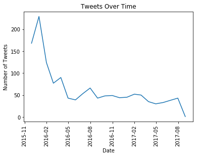

```python
#Plot tweets over time
import matplotlib.pyplot as plt
%matplotlib inline

plt.plot(month_tweets['timestamp'], month_tweets['tweet_id'])
plt.title('Tweets Over Time')
plt.xlabel('Date')
plt.ylabel('Number of Tweets')
plt.xticks(rotation='vertical');
```

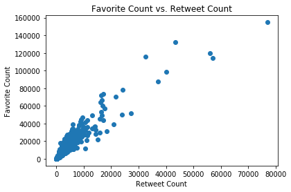

```python
#Scatter plot of favorites vs retweets
plt.scatter(x=twitter_dogs['retweet_count'], y=twitter_dogs['favorite_count'])
plt.title('Favorite Count vs. Retweet Count')
plt.xlabel('Retweet Count')
plt.ylabel('Favorite Count');
```

```python
#Filter the top breeds
top_breeds = twitter_dogs['dog_breed'].value_counts()[twitter_dogs['dog_breed'].value_counts()> 25]
top_breeds
```

```
Golden Retriever      135
Labrador Retriever     90
Pembroke               84
Chihuahua              77
Pug                    51
Chow                   38
Samoyed                37
Pomeranian             36
Toy Poodle             33
Malamute               28
Cocker Spaniel         26
Name: dog_breed, dtype: int64
```

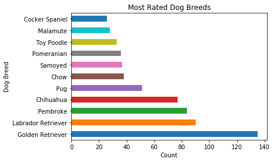

```python
#Create a histogram of most popular dog breeds
twitter_dogs['dog_breed'].value_counts()[twitter_dogs['dog_breed'].value_counts()> 25].plot(kind = 'barh');
plt.title('Most Rated Dog Breeds')
plt.xlabel('Count')
plt.ylabel('Dog Breed');
```

```python
twitter_dogs['name'].value_counts()
```

```
None          363
Cooper         10
Oliver          9
Charlie         9
Tucker          8
Lucy            7
Daisy           7
Sadie           7
Penny           7
Jax             6
Koda            6
Winston         6
Toby            5
Bo              5
Leo             5
Rusty           5
Stanley         5
Bella           5
Scout           4
Brody           4
Cassie          4
Bear            4
Sophie          4
Dexter          4
Lola            4
Dave            4
Scooter         4
Louis           4
Larry           4
George          4
             ...
Mairi           1
O               1
Corey           1
Heinrich        1
Furzey          1
Blue            1
Kaiya           1
Cilantro        1
Godzilla        1
Miguel          1
Sobe            1
Chelsea         1
Samsom          1
Sky             1
Christoper      1
Traviss         1
Rubio           1
Florence        1
Raphael         1
Eve             1
Arlen           1
Scott           1
Barney          1
Lucia           1
Kota            1
Fillup          1
Mojo            1
Strudel         1
Lulu            1
Holly           1
Name: name, Length: 742, dtype: int64
```

```python
#Filtered out the dogs that do not have names
non_null_names = twitter_dogs.query('name != "None"')
non_null_names
```

|  | tweet_id | timestamp | text | rating_numerator | rating_denominator | name | dog_type | jpg_url | p1 | p1_conf | p1_dog | p2 | p2_conf | p2_dog | p3 | p3_conf | p3_dog | favorite_count | retweet_count | dog_breed |
| --- | --- | --- | --- | --- | --- | --- | --- | --- | --- | --- | --- | --- | --- | --- | --- | --- | --- | --- | --- | --- |
| 1 | 892177421306343426 | 2017-08-01 00:17:27 | This is Tilly. She's just checking pup on you.... | 13.0 | 10.0 | Tilly | NaN | https://pbs.twimg.com/media/DGGmoV4XsAAUL6n.jpg | Chihuahua | 0.323581 | True | Pekinese | 0.090647 | True | Papillon | 0.068957 | True | 30968 | 5638 | Chihuahua |
| 2 | 891815181378084864 | 2017-07-31 00:18:03 | This is Archie. He is a rare Norwegian Pouncin... | 12.0 | 10.0 | Archie | NaN | https://pbs.twimg.com/media/DGBdLU1WsAANxJ9.jpg | Chihuahua | 0.716012 | True | Malamute | 0.078253 | True | Kelpie | 0.031379 | True | 23306 | 3730 | Chihuahua |
| 4 | 891327558926688256 | 2017-07-29 16:00:24 | This is Franklin. He would like you to stop ca... | 12.0 | 10.0 | Franklin | NaN | https://pbs.twimg.com/media/DF6hr6BUMAAzZgT.jpg | Basset | 0.555712 | True | English Springer | 0.225770 | True | German Short-Haired Pointer | 0.175219 | True | 37439 | 8385 | Basset |
| 6 | 890971913173991426 | 2017-07-28 16:27:12 | Meet Jax. He enjoys ice cream so much he gets ... | 13.0 | 10.0 | Jax | NaN | https://pbs.twimg.com/media/DF1eOmZXUAALUcq.jpg | Appenzeller | 0.341703 | True | Border Collie | 0.199287 | True | Ice Lolly | 0.193548 | False | 10954 | 1829 | Appenzeller |
| 8 | 890609185150312448 | 2017-07-27 16:25:51 | This is Zoey. She doesn't want to be one of th... | 13.0 | 10.0 | Zoey | NaN | https://pbs.twimg.com/media/DFwUU__XcAEpyXI.jpg | Irish Terrier | 0.487574 | True | Irish Setter | 0.193054 | True | Chesapeake Bay Retriever | 0.118184 | True | 25952 | 3872 | Irish Terrier |
| 9 | 890240255349198849 | 2017-07-26 15:59:51 | This is Cassie. She is a college pup. Studying... | 14.0 | 10.0 | Cassie | doggo | https://pbs.twimg.com/media/DFrEyVuW0AAO3t9.jpg | Pembroke | 0.511319 | True | Cardigan | 0.451038 | True | Chihuahua | 0.029248 | True | 29641 | 6619 | Pembroke |
| 10 | 890006608113172480 | 2017-07-26 00:31:25 | This is Koda. He is a South Australian decksha... | 13.0 | 10.0 | Koda | NaN | https://pbs.twimg.com/media/DFnwSY4WAAAMliS.jpg | Samoyed | 0.957979 | True | Pomeranian | 0.013884 | True | Chow | 0.008167 | True | 28540 | 6603 | Samoyed |
| 11 | 889880896479866881 | 2017-07-25 16:11:53 | This is Bruno. He is a service shark. Only get... | 13.0 | 10.0 | Bruno | NaN | https://pbs.twimg.com/media/DFl99B1WsAITKsg.jpg | French Bulldog | 0.377417 | True | Labrador Retriever | 0.151317 | True | Muzzle | 0.082981 | False | 25957 | 4492 | French Bulldog |
| 13 | 889638837579907072 | 2017-07-25 00:10:02 | This is Ted. He does his best. Sometimes that'... | 12.0 | 10.0 | Ted | NaN | https://pbs.twimg.com/media/DFihzFfXsAYGDPR.jpg | French Bulldog | 0.991650 | True | Boxer | 0.002129 | True | Staffordshire Bullterrier | 0.001498 | True | 25146 | 4042 | French Bulldog |
| 14 | 889531135344209921 | 2017-07-24 17:02:04 | This is Stuart. He's sporting his favorite fan... | 13.0 | 10.0 | Stuart | puppo | https://pbs.twimg.com/media/DFg_2PVW0AEHN3p.jpg | Golden Retriever | 0.953442 | True | Labrador Retriever | 0.013834 | True | Redbone | 0.007958 | True | 14092 | 2035 | Golden Retriever |
| 15 | 889278841981685760 | 2017-07-24 00:19:32 | This is Oliver. You're witnessing one of his m... | 13.0 | 10.0 | Oliver | NaN | https://pbs.twimg.com/ext_tw_video_thumb/88927... | Whippet | 0.626152 | True | Borzoi | 0.194742 | True | Saluki | 0.027351 | True | 23430 | 4812 | Whippet |
| 16 | 888917238123831296 | 2017-07-23 00:22:39 | This is Jim. He found a fren. Taught him how t... | 12.0 | 10.0 | Jim | NaN | https://pbs.twimg.com/media/DFYRgsOUQAARGhO.jpg | Golden Retriever | 0.714719 | True | Tibetan Mastiff | 0.120184 | True | Labrador Retriever | 0.105506 | True | 27076 | 4049 | Golden Retriever |
| 17 | 888804989199671297 | 2017-07-22 16:56:37 | This is Zeke. He has a new stick. Very proud o... | 13.0 | 10.0 | Zeke | NaN | https://pbs.twimg.com/media/DFWra-3VYAA2piG.jpg | Golden Retriever | 0.469760 | True | Labrador Retriever | 0.184172 | True | English Setter | 0.073482 | True | 23779 | 3818 | Golden Retriever |
| 18 | 888554962724278272 | 2017-07-22 00:23:06 | This is Ralphus. He's powering up. Attempting ... | 13.0 | 10.0 | Ralphus | NaN | https://pbs.twimg.com/media/DFTH_O-UQAACu20.jpg | Siberian Husky | 0.700377 | True | Eskimo Dog | 0.166511 | True | Malamute | 0.111411 | True | 18360 | 3130 | Siberian Husky |
| 19 | 888078434458587136 | 2017-07-20 16:49:33 | This is Gerald. He was just told he didn't get... | 12.0 | 10.0 | Gerald | NaN | https://pbs.twimg.com/media/DFMWn56WsAAkA7B.jpg | French Bulldog | 0.995026 | True | Pug | 0.000932 | True | Bull Mastiff | 0.000903 | True | 20267 | 3131 | French Bulldog |
| 20 | 887705289381826560 | 2017-07-19 16:06:48 | This is Jeffrey. He has a monopoly on the pool... | 13.0 | 10.0 | Jeffrey | NaN | https://pbs.twimg.com/media/DFHDQBbXgAEqY7t.jpg | Basset | 0.821664 | True | Redbone | 0.087582 | True | Weimaraner | 0.026236 | True | 28146 | 4871 | Basset |
| 21 | 887473957103951883 | 2017-07-19 00:47:34 | This is Canela. She attempted some fancy porch... | 13.0 | 10.0 | Canela | NaN | https://pbs.twimg.com/media/DFDw2tyUQAAAFke.jpg | Pembroke | 0.809197 | True | Rhodesian Ridgeback | 0.054950 | True | Beagle | 0.038915 | True | 63936 | 16237 | Pembroke |
| 24 | 886983233522544640 | 2017-07-17 16:17:36 | This is Maya. She's very shy. Rarely leaves he... | 13.0 | 10.0 | Maya | NaN | https://pbs.twimg.com/media/DE8yicJW0AAAvBJ.jpg | Chihuahua | 0.793469 | True | Toy Terrier | 0.143528 | True | Can Opener | 0.032253 | False | 32460 | 6915 | Chihuahua |
| 25 | 886736880519319552 | 2017-07-16 23:58:41 | This is Mingus. He's a wonderful father to his... | 13.0 | 10.0 | Mingus | NaN | https://pbs.twimg.com/media/DE5Se8FXcAAJFx4.jpg | Kuvasz | 0.309706 | True | Great Pyrenees | 0.186136 | True | Dandie Dinmont | 0.086346 | True | 11139 | 2893 | Kuvasz |
| 27 | 886366144734445568 | 2017-07-15 23:25:31 | This is Roscoe. Another pupper fallen victim t... | 12.0 | 10.0 | Roscoe | pupper | https://pbs.twimg.com/media/DE0BTnQUwAApKEH.jpg | French Bulldog | 0.999201 | True | Chihuahua | 0.000361 | True | Boston Bull | 0.000076 | True | 19662 | 2857 | French Bulldog |
| 28 | 886258384151887873 | 2017-07-15 16:17:19 | This is Waffles. His doggles are pupside down.... | 13.0 | 10.0 | Waffles | NaN | https://pbs.twimg.com/media/DEyfTG4UMAE4aE9.jpg | Pug | 0.943575 | True | Shower Cap | 0.025286 | False | Siamese Cat | 0.002849 | False | 26037 | 5700 | Pug |
| 29 | 885984800019947520 | 2017-07-14 22:10:11 | Viewer discretion advised. This is Jimbo. He w... | 12.0 | 10.0 | Jimbo | NaN | https://pbs.twimg.com/media/DEumeWWV0AA-Z61.jpg | Blenheim Spaniel | 0.972494 | True | Shih-Tzu | 0.006630 | True | Bernese Mountain Dog | 0.006239 | True | 30320 | 6064 | Blenheim Spaniel |
| 30 | 885528943205470208 | 2017-07-13 15:58:47 | This is Maisey. She fell asleep mid-excavation... | 13.0 | 10.0 | Maisey | NaN | https://pbs.twimg.com/media/DEoH3yvXgAAzQtS.jpg | Pug | 0.369275 | True | Labrador Retriever | 0.265835 | True | Kuvasz | 0.134697 | True | 33434 | 5766 | Pug |
| 32 | 884925521741709313 | 2017-07-12 00:01:00 | This is Earl. He found a hat. Nervous about wh... | 12.0 | 10.0 | Earl | NaN | https://pbs.twimg.com/media/DEfjEaNXkAAtPlj.jpg | Italian Greyhound | 0.259916 | True | American Staffordshire Terrier | 0.198451 | True | Staffordshire Bullterrier | 0.127725 | True | 71664 | 16302 | Italian Greyhound |
| 33 | 884876753390489601 | 2017-07-11 20:47:12 | This is Lola. It's her first time outside. Mus... | 13.0 | 10.0 | Lola | NaN | https://pbs.twimg.com/media/DEe2tZXXkAAwyX3.jpg | Chow | 0.822103 | True | Norwich Terrier | 0.106075 | True | Norfolk Terrier | 0.037348 | True | 25881 | 5032 | Chow |
| 34 | 884562892145688576 | 2017-07-11 00:00:02 | This is Kevin. He's just so happy. 13/10 what ... | 13.0 | 10.0 | Kevin | NaN | https://pbs.twimg.com/media/DEaZQkfXUAEC7qB.jpg | Pug | 0.546406 | True | French Bulldog | 0.404291 | True | Brabancon Griffon | 0.044002 | True | 22612 | 4243 | Pug |
| 36 | 884162670584377345 | 2017-07-09 21:29:42 | Meet Yogi. He doesn't have any important dog m... | 12.0 | 10.0 | Yogi | doggo | https://pbs.twimg.com/media/DEUtQbzW0AUTv_o.jpg | German Shepherd | 0.707046 | True | Malinois | 0.199396 | True | Norwegian Elkhound | 0.049148 | True | 18983 | 2702 | German Shepherd |
| 37 | 883838122936631299 | 2017-07-09 00:00:04 | This is Noah. He can't believe someone made th... | 12.0 | 10.0 | Noah | NaN | https://pbs.twimg.com/media/DEQGFgAXUAAEvfi.jpg | Doberman | 0.610946 | True | Miniature Pinscher | 0.299603 | True | Kelpie | 0.063020 | True | 20339 | 3095 | Doberman |
| 38 | 883482846933004288 | 2017-07-08 00:28:19 | This is Bella. She hopes her smile made you sm... | 5.0 | 10.0 | Bella | NaN | https://pbs.twimg.com/media/DELC9dZXUAADqUk.jpg | Golden Retriever | 0.943082 | True | Labrador Retriever | 0.032409 | True | Kuvasz | 0.005501 | True | 42621 | 8914 | Golden Retriever |
| 39 | 883360690899218434 | 2017-07-07 16:22:55 | Meet Grizzwald. He may be the floofiest floofe... | 13.0 | 10.0 | Grizzwald | floofer | https://pbs.twimg.com/media/DEJT3FeXoAAtwUy.jpg | Chow | 0.987997 | True | Tibetan Mastiff | 0.007099 | True | Newfoundland | 0.002140 | True | 21104 | 3336 | Chow |
| ... | ... | ... | ... | ... | ... | ... | ... | ... | ... | ... | ... | ... | ... | ... | ... | ... | ... | ... | ... | ... |
| 1817 | 667544320556335104 | 2015-11-20 03:25:43 | This is Kial. Kial is either wearing a cape, w... | 10.0 | 10.0 | Kial | NaN | https://pbs.twimg.com/media/CUOYBbbWIAAXQGU.jpg | Pomeranian | 0.412893 | True | Pembroke | 0.312958 | True | Chihuahua | 0.071960 | True | 816 | 493 | Pomeranian |
| 1818 | 667534815156183040 | 2015-11-20 02:47:56 | This is Frank (pronounced "Fronq"). Too many b... | 8.0 | 10.0 | Frank | NaN | https://pbs.twimg.com/media/CUOPYI5UcAAj_nO.jpg | Pembroke | 0.435254 | True | Cardigan | 0.307407 | True | Cocker Spaniel | 0.033158 | True | 778 | 494 | Pembroke |
| 1819 | 667530908589760512 | 2015-11-20 02:32:25 | Meet Naphaniel. He doesn't necessarily enjoy h... | 10.0 | 10.0 | Naphaniel | NaN | https://pbs.twimg.com/media/CUOL0uGUkAAx7yh.jpg | Golden Retriever | 0.633037 | True | Kuvasz | 0.146391 | True | Labrador Retriever | 0.046184 | True | 443 | 224 | Golden Retriever |
| 1821 | 667517642048163840 | 2015-11-20 01:39:42 | This is Dook &amp; Milo. Dook is struggling to... | 8.0 | 10.0 | Dook | NaN | https://pbs.twimg.com/media/CUN_wiBUkAAakT0.jpg | Italian Greyhound | 0.125176 | True | Standard Poodle | 0.084572 | True | Cocker Spaniel | 0.081347 | True | 350 | 180 | Italian Greyhound |
| 1823 | 667502640335572993 | 2015-11-20 00:40:05 | Say hello to Hall and Oates. Oates is winking ... | 11.0 | 10.0 | Hall | NaN | https://pbs.twimg.com/media/CUNyHTMUYAAQVch.jpg | Labrador Retriever | 0.996709 | True | Golden Retriever | 0.001688 | True | Beagle | 0.000712 | True | 514 | 210 | Labrador Retriever |
| 1824 | 667495797102141441 | 2015-11-20 00:12:54 | This is Philippe from Soviet Russia. Commandin... | 9.0 | 10.0 | Philippe | NaN | https://pbs.twimg.com/media/CUNr4-7UwAAg2lq.jpg | Chihuahua | 0.143957 | True | Christmas Stocking | 0.118651 | False | Ski Mask | 0.092482 | False | 496 | 249 | Chihuahua |
| 1826 | 667455448082227200 | 2015-11-19 21:32:34 | This is Reese and Twips. Reese protects Twips.... | 7.0 | 10.0 | Reese | NaN | https://pbs.twimg.com/media/CUNHMXTU8AAS3HH.jpg | Tibetan Terrier | 0.676376 | True | Irish Terrier | 0.054933 | True | Yorkshire Terrier | 0.040576 | True | 181 | 56 | Tibetan Terrier |
| 1827 | 667453023279554560 | 2015-11-19 21:22:56 | Meet Cupcake. I would do unspeakable things fo... | 11.0 | 10.0 | Cupcake | NaN | https://pbs.twimg.com/media/CUNE_OSUwAAdHhX.jpg | Labrador Retriever | 0.825670 | True | French Bulldog | 0.056639 | True | Staffordshire Bullterrier | 0.054018 | True | 297 | 84 | Labrador Retriever |
| 1831 | 667405339315146752 | 2015-11-19 18:13:27 | This is Biden. Biden just tripped... 7/10 http... | 7.0 | 10.0 | Biden | NaN | https://pbs.twimg.com/media/CUMZnmhUEAEbtis.jpg | Saint Bernard | 0.381377 | True | Leonberg | 0.127998 | True | Golden Retriever | 0.069357 | True | 446 | 211 | Saint Bernard |
| 1832 | 667393430834667520 | 2015-11-19 17:26:08 | This is Fwed. He is a Canadian Asian Taylormad... | 8.0 | 10.0 | Fwed | NaN | https://pbs.twimg.com/media/CUMOyd3XIAAl13H.jpg | Papillon | 0.557009 | True | Border Collie | 0.271963 | True | Collie | 0.073473 | True | 184 | 52 | Papillon |
| 1834 | 667211855547486208 | 2015-11-19 05:24:37 | This is Genevieve. She is a golden retriever c... | 9.0 | 10.0 | Genevieve | NaN | https://pbs.twimg.com/media/CUJppKJWoAA75NP.jpg | Golden Retriever | 0.462556 | True | Labrador Retriever | 0.454937 | True | Kuvasz | 0.024193 | True | 463 | 224 | Golden Retriever |
| 1835 | 667200525029539841 | 2015-11-19 04:39:35 | This is Joshwa. He is a fuckboy supreme. He cl... | 11.0 | 10.0 | Joshwa | NaN | https://pbs.twimg.com/media/CUJfVMPXIAAgbue.jpg | Siberian Husky | 0.694904 | True | Malamute | 0.232006 | True | Eskimo Dog | 0.050635 | True | 584 | 245 | Siberian Husky |
| 1838 | 667182792070062081 | 2015-11-19 03:29:07 | This is Timison. He just told an awful joke bu... | 10.0 | 10.0 | Timison | NaN | https://pbs.twimg.com/media/CUJPNjOWsAAZRqP.jpg | Golden Retriever | 0.949892 | True | Irish Setter | 0.010564 | True | Chesapeake Bay Retriever | 0.005821 | True | 13543 | 5773 | Golden Retriever |
| 1840 | 667174963120574464 | 2015-11-19 02:58:01 | This is Clarence. His face says he doesn't wan... | 9.0 | 10.0 | Clarence | NaN | https://pbs.twimg.com/media/CUJIFoJWsAAL3Dc.jpg | Toy Poodle | 0.266437 | True | Chihuahua | 0.243223 | True | Bluetick | 0.072806 | True | 234 | 72 | Toy Poodle |
| 1841 | 667171260800061440 | 2015-11-19 02:43:18 | Say hello to Kenneth. He likes Reese's Puffs. ... | 10.0 | 10.0 | Kenneth | NaN | https://pbs.twimg.com/media/CUJEuRIXIAAPDLt.jpg | Giant Schnauzer | 0.841265 | True | Lakeland Terrier | 0.052744 | True | Irish Water Spaniel | 0.034402 | True | 210 | 77 | Giant Schnauzer |
| 1842 | 667165590075940865 | 2015-11-19 02:20:46 | This is Churlie. AKA Fetty Woof. Lost eye savi... | 10.0 | 10.0 | Churlie | NaN | https://pbs.twimg.com/media/CUI_kHBWsAAAef5.jpg | Miniature Pinscher | 0.140173 | True | Rottweiler | 0.134094 | True | Beagle | 0.081900 | True | 2547 | 1052 | Miniature Pinscher |
| 1843 | 667160273090932737 | 2015-11-19 01:59:39 | This is Bradlay. He is a Ronaldinho Matsuyama ... | 11.0 | 10.0 | Bradlay | NaN | https://pbs.twimg.com/media/CUI6uuaW4AAvCIs.jpg | Golden Retriever | 0.471351 | True | Miniature Poodle | 0.091992 | True | Standard Poodle | 0.087385 | True | 243 | 59 | Golden Retriever |
| 1844 | 667152164079423490 | 2015-11-19 01:27:25 | This is Pipsy. He is a fluffball. Enjoys trave... | 12.0 | 10.0 | Pipsy | NaN | https://pbs.twimg.com/media/CUIzWk_UwAAfUNq.jpg | Toy Poodle | 0.535411 | True | Pomeranian | 0.087544 | True | Miniature Poodle | 0.062050 | True | 45184 | 15854 | Toy Poodle |
| 1846 | 667119796878725120 | 2015-11-18 23:18:48 | This is Gabe. He is a southern Baklava. Gabe h... | 10.0 | 10.0 | Gabe | NaN | https://pbs.twimg.com/media/CUIV6F7XIAA1tAM.jpg | Pembroke | 0.741563 | True | Chihuahua | 0.057866 | True | Toy Poodle | 0.039125 | True | 315 | 122 | Pembroke |
| 1847 | 667090893657276420 | 2015-11-18 21:23:57 | This is Clybe. He is an Anemone Valdez. One ea... | 7.0 | 10.0 | Clybe | NaN | https://pbs.twimg.com/media/CUH7oLuUsAELWib.jpg | Chihuahua | 0.959514 | True | Italian Greyhound | 0.005370 | True | Pomeranian | 0.002641 | True | 317 | 117 | Chihuahua |
| 1848 | 667073648344346624 | 2015-11-18 20:15:26 | Here is Dave. He is actually just a skinny leg... | 10.0 | 10.0 | Dave | NaN | https://pbs.twimg.com/media/CUHr8WbWEAEBPgf.jpg | Chihuahua | 0.483682 | True | Pug | 0.092494 | True | Brabancon Griffon | 0.057495 | True | 379 | 111 | Chihuahua |
| 1850 | 667062181243039745 | 2015-11-18 19:29:52 | This is Keet. He is a Floridian Amukamara. Abs... | 10.0 | 10.0 | Keet | NaN | https://pbs.twimg.com/media/CUHhgvHUAAA4aB0.jpg | Chesapeake Bay Retriever | 0.825678 | True | Vizsla | 0.090998 | True | Kelpie | 0.022956 | True | 209 | 49 | Chesapeake Bay Retriever |
| 1857 | 666817836334096384 | 2015-11-18 03:18:55 | This is Jeph. He is a German Boston Shuttlecoc... | 9.0 | 10.0 | Jeph | NaN | https://pbs.twimg.com/media/CUEDSMEWEAAuXVZ.jpg | Miniature Schnauzer | 0.496953 | True | Standard Schnauzer | 0.285276 | True | Giant Schnauzer | 0.073764 | True | 484 | 235 | Miniature Schnauzer |
| 1858 | 666804364988780544 | 2015-11-18 02:25:23 | This is Jockson. He is a Pinnacle Sagittarius.... | 8.0 | 10.0 | Jockson | NaN | https://pbs.twimg.com/media/CUD3A7YWoAA82N0.jpg | English Setter | 0.328792 | True | Brittany Spaniel | 0.283545 | True | Ibizan Hound | 0.057461 | True | 219 | 84 | English Setter |
| 1861 | 666739327293083650 | 2015-11-17 22:06:57 | This is Lugan. He is a Bohemian Rhapsody. Very... | 10.0 | 10.0 | Lugan | NaN | https://pbs.twimg.com/media/CUC74aTWoAInZey.jpg | Miniature Poodle | 0.546933 | True | Cocker Spaniel | 0.165255 | True | Toy Poodle | 0.095959 | True | 222 | 60 | Miniature Poodle |
| 1862 | 666691418707132416 | 2015-11-17 18:56:35 | This is Christoper. He is a spotted Penne. Can... | 8.0 | 10.0 | Christoper | NaN | https://pbs.twimg.com/media/CUCQTpEWEAA7EDz.jpg | German Shepherd | 0.975401 | True | Beagle | 0.008687 | True | Bloodhound | 0.005394 | True | 175 | 45 | German Shepherd |
| 1864 | 666644823164719104 | 2015-11-17 15:51:26 | This is Jimothy. He is a Botwanian Gouda. Can ... | 9.0 | 10.0 | Jimothy | NaN | https://pbs.twimg.com/media/CUBl6IwVAAA9_zT.jpg | Ibizan Hound | 0.044333 | True | Pembroke | 0.043209 | True | West Highland White Terrier | 0.038906 | True | 220 | 75 | Ibizan Hound |
| 1865 | 666454714377183233 | 2015-11-17 03:16:00 | I'll name the dogs from now on. This is Kreggo... | 10.0 | 10.0 | Kreggory | NaN | https://pbs.twimg.com/media/CT-5Bs-WUAA2JeC.jpg | Dalmatian | 0.278954 | True | Labrador Retriever | 0.237612 | True | Great Pyrenees | 0.171106 | True | 485 | 199 | Dalmatian |
| 1866 | 666447344410484738 | 2015-11-17 02:46:43 | This is Scout. She is a black Downton Abbey. I... | 9.0 | 10.0 | Scout | NaN | https://pbs.twimg.com/media/CT-yU5QWwAEjLX5.jpg | Curly-Coated Retriever | 0.322084 | True | Giant Schnauzer | 0.287955 | True | Labrador Retriever | 0.166331 | True | 98 | 18 | Curly-Coated Retriever |
| 1872 | 666418789513326592 | 2015-11-17 00:53:15 | This is Walter. He is an Alaskan Terrapin. Lov... | 10.0 | 10.0 | Walter | NaN | https://pbs.twimg.com/media/CT-YWb7U8AA7QnN.jpg | Toy Terrier | 0.149680 | True | Papillon | 0.148258 | True | Chihuahua | 0.142860 | True | 113 | 41 | Toy Terrier |

1037 rows × 20 columns

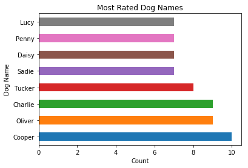

```python
#Analyze the top names
non_null_names['name'].value_counts()[non_null_names['name'].value_counts()> 6].plot(kind = 'barh');
plt.title('Most Rated Dog Names')
plt.xlabel('Count')
plt.ylabel('Dog Name');
```

```python
#Filter the breeds that have been retweeted the most
retweeted_breeds = twitter_dogs.groupby('dog_breed')['retweet_count'].sum().reset_index()
retweeted_breeds = retweeted_breeds.sort_values('retweet_count', ascending=False).head(7)
retweeted_breeds
```

|  | dog_breed | retweet_count |
| --- | --- | --- |
| 44 | Golden Retriever | 435596 |
| 60 | Labrador Retriever | 304299 |
| 78 | Pembroke | 236185 |
| 26 | Chihuahua | 197493 |
| 86 | Samoyed | 137951 |
| 40 | French Bulldog | 105993 |
| 27 | Chow | 101506 |

```python
#Creating variables for each breed
Golden_Retriever = retweeted_breeds.iloc[0, 1]
Labrador_Retriever = retweeted_breeds.iloc[1, 1]
Pembroke = retweeted_breeds.iloc[2, 1]
Chihuahua = retweeted_breeds.iloc[3, 1]
Samoyed = retweeted_breeds.iloc[4, 1]
French_Bulldog = retweeted_breeds.iloc[5, 1]
Chow = retweeted_breeds.iloc[6, 1]
```

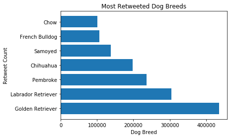

```python
#Plotting the breeds that have most retweets
locations = [1, 2, 3, 4, 5, 6, 7]
heights = [Golden_Retriever, Labrador_Retriever, Pembroke, Chihuahua, Samoyed, French_Bulldog, Chow]
labels = ['Golden Retriever', 'Labrador Retriever', 'Pembroke', 'Chihuahua', 'Samoyed', 'French Bulldog', 'Chow']
plt.barh(locations, heights, tick_label=labels)
plt.title('Most Retweeted Dog Breeds')
plt.xlabel('Dog Breed')
plt.ylabel('Retweet Count');
```